# rebuttal_analysis

Khyati

February 19, 2025

# Introduction

Here, we want to investigate, upon PWM scanning based on the PWM representation of the TF-MoDISco seqlets, whether our CWM scanning approach returns high-quality motifs. We also want to check whether the PWM-scanned false positive motifs are all poor matches (i.e. is PWM scanning totally fine at high affinities?) and whether our hit mapping thresholds appropriately find sequences of high contribution.

Other analysis that went into rebuttal plan are also incuded.

# Computational Setup

```r
#Standard packages
library(rtracklayer) ; library(GenomicRanges); library(magrittr) ; library(Biostrings)
library(ggplot2) ; library(reshape2); library(plyranges); library(Rsamtools); library(parallel)
library(dplyr); library(data.table); library(patchwork); library(readr); library(testit)

#KNITR Options
setwd("/n/projects/kd2200/publication/rebuttal/")
figure_filepath<-"figures/final/"
options(knitr.figure_dir=figure_filepath, java.parameters = "- Xmx6g")

#Lab sources
source("/n/projects/kd2200/publication/bpnet/analysis/scripts/granges_common.r")
source("/n/projects/kd2200/publication/bpnet/analysis/scripts/metapeak_common.r")
source("/n/projects/kd2200/publication/bpnet/analysis/scripts/knitr_common.r")
source("/n/projects/kd2200/publication/bpnet/analysis/scripts/caching.r")
source("/n/projects/kd2200/publication/bpnet/analysis/scripts/metapeak_functions.R")
source("/n/projects/kd2200/publication/bpnet/analysis/scripts/metapeak_new.r")
source("/n/projects/kd2200/publication/bpnet/analysis/scripts/motif_functions.R")
source("/n/projects/kd2200/publication/bpnet/analysis/scripts/bpnet/motif_functions.r")
source("/n/projects/kd2200/publication/bpnet/analysis/scripts/1.motif_summary/tsc_variables.R")

#Specific sources
library(BSgenome.Mmusculus.UCSC.mm10)
library(TxDb.Mmusculus.UCSC.mm10.knownGene)
library(org.Mm.eg.db)
library(ggseqlogo)

#Pre-existing variables
threads <- 5
dir.create('memesuite/seqs/seqlets', recursive = T, showWarnings = F)
dir.create('rdata', recursive = T, showWarnings = F)
bsgenome<-BSgenome.Mmusculus.UCSC.mm10
txdb<-TxDb.Mmusculus.UCSC.mm10.knownGene

meme.path<-'/n/projects/kd2200/publication/rebuttal/mtsc_tead4_macs2_peaks_nexus_top1000_101bpwidth/meme.txt'
regions.path<-'/n/projects/kd2200/publication/bpnet/analysis/bed/curated_island_regoion_tsc_model_motifs_fold5_0based.bed'
motifs.path<-'/n/projects/kd2200/publication/bpnet/analysis/tsv/curated_motif_regoion_tsc_model_motifs_fold5_1based.tsv.gz'
peaks.path.list <- '/n/projects/kd2200/publication/bpnet/bed/mtsc_cttyg_combine_idr_peaks.bed'
output_length <- 1000

meme_patterns.list<-list('MEME-1' = 'tead4', 'MEME-3' = 'tead4_double')
modisco_patterns.list<-list('tead4_0' = 'tead4', 'tead4_double_1' = 'tead4_double')
modisco_patterns_inverse.list<-list('tead4' = 'tead4_0', 'tead4_double' = 'tead4_double_1')

seqlet_patterns.list<-list('tead4' = '/n/projects/kd2200/publication/bpnet/modisco/profile/dataspec.yaml_default_fold_5/tead4/seqlets/metacluster_0/pattern_0.bed.gz',
                           'tead4_double' = '/n/projects/kd2200/publication/bpnet/modisco/profile/dataspec.yaml_default_fold_5/tead4/seqlets/metacluster_0/pattern_1.bed.gz')
```

# Import motifs

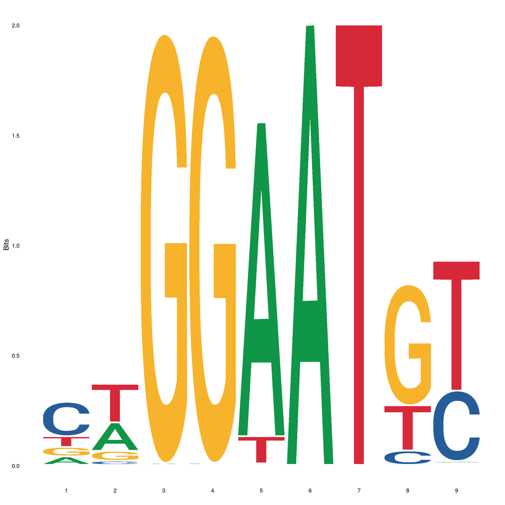

```r
# meme:
#ml meme/5.3.0

peaks.gr <- import.bed("/n/projects/kd2200/publication/bpnet_prep/macs2/combined/mtsc_tead4_nexus_summits.bed")

peaks.gr<-peaks.gr[order(peaks.gr$score, decreasing = TRUE)][1:1000]

 write_fasta <- function(regions, size_extension, output_filepath, genome=BSgenome.Mmusculus.UCSC.mm10){
   sequence <- getSeq(genome, resize(regions, size_extension, "center"))
   names(sequence) <- paste0(output_filepath, "_peak", 1:length(sequence))
   writeXStringSet(sequence, output_filepath)
 }
write_fasta(regions=peaks.gr, size_extension=101, output_filepath="/n/projects/kd2200/publication/rebuttal/mtsc_tead4_macs2_peaks_nexus_top1000_101bpwidth.fasta")

#motifs_all.gr<-readr::read_tsv(motifs.path) %>%
# makeGRangesFromDataFrame(keep.extra.columns = T, starts.in.df.are.0based = T) #for some reason motifs are mislabeled as 1based.
#motifs_all.gr$pattern_name %>% table

#regions.gr<-GRanges(seqnames(motifs_all.gr), IRanges(motifs_all.gr$pattern_start + motifs_all.gr$example_start, motifs_all.gr$pattern_end + motifs_all.gr$example_end), strand = '*') %>%
#  plyranges::mutate(start = start + 100, end = end - 100) %>%
#  reduce(., ignore.strand = T)

# cwm motifs
tead4_double.df <- read_tsv("/n/projects/kd2200/publication/bpnet/cwm_all_regions/tead4/instances_by_pattern/m0_p1_motif-instances-all-regions.tsv.gz")
tead4_double.gr <- tead4_double.df %>% makeGRangesFromDataFrame(seqnames.field = "example_chrom",start.field = "pattern_start_abs", end.field = "pattern_end_abs",keep.extra.columns = T, starts.in.df.are.0based = T)
tead4_double.gr <- unique(tead4_double.gr)

tead4.df <- read_tsv("/n/projects/kd2200/publication/bpnet/cwm_all_regions/tead4/instances_by_pattern/m0_p0_motif-instances-all-regions.tsv.gz")
tead4.gr <- tead4.df %>% makeGRangesFromDataFrame(seqnames.field = "example_chrom",start.field = "pattern_start_abs", end.field = "pattern_end_abs",keep.extra.columns = T, starts.in.df.are.0based = T)
tead4.gr <- unique(tead4.gr)

#erv
rm <- readRDS("/n/projects/mw2098/genomes/mm10/repeatmasker.mm10.gr.rds")
erv <- rm[grep("ERV", rm$repeat_class)]

tead4_double_noerv.gr <- tead4_double.gr[which(!overlapsAny(tead4_double.gr, erv, ignore.strand=T))]
tead4_noerv.gr <- tead4.gr[which(!overlapsAny(tead4.gr, erv, ignore.strand=T))]

# remove palindormic
tead4_double_noerv.gr$pattern_name <- "tead4_double"
tead4_double_noerv.gr <- remove_palindromic_motifs_from_bpnet_instances(tead4_double_noerv.gr , pattern_to_filter="tead4_double")

tead4_noerv.gr$pattern_name <- "tead4"
tead4_noerv.gr <- remove_palindromic_motifs_from_bpnet_instances(tead4_noerv.gr , pattern_to_filter="tead4")

#getseq
tead4_noerv.gr$dna <- getSeq(BSgenome.Mmusculus.UCSC.mm10,  tead4_noerv.gr)
tead4_double_noerv.gr$dna <- getSeq(BSgenome.Mmusculus.UCSC.mm10,tead4_double_noerv.gr)

ggplot() + geom_logo(as.data.frame(tead4_noerv.gr$dna)) + theme_logo()
```

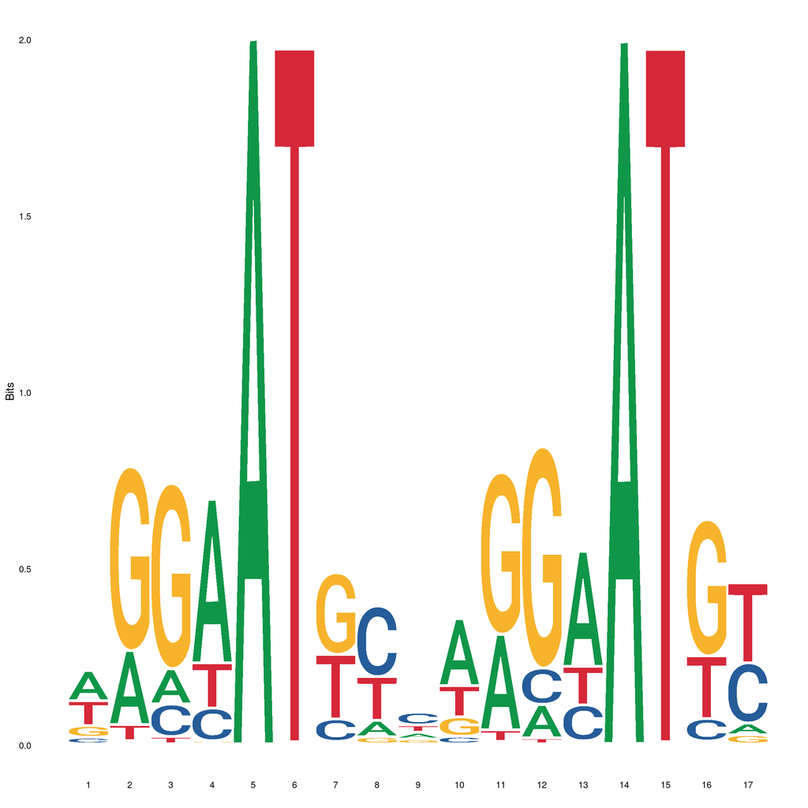

```r
ggplot() + geom_logo(as.data.frame(tead4_double_noerv.gr$dna)) + theme_logo()
```

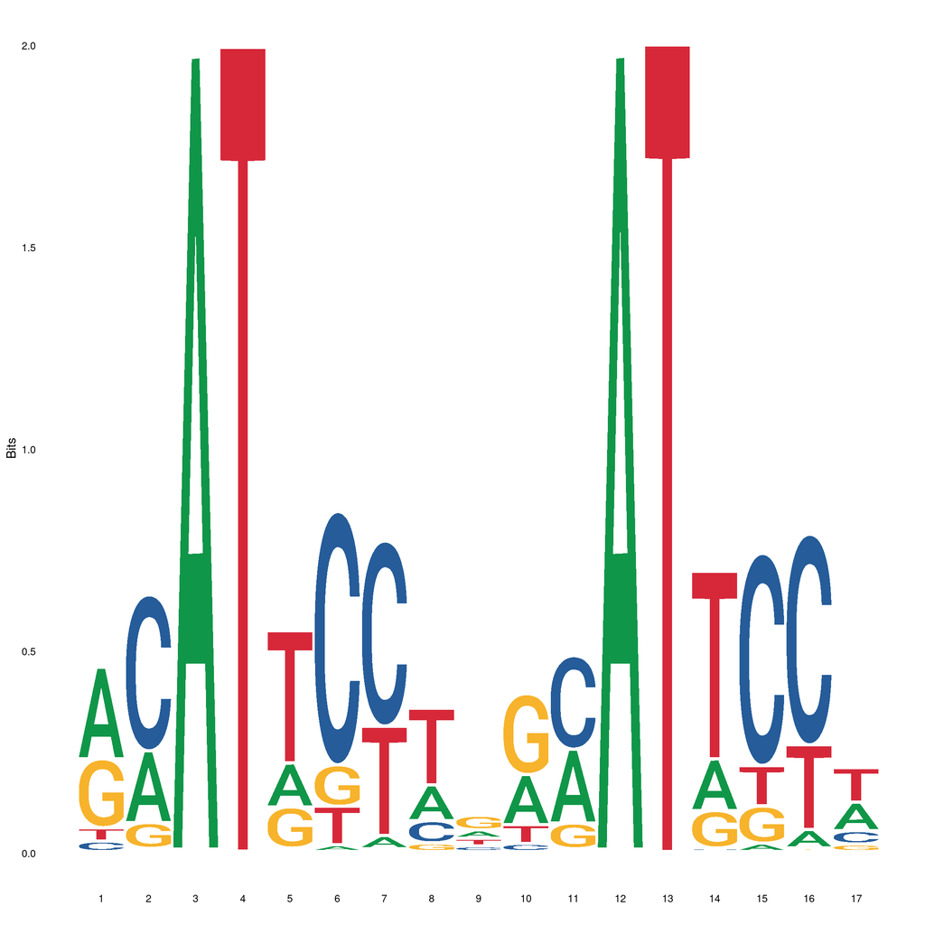

```r
#rev complement
test <- tead4_double_noerv.gr$dna
test2 <- Biostrings::reverseComplement(test)
test2 <- as.data.frame(test2)
tead4_double_noerv.gr$dna2 <- test2$x
ggplot() + geom_logo(as.data.frame(tead4_double_noerv.gr$dna2)) + theme_logo()
```

```r
motifs_tead4s_noervs.gr <- c(tead4_noerv.gr,  tead4_double_noerv.gr)


readr::write_tsv(as.data.frame(tead4_noerv.gr), 'analysis/tsv/new_tead4_noerv.tsv.gz')
readr::write_tsv(as.data.frame(tead4_double_noerv.gr), 'analysis/tsv/new_tead4_double_noerv.tsv.gz')
```

```r
# peak regions
peaks.gr<-lapply(peaks.path.list, function(x) rtracklayer::import(x)) %>% as('GRangesList') %>% unlist() %>% reduce(., ignore.strand = T)
peaks.gr$peak_id <- 1:length(peaks.gr)
peaks.gr<- peaks.gr[seqnames(peaks.gr) != "chrM"] #108404


motifs_all.gr<-readr::read_tsv(motifs.path) %>%
  makeGRangesFromDataFrame(keep.extra.columns = T, starts.in.df.are.0based = T) #for some reason motifs are mislabeled as 1based.
motifs_all.gr$pattern_name %>% table
```

```
## .
##         cdx2_0           ctcf           elf5        gata3_1        gata3_4
##          27367           7031           8310           2665           5926
##        gata3_5        jun_fos        tead4_0 tead4_double_1       tfap2c_0
##           1591          17727          35329           5660          71908
##       tfap2c_1         yap1_0         yap1_1
##          77434          13940           1519
```

```r
regions.gr<-GRanges(seqnames(motifs_all.gr), IRanges(motifs_all.gr$pattern_start + motifs_all.gr$example_start, motifs_all.gr$pattern_end + motifs_all.gr$example_end), strand = '*') %>%
  plyranges::mutate(start = start + 100, end = end - 100) %>%
  GenomicRanges::reduce(., ignore.strand = T)


peak_motif_ov <- findOverlaps(regions.gr,peaks.gr, ignore.strand=T)
regions_new.gr <- regions.gr[peak_motif_ov@from]
regions_new.gr <- unique(regions_new.gr)#88016
```

# Extract seqlet PWM to MEME format

## Extract seqlet logos

Define TF mapped motifs

```r
tf_seqlet_ids.df<-data.frame(
      pattern_name = c('pattern_0', 'pattern_1'),
      motif = unlist(modisco_patterns.list),
      oriented_strand = c('+', '+'),
      task = c('tead4', 'tead4')
)
```

# Run FIMO on .fa sequences

Export all regions to .fa file

```r
#regions.seq<-getSeq(bsgenome, regions.gr)
#names(regions.seq)<-paste0(seqnames(regions.gr), ':', start(regions.gr), '-', end(regions.gr)) #FIMO works with 1-based coords
#writeXStringSet(regions.seq, 'analysis/memesuite/all_idr_peaks_seqs.fa')


regions_new.seq<-getSeq(bsgenome, regions_new.gr)
names(regions_new.seq)<-paste0(seqnames(regions_new.gr), ':', start(regions_new.gr), '-', end(regions_new.gr)) #FIMO works with 1-based coords
writeXStringSet(regions_new.seq, 'analysis/memesuite/all_peaks_motifs_ov_seqs.fa')
```

Get IC logo.

```r
# ic.list<-lapply(tf_seqlet_ids.df$motif, function(x){
#     gr<-rtracklayer::import(seqlet_patterns.list[[x]])
#     seqs<-getSeq(bsgenome, gr, as.character = T)
#     seq_ic<-ppm_to_ic(seq_to_ppm(seqs),  bg_freq = c(.3, .2, .2, .3))
#     readr::write_lines(seqs, file = paste0('analysis/memesuite/seqlets/', x, '.txt'))
#     return(seq_ic)
# })
# names(ic.list)<-tf_seqlet_ids.df$motif


#Get IC content for cwm
ic.list<-lapply(names(seqlet_patterns.list), function(x){
  seqs<-rtracklayer::import(seqlet_patterns.list[[x]]) %>%
    getSeq(bsgenome, ., as.character = T)
  seq_ic<-ppm_to_ic(seq_to_ppm(seqs),  bg_freq = c(.3, .2, .2, .3))
  readr::write_lines(seqs, file = paste0('analysis/memesuite/seqs/', x, '.txt'))
  return(seq_ic)
})
names(ic.list)<-names(seqlet_patterns.list)
```

## take marg score and populate coreesponsding sequences that many times

```r
tead4_double_no_ervs_marg <- read_csv("/n/projects/kd2200/publication/rebuttal/heatmap/new_tead4_double_noervs_preds_summary_allseq_v2.csv")
tead4_no_ervs_marg <- read_csv("/n/projects/kd2200/publication/rebuttal/heatmap/new_tead4_noervs_preds_summary_allseq_v2.csv")

#sort by marg score of tead4
tead4_double_no_ervs_marg <- tead4_double_no_ervs_marg[order(tead4_double_no_ervs_marg$tead4,decreasing = T), ]
tead4_no_ervs_marg <- tead4_no_ervs_marg[order(tead4_no_ervs_marg$tead4,decreasing = T), ]

populate_MS_sequences <- function(motifs, scores) {
  # Initialize an empty list to store the sequences
  sequences <- c()

  # Loop through each motif and score
  for (i in seq_along(motifs)) {
    score <- as.integer(scores[i])  # Convert the score to integer

    # Repeat the motif based on the score and append to sequences
    sequences <- c(sequences, rep(motifs[i], score))
  }

  return(sequences)
}

tead4_double_no_ervs_marg_seqs <- populate_MS_sequences(tead4_double_no_ervs_marg$sequence, tead4_double_no_ervs_marg$tead4)
tead4_no_ervs_marg_seqs <- populate_MS_sequences(tead4_no_ervs_marg$sequence, tead4_no_ervs_marg$tead4)

readr::write_lines(tead4_double_no_ervs_marg_seqs,'analysis/memesuite/seqlets/marg_tead4double/tead4_double_no_ervs_marg_seqs.txt')

readr::write_lines(tead4_no_ervs_marg_seqs,'analysis/memesuite/seqlets/marg_tead4single/tead4_no_ervs_marg_seqs.txt')
```

## Convert sequences to MEME format

Note: analysis/memesuite/seqlets has to the directory of the seqlets txt file.

```bash
ml meme/5.5.3
sites2meme rebuttal/analysis/memesuite/seqlets > rebuttal/analysis/memesuite/custom_meme.txt

sites2meme ./rebuttal/analysis/memesuite/seqlets/marg_tead4double > ./rebuttal/analysis/memesuite/seqlets/marg_tead4double/tead4_double_no_ervs_marg_seqs_custom.txt

sites2meme ./rebuttal/analysis/memesuite/seqlets/marg_tead4single > ./rebuttal/analysis/memesuite/seqlets/marg_tead4single/tead4_no_ervs_marg_seqs_custom.txt
```

##Run FIMO on default significance settings ## run below command on command line. therefore commented out

```bash
cmds_all.vec<-c('#!bin/bash', 'module load meme',
               paste0('fimo --oc memesuite --skip-matched-sequence --parse-genomic-coord --max-strand --max-stored-scores 10000000 ', meme.path, ' ./analysis/memesuite/all_idr_peaks_seqs.fa > ./rebuttal/analysis/memesuite/fimo_matches_default_settings.tsv'))
writeLines(cmds_all.vec, 'analysis/scan_pwms_using_fimo_defaults.sh')

#run following command on command line
bash ./rebuttal/analysis/scan_pwms_using_fimo_defaults.sh



cmds_all.vec<-c('#!bin/bash', 'module load meme',
                 paste0('fimo --oc memesuite --skip-matched-sequence --parse-genomic-coord --max-strand --max-stored-scores 10000000 ', meme.path, ' ./analysis/memesuite/all_peaks_motifs_ov_seqs.fa > ./analysis/memesuite/fimo_matches_default_settings_new.tsv'))
 writeLines(cmds_all.vec, 'analysis/scan_pwms_using_fimo_defaults_new.sh')
```

## Run FIMO on seqlet PPMs

```bash
cmds_all.vec<-c('#!bin/bash', 'module load meme',
                paste0('fimo --oc memesuite --skip-matched-sequence --parse-genomic-coord --max-strand --max-stored-scores 10000000 ./rebuttal/analysis/memesuite/custom_meme.txt ./rebuttal/analysis/memesuite/all_peaks_motifs_ov_seqs.fa > ./rebuttal/analysis/memesuite/fimo_matches_seqlet_pwm.tsv'))
writeLines(cmds_all.vec, 'rebuttal/analysis/scan_pwms_using_fimo_seqlets.sh')

#run following command on command line
#bash ./rebuttal/analysis/scan_pwms_using_fimo_seqlets.sh
```

## Run FIMO on marg PPMs

```bash
fimo --oc memesuite --skip-matched-sequence --parse-genomic-coord --max-strand --max-stored-scores 10000000  rebuttal/analysis/memesuite/seqlets/marg_tead4double/tead4_double_no_ervs_marg_seqs_custom.txt rebuttal/analysis/memesuite/all_peaks_motifs_ov_seqs.fa > rebuttal/analysis/memesuite/seqlets/marg_tead4double/fimo_matches_tead4_double_no_ervs_marg_seqs.tsv

fimo --oc memesuite --skip-matched-sequence --parse-genomic-coord --max-strand --max-stored-scores 10000000  rebuttal/analysis/memesuite/seqlets/marg_tead4single/tead4_no_ervs_marg_seqs_custom.txt rebuttal/analysis/memesuite/all_peaks_motifs_ov_seqs.fa > rebuttal/analysis/memesuite/seqlets/marg_tead4single/fimo_matches_tead4_no_ervs_marg_seqs.tsv
```

# Filter palindromes and redundant mappings for PWM-scanning

```r
#Import PWM-matched motifs and assign information to them
pwm_defaults.df<-readr::read_tsv('./analysis/memesuite/fimo_matches_default_settings_new.tsv') %>% dplyr::filter(motif_alt_id %in% names(meme_patterns.list))
pwm_defaults.gr<-pwm_defaults.df %>%
  makeGRangesFromDataFrame(keep.extra.columns = T, ignore.strand = F,
                           starts.in.df.are.0based = F, seqnames.field = 'sequence_name')

ov<-findOverlaps(pwm_defaults.gr, regions.gr, ignore.strand = T)
ov<-ov[!duplicated(ov@from)]

pwm_defaults.df<-pwm_defaults.df[ov@from,]
pwm_defaults.df<-pwm_defaults.df %>% dplyr::mutate(peak_region_id = ov@to)
print(pwm_defaults.df %>% dim) #50315    11
```

```
## [1] 50315    11
```

```r
#Remove duplicates as there are many motifs likely to be palindromic
pwm_defaults.gr<-lapply(pwm_defaults.gr$motif_alt_id %>% unique, function(x){
  gr<-remove_palindromic_motifs_from_bpnet_instances(pwm_defaults.df, x,
                                                         chrom_name = 'sequence_name',
                                                         start_name = 'start',
                                                         end_name = 'stop',
                                                         value_name = 'score',
                                                         motif_name = 'motif_alt_id',
                                                         region_name = 'peak_region_id',
                                                         starts.in.df.are.0based = F)
}) %>% as('GRangesList') %>% unlist()


pwm_defaults.gr$motif<-lapply(pwm_defaults.gr$motif_alt_id, function(x) meme_patterns.list[[x]]) %>% unlist

#316 palindromic motifs removed of 29671
#599 palindromic motifs removed of 20644

#remove ervs
pwm_defaults_noerv.gr <- pwm_defaults.gr[which(!overlapsAny(pwm_defaults.gr, erv, ignore.strand=T))]
pwm_defaults_noerv.gr$motif %>% table()
```

```
## .
##        tead4 tead4_double
##        24760        17889
```

```r
#     tead4 tead4_double
#      24760        17889
```

## Seqlet PWM FIMO

```r
#Import PWM-matched motifs and assign information to them
pwm_seqletsource.df<-readr::read_tsv('./analysis/memesuite/fimo_matches_seqlet_pwm.tsv')
pwm_seqletsource.gr<-pwm_seqletsource.df %>%
  makeGRangesFromDataFrame(keep.extra.columns = T, ignore.strand = F,
                           starts.in.df.are.0based = F, seqnames.field = 'sequence_name')

ov<-findOverlaps(pwm_seqletsource.gr, regions.gr, ignore.strand = T)
ov<-ov[!duplicated(ov@from)]

pwm_seqletsource.df<-pwm_seqletsource.df[ov@from,]
pwm_seqletsource.df<-pwm_seqletsource.df %>% dplyr::mutate(island_id = ov@to)
print(pwm_seqletsource.df %>% dim)
```

```
## [1] 50847    11
```

```r
#50847    11

#Remove duplicates as there are many motifs likely to be palindromic
pwm_seqletsource.gr<-lapply(pwm_seqletsource.gr$motif_id %>% unique, function(x){
  gr<-remove_palindromic_motifs_from_bpnet_instances(pwm_seqletsource.df, x,
                                                         chrom_name = 'sequence_name',
                                                         start_name = 'start',
                                                         end_name = 'stop',
                                                         value_name = 'score',
                                                         motif_name = 'motif_id',
                                                         region_name = 'island_id',
                                                         starts.in.df.are.0based = F)
}) %>% as('GRangesList') %>% unlist()
pwm_seqletsource.gr$motif<-pwm_seqletsource.gr$motif_id

#149 palindromic motifs removed of 25823
#2160 palindromic motifs removed of 25024

#remove ervs
pwm_seqletsource_noerv.gr <- pwm_seqletsource.gr[which(!overlapsAny(pwm_seqletsource.gr, erv, ignore.strand=T))]
pwm_seqletsource_noerv.gr $motif %>% table()
```

```
## .
##        tead4 tead4_double
##        21550        20634
```

```r
#      tead4 tead4_double
#       21550        20634
```

## marg-CWM PWM FIMO

```r
#Import PWM-matched motifs and assign information to them
fimo_matches_tead4_no_ervs_marg_seqs.df<-readr::read_tsv('analysis/memesuite/seqlets/marg_tead4single/fimo_matches_tead4_no_ervs_marg_seqs.tsv')
fimo_matches_tead4_no_ervs_marg_seqs.gr<-fimo_matches_tead4_no_ervs_marg_seqs.df %>%
  makeGRangesFromDataFrame(keep.extra.columns = T, ignore.strand = F,
                           starts.in.df.are.0based = F, seqnames.field = 'sequence_name')


fimo_matches_tead4_double_no_ervs_marg_seqs.df<-readr::read_tsv('analysis/memesuite/seqlets/marg_tead4double/fimo_matches_tead4_double_no_ervs_marg_seqs.tsv')
fimo_matches_tead4_double_no_ervs_marg_seqs.gr<-fimo_matches_tead4_double_no_ervs_marg_seqs.df %>%
  makeGRangesFromDataFrame(keep.extra.columns = T, ignore.strand = F,
                           starts.in.df.are.0based = F, seqnames.field = 'sequence_name')


fimo_matches_tead4_double_no_ervs_marg_seqs.gr$motif_id <- 'tead4_double'
fimo_matches_tead4_no_ervs_marg_seqs.gr$motif_id <- 'tead4'

fimo_matches_all_no_ervs_marg_seqs.gr <- c(fimo_matches_tead4_double_no_ervs_marg_seqs.gr, fimo_matches_tead4_no_ervs_marg_seqs.gr)

fimo_matches_all_no_ervs_marg_seqs.df <- as.data.frame(fimo_matches_all_no_ervs_marg_seqs.gr)

ov<-findOverlaps(fimo_matches_all_no_ervs_marg_seqs.gr, regions.gr, ignore.strand = T)
ov<-ov[!duplicated(ov@from)]

fimo_matches_all_no_ervs_marg_seqs.df<-fimo_matches_all_no_ervs_marg_seqs.df[ov@from,]
fimo_matches_all_no_ervs_marg_seqs.df<-fimo_matches_all_no_ervs_marg_seqs.df %>% dplyr::mutate(peak_region_id = ov@to)
print(fimo_matches_all_no_ervs_marg_seqs.df %>% dim)
```

```
## [1] 44662    12
```

```r
#44662    12

#Remove duplicates as there are many motifs likely to be palindromic
fimo_matches_all_no_ervs_marg_seqs.gr<-lapply(fimo_matches_all_no_ervs_marg_seqs.gr$motif_id %>% unique, function(x){
  gr<-remove_palindromic_motifs_from_bpnet_instances(fimo_matches_all_no_ervs_marg_seqs.df, x,
                                                         chrom_name = 'seqnames',
                                                         start_name = 'start',
                                                         end_name = 'end',
                                                         value_name = 'score',
                                                         motif_name = 'motif_id',
                                                         region_name = 'peak_region_id',
                                                         starts.in.df.are.0based = F)
}) %>% as('GRangesList') %>% unlist()
fimo_matches_all_no_ervs_marg_seqs.gr$motif<-fimo_matches_all_no_ervs_marg_seqs.gr$motif_id
#2228 palindromic motifs removed of 23068
#79 palindromic motifs removed of 21594

#remove ervs
fimo_matches_all_no_ervs_marg_seqs_noerv.gr <- fimo_matches_all_no_ervs_marg_seqs.gr[which(!overlapsAny(fimo_matches_all_no_ervs_marg_seqs.gr, erv, ignore.strand=T))]
fimo_matches_all_no_ervs_marg_seqs_noerv.gr$motif %>% table()
```

```
## .
##        tead4 tead4_double
##        18507        18836
```

```r
 #    tead4 tead4_double
 #      18507        18836
```

# Calculate PWM match score for each motif set

Align PWM assigned coordinates to CWM assigned coordinates manually.

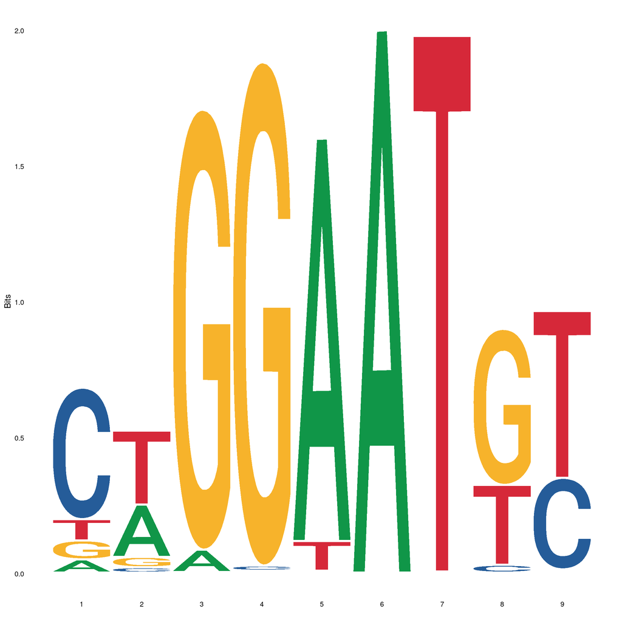

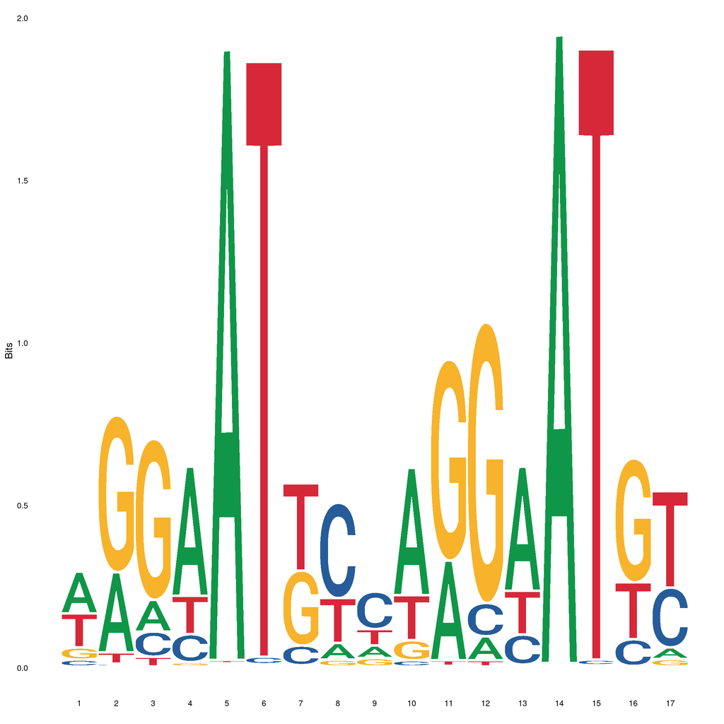

```r
lapply(names(seqlet_patterns.list), function(x){
  plot<-rtracklayer::import(seqlet_patterns.list[[x]]) %>%
    getSeq(bsgenome, ., as.character = T) %>%
    ggseqlogo(.)
}) #%>% wrap_plots(ncol = 1) + plot_annotation(title = 'CWM-scan seqlets')
```

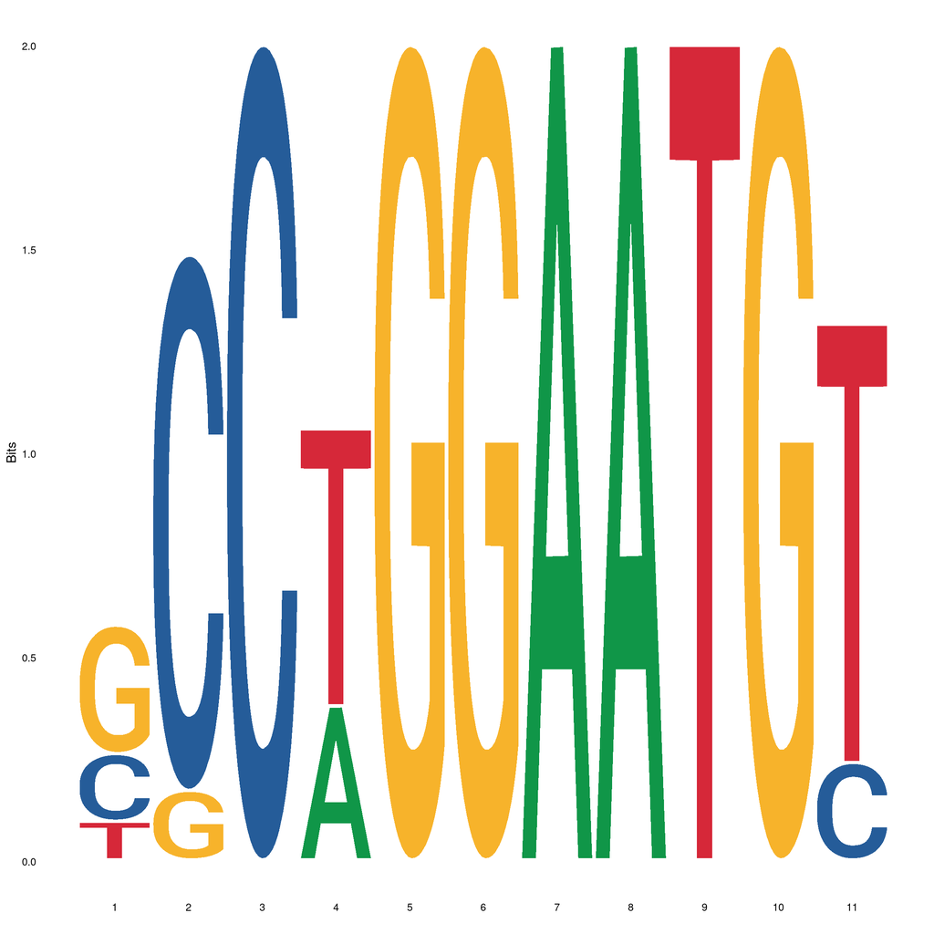

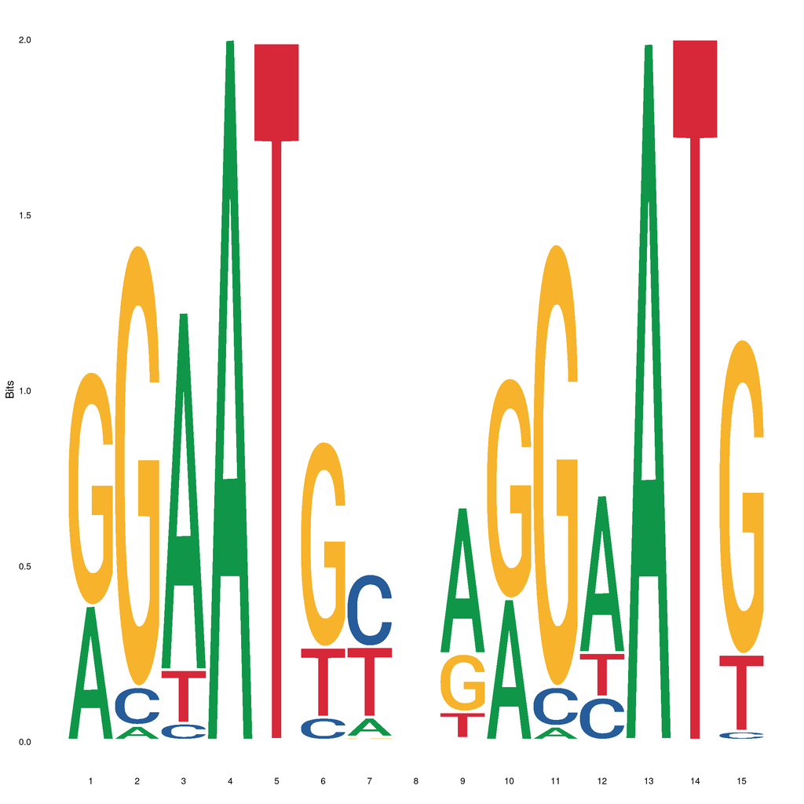

```r
lapply(names(seqlet_patterns.list), function(x){
  plot<- pwm_defaults.gr %>% plyranges::filter(motif==x) %>%
    plyranges::arrange(desc(score)) %>%
    head(n=1000) %>%
    getSeq(bsgenome, ., as.character = T) %>%
    ggseqlogo(.)
})  #wrap_plots(ncol = 1)  + plot_annotation(title = 'PWM-scan raw')
```

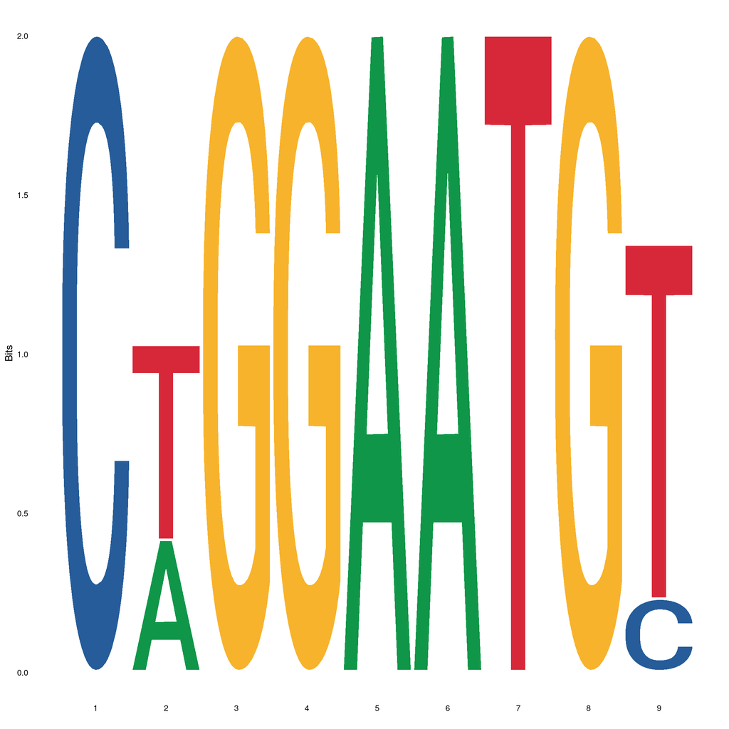

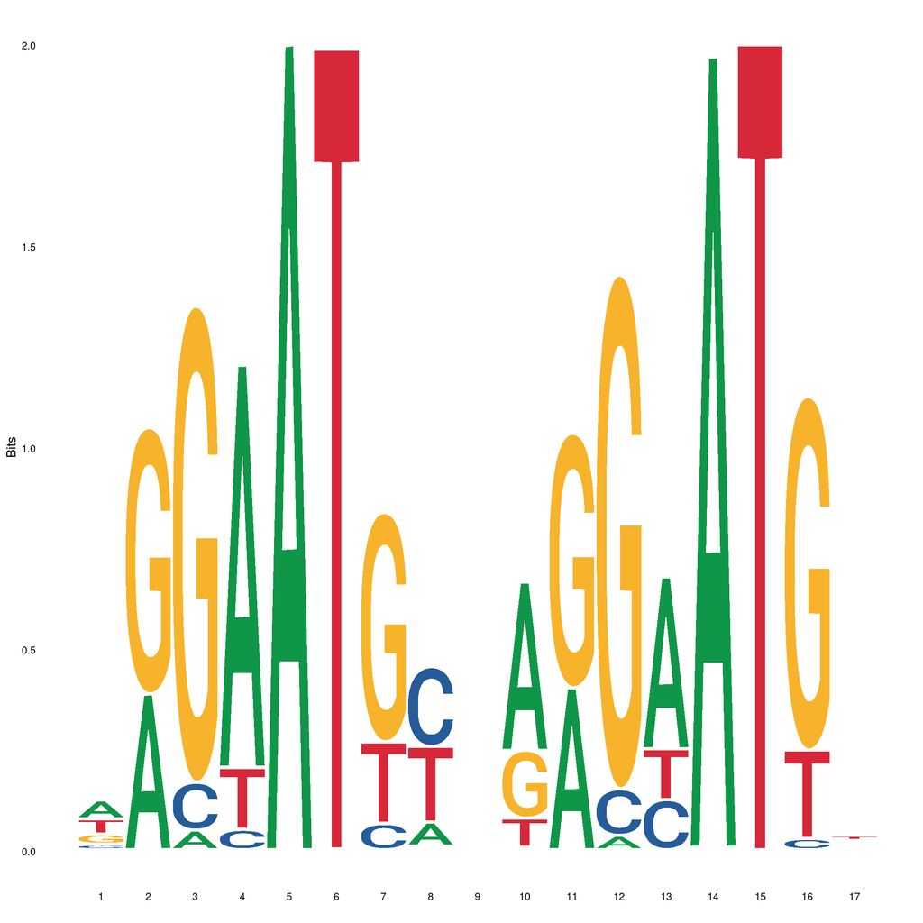

```r
pwm_defaults_aligned.gr<-c(
  pwm_defaults_noerv.gr %>% plyranges::filter(motif=='tead4') %>% GenomicRanges::resize(., 9, 'end'),
  pwm_defaults_noerv.gr %>% plyranges::filter(motif=='tead4_double') %>% GenomicRanges::resize(., 17, 'center')
)


lapply(names(seqlet_patterns.list), function(x){
  plot<-pwm_defaults_aligned.gr %>% plyranges::filter(motif==x) %>%
    plyranges::arrange(desc(score)) %>%
    head(n=1000) %>%
    getSeq(bsgenome, ., as.character = T) %>%
    ggseqlogo(.)
}) #%>% wrap_plots(ncol = 1)  + plot_annotation(title = 'PWM-scan aligned')
```

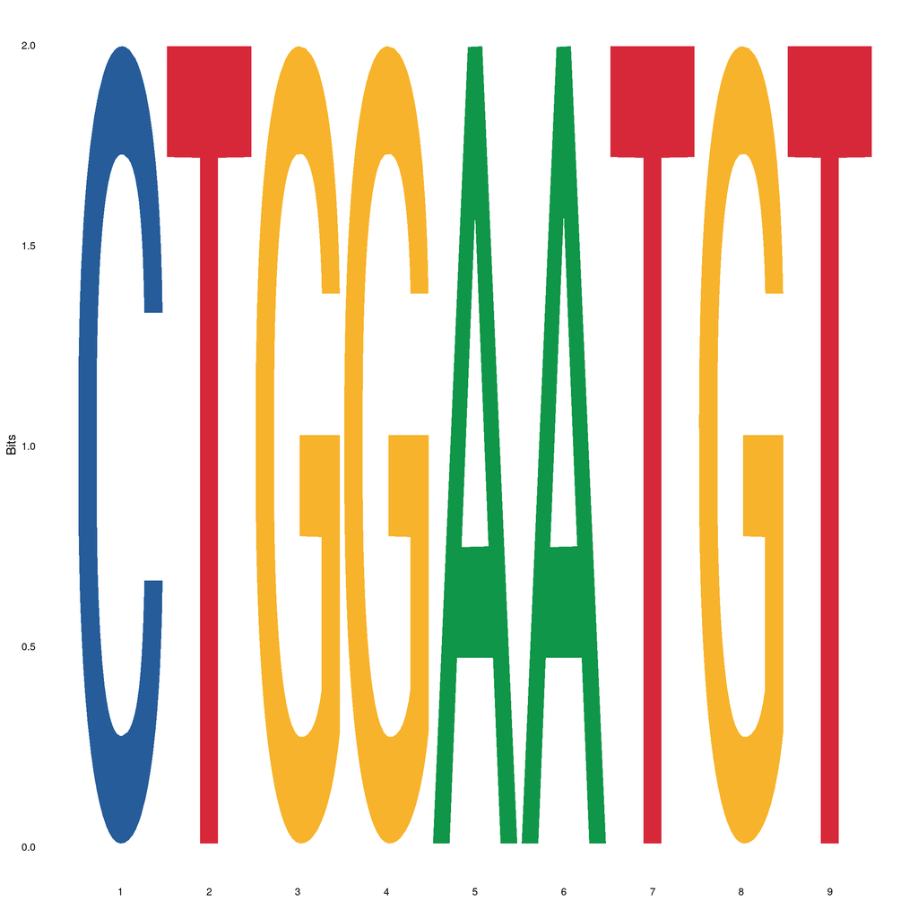

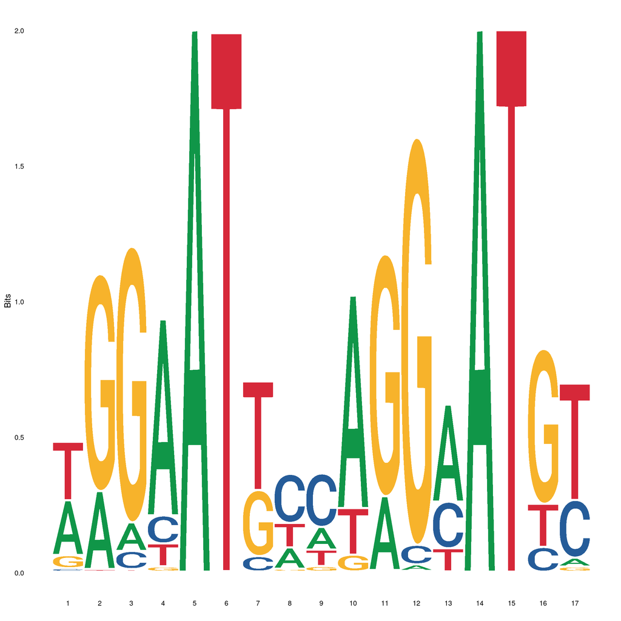

```r
pwm_seqletsource_aligned.gr<-pwm_seqletsource.gr

lapply(names(seqlet_patterns.list), function(x){
    plot<-pwm_seqletsource_aligned.gr %>% plyranges::filter(motif==x) %>%
        plyranges::arrange(desc(score)) %>%
        head(n=1000) %>%
        getSeq(bsgenome, ., as.character = T) %>%
        ggseqlogo(.)
})  #%>% wrap_plots(ncol = 1)  + plot_annotation(title = 'CWM-freq')
```

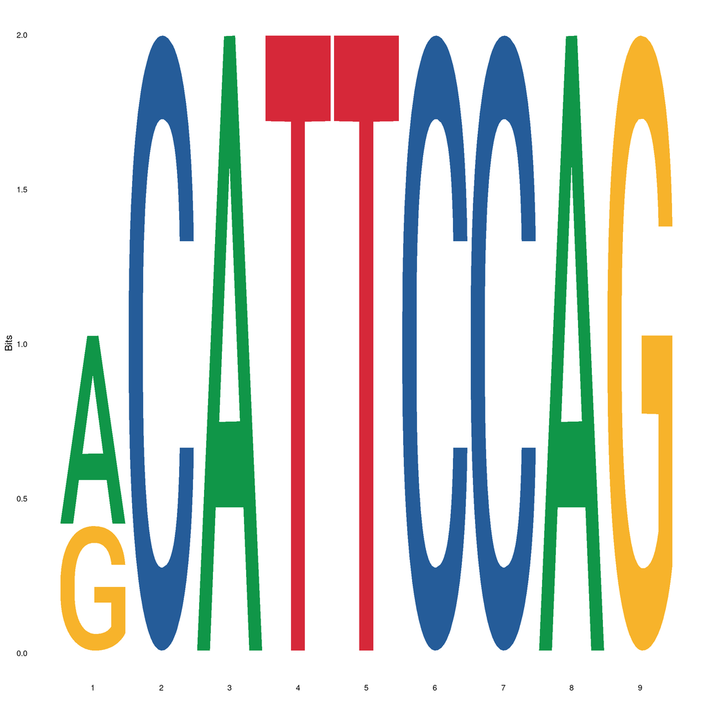

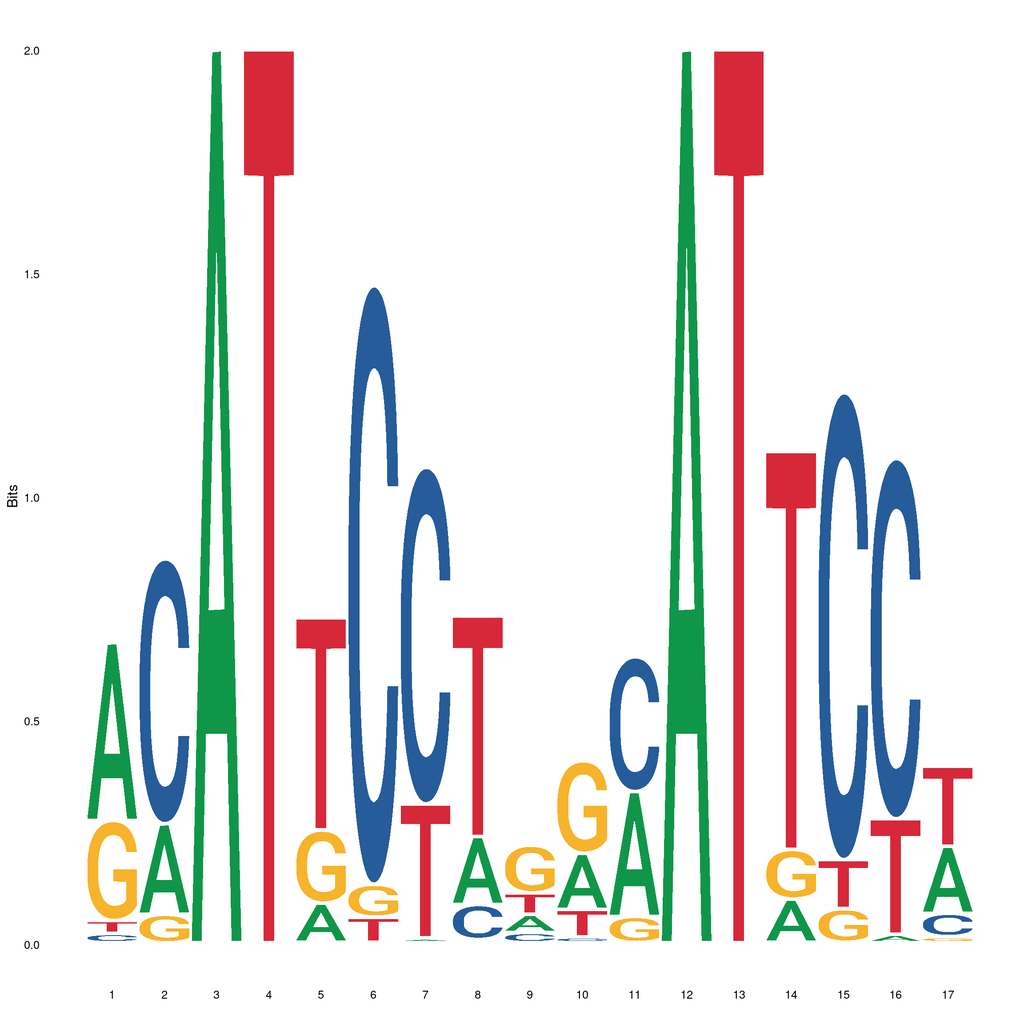

```r
lapply(names(seqlet_patterns.list), function(x){
    plot<-fimo_matches_all_no_ervs_marg_seqs.gr %>% plyranges::filter(motif==x) %>%
        plyranges::arrange(desc(score)) %>%
        head(n=1000) %>%
        getSeq(bsgenome, ., as.character = T) %>%
        ggseqlogo(.)
})  #%>% wrap_plots(ncol = 1)  + plot_annotation(title = 'marg-cwm-freq')
```

# Score all groups of motifs

Once obtained the PWMs from seqlets, remap the scores back.

```r
#Reimplement quantile measuring for PWM scanning scores.
all_motifs.list<-lapply(meme_patterns.list %>% unlist, function(x){
  message(x)

  #Call each set of motifs
  seqlet.df<-rtracklayer::import(seqlet_patterns.list[[x]]) %>%
    plyranges::mutate(seq = getSeq(bsgenome, ., as.character = T))
  #motif_contrib.gr<- motifs_tead4s_noervs.gr %>% plyranges::filter(pattern_name==modisco_patterns_inverse.list[[x]]) %>%
  motif_contrib.gr<- motifs_tead4s_noervs.gr %>% plyranges::filter(pattern_name == x) %>% unique() %>%
    plyranges::mutate(seq = getSeq(bsgenome, ., as.character = T))
  pwm_freq.gr<-pwm_defaults_aligned.gr %>% plyranges::filter(motif == x) %>% unique() %>%
    plyranges::mutate(seq = getSeq(bsgenome, ., as.character = T))
  cwm_freq.gr<-pwm_seqletsource_noerv.gr %>% plyranges::filter(motif == x) %>% unique() %>%
    plyranges::mutate(seq = getSeq(bsgenome, ., as.character = T))
  marg_cwm_freq.gr<-fimo_matches_all_no_ervs_marg_seqs_noerv.gr%>% plyranges::filter(motif == x) %>% unique() %>%
    plyranges::mutate(seq = getSeq(bsgenome, ., as.character = T))

  #Get log2-derived IC
  ic<-ic.list[[x]]

  #Get PWM scores
  message('getting seqlets...')
  seqlet.df$pwm_match_score<-mclapply(seqlet.df$seq, function(y) get_sequence_ic(ic = ic, seq = y), mc.cores = 8) %>% unlist()
  message('getting motif_contrib...')
  motif_contrib.gr$pwm_match_score<-mclapply(motif_contrib.gr$seq, function(y) get_sequence_ic(ic = ic, seq = y), mc.cores = 8) %>% unlist()
  message('getting freq...')
  pwm_freq.gr$pwm_match_score<-mclapply(pwm_freq.gr$seq, function(y) get_sequence_ic(ic = ic, seq = y), mc.cores = 8) %>% unlist()
  cwm_freq.gr$pwm_match_score<-mclapply(cwm_freq.gr$seq, function(y) get_sequence_ic(ic = ic, seq = y), mc.cores = 8) %>% unlist()
  marg_cwm_freq.gr$pwm_match_score<-mclapply(marg_cwm_freq.gr$seq, function(y) get_sequence_ic(ic = ic, seq = y), mc.cores = 8) %>% unlist()

  #Get quantiles based on seqlet distributions
  match_score_dist<-ecdf(seqlet.df$pwm_match_score)

  seqlet.df$pwm_match_score_q<-match_score_dist(seqlet.df$pwm_match_score)
  motif_contrib.gr$pwm_match_score_q<-match_score_dist(motif_contrib.gr$pwm_match_score)
  pwm_freq.gr$pwm_match_score_q<-match_score_dist(pwm_freq.gr$pwm_match_score)
  cwm_freq.gr$pwm_match_score_q<-match_score_dist(cwm_freq.gr$pwm_match_score)
  marg_cwm_freq.gr$pwm_match_score_q<-match_score_dist(marg_cwm_freq.gr$pwm_match_score)

  #Export
  return(list(seqlet = seqlet.df, cwm_contrib = motif_contrib.gr, pwms = pwm_freq.gr, cwm_freq = cwm_freq.gr,marg_cwm_freq = marg_cwm_freq.gr, match_score_dist = match_score_dist))
})

names(all_motifs.list)<-meme_patterns.list %>% unlist
saveRDS(all_motifs.list, 'analysis/all_motifs_with_scores.list.rds')

lapply(all_motifs.list, function(x) lapply(x, function(y) length(y)))
```

```
## $tead4
## $tead4$seqlet
## [1] 8063
##
## $tead4$cwm_contrib
## [1] 49606
##
## $tead4$pwms
## [1] 24760
##
## $tead4$cwm_freq
## [1] 21550
##
## $tead4$marg_cwm_freq
## [1] 18507
##
## $tead4$match_score_dist
## [1] 1
##
##
## $tead4_double
## $tead4_double$seqlet
## [1] 2800
##
## $tead4_double$cwm_contrib
## [1] 7185
##
## $tead4_double$pwms
## [1] 17889
##
## $tead4_double$cwm_freq
## [1] 20634
##
## $tead4_double$marg_cwm_freq
## [1] 18836
##
## $tead4_double$match_score_dist
## [1] 1
```

# prepering regions

```r
# #pwm-freq
# tead4_double_pwms.gr$dna <- getSeq(BSgenome.Mmusculus.UCSC.mm10, tead4_double_pwms.gr)
# tead4_pwms.gr$dna <- getSeq(BSgenome.Mmusculus.UCSC.mm10, tead4_pwms.gr)

# ggplot() + geom_logo(as.data.frame(tead4_double_pwms.gr$dna)) + theme_logo()
# ggplot() + geom_logo(as.data.frame(tead4_pwms.gr$dna)) + theme_logo()
#
# #rev complement
# test <- tead4_double_pwms.gr$dna
# test2 <- reverseComplement(test)
# test2 <- as.data.frame(test2)
# tead4_double_pwms.gr$dna2 <- test2$x
# ggplot() + geom_logo(as.data.frame(tead4_double_pwms.gr$dna2)) + theme_logo()
#
# # save tsv
# readr::write_tsv(as.data.frame(tead4_double_cwms_seqlet.gr), 'heatmap/new_tead4_double_cwms_seqlets.tsv.gz')
# readr::write_tsv(as.data.frame(tead4_double_cwms.gr), 'heatmap/new_tead4_double_cwms.tsv.gz')
#
# readr::write_tsv(as.data.frame(tead4_cwms_seqlet.gr), 'heatmap/new_tead4_cwms_seqlets.tsv.gz')
# readr::write_tsv(as.data.frame(tead4_cwms.gr), 'heatmap/new_tead4_cwms.tsv.gz')

# #resizing to predict genomic regions directly
# tead4_double_cwms.df <- read_tsv("/n/projects/kd2200/publication/rebuttal/heatmap/new_tead4_double_cwms.tsv.gz")
# tead4_double_cwms.gr  <- makeGRangesFromDataFrame(tead4_double_cwms.df,starts.in.df.are.0based = F, keep.extra.columns = T)
# tead4_double_cwms.gr$dna3 <- resize(tead4_double_cwms.gr, 999, "center") %>% getSeq(bsgenome, ., as.character = T)
# readr::write_tsv(as.data.frame(tead4_double_cwms.gr), '../../rebuttal/heatmap/new_tead4_double_cwms_genomic_seqeunces.tsv.gz')
#
# tead4_cwms.df <- read_tsv("/n/projects/kd2200/publication/rebuttal/heatmap/new_tead4_cwms.tsv.gz")
# tead4_cwms.gr  <- makeGRangesFromDataFrame(tead4_cwms.df,starts.in.df.are.0based = F, keep.extra.columns = T)
# tead4_cwms.gr$dna3 <- resize(tead4_cwms.gr, 999, "center") %>% getSeq(bsgenome, ., as.character = T)
# readr::write_tsv(as.data.frame(tead4_cwms.gr), '../../rebuttal/heatmap/new_tead4_cwms_genomic_seqeunces.tsv.gz')
#
# #pwms
# readr::write_tsv(as.data.frame(tead4_double_pwms.gr), 'heatmap/new_tead4_double_pwms.tsv.gz')
# readr::write_tsv(as.data.frame(tead4_pwms.gr), 'heatmap/new_tead4_pwms.tsv.gz')
#
# # original cwm
#
# tead4_double.df <- read_tsv("/n/projects/kd2200/publication/bpnet/cwm_all_regions/tead4/instances_by_pattern/m0_p1_motif-instances-all-regions.tsv.gz")
# tead4_double.gr <- tead4_double.df %>% makeGRangesFromDataFrame(seqnames.field = "example_chrom",start.field = "pattern_start_abs", end.field = "pattern_end_abs",keep.extra.columns = T, starts.in.df.are.0based = T)
# tead4_double.gr <- unique(tead4_double.gr)
#
# tead4.df <- read_tsv("/n/projects/kd2200/publication/bpnet/cwm_all_regions/tead4/instances_by_pattern/m0_p0_motif-instances-all-regions.tsv.gz")
# tead4.gr <- tead4.df %>% makeGRangesFromDataFrame(seqnames.field = "example_chrom",start.field = "pattern_start_abs", end.field = "pattern_end_abs",keep.extra.columns = T, starts.in.df.are.0based = T)
# tead4.gr <- unique(tead4.gr)
#
# #erv
# rm <- readRDS("/n/projects/mw2098/genomes/mm10/repeatmasker.mm10.gr.rds")
# erv <- rm[grep("ERV", rm$repeat_class)]
#
# tead4_double_noerv.gr <- tead4_double.gr[which(!overlapsAny(tead4_double.gr, erv, ignore.strand=T))]
# tead4_noerv.gr <- tead4.gr[which(!overlapsAny(tead4.gr, erv, ignore.strand=T))]
#
# # remove palindormic
# tead4_double_noerv.gr$pattern_name <- "tead4_double"
# tead4_double_noerv.gr <- remove_palindromic_motifs_from_bpnet_instances(tead4_double_noerv.gr , pattern_to_filter="tead4_double")
#
# tead4_noerv.gr$pattern_name <- "tead4"
# tead4_noerv.gr <- remove_palindromic_motifs_from_bpnet_instances(tead4_noerv.gr , pattern_to_filter="tead4")
#
# #getseq
# tead4_noerv.gr$dna <- as.data.frame(getSeq(BSgenome.Mmusculus.UCSC.mm10,  tead4_noerv.gr))
# tead4_double_noerv.gr$dna <- as.data.frame(getSeq(BSgenome.Mmusculus.UCSC.mm10,tead4_double_noerv.gr))
#
# ggplot() + geom_logo(tead4_noerv.gr$dna) + theme_logo()
# ggplot() + geom_logo(tead4_double_noerv.gr$dna) + theme_logo()
#
# readr::write_tsv(as.data.frame(tead4_noerv.gr), 'tsv/new_tead4_noerv.tsv.gz')
# readr::write_tsv(as.data.frame(tead4_double_noerv.gr), 'tsv/new_tead4_double_noerv.tsv.gz')
#
```

# heatmaps

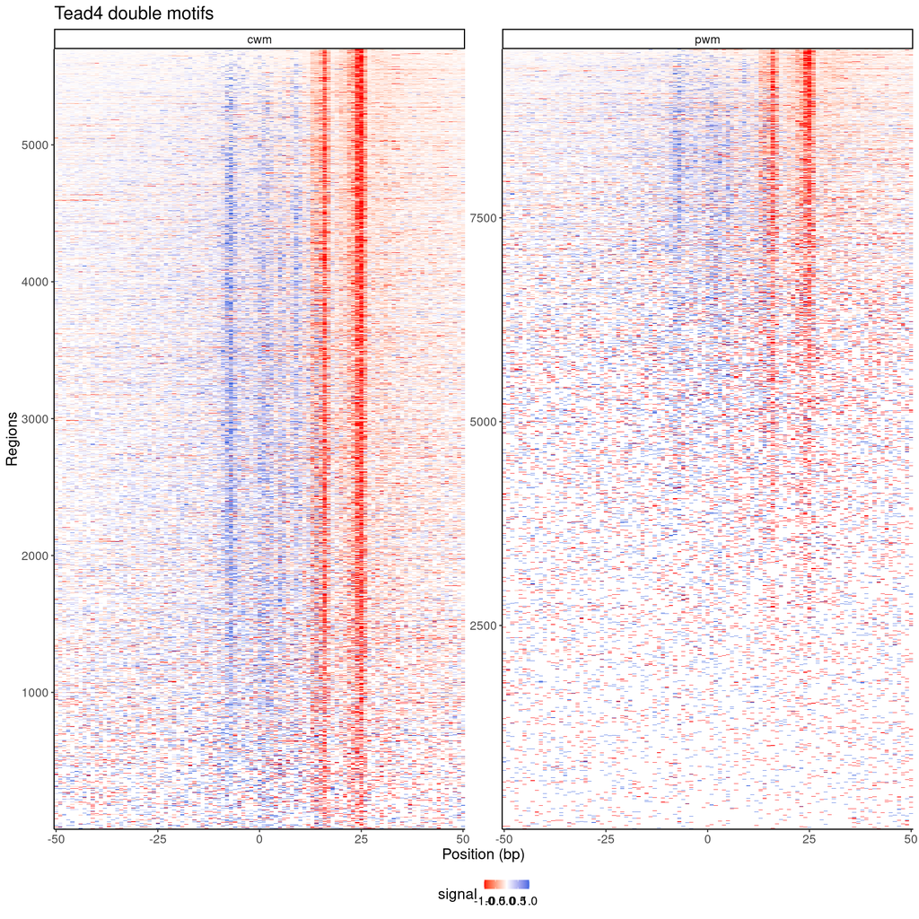

```r
nexus.bw.list<-list(tead4 = list(pos = '/n/projects/kd2200/publication/data_preparation/bw/mm10/nexus/combined/mtsc_tead4_nexus_combined_normalized_positive.bw',
                                        neg = '/n/projects/kd2200/publication/data_preparation/bw/mm10/nexus/combined/mtsc_tead4_nexus_combined_normalized_negative.bw'))


# tead4 double
tead4_double_cwms.gr<-all_motifs.list$tead4_double$cwm_contrib
tead4_double_pwms.gr<-all_motifs.list$tead4_double$pwms

# # Filter out PWM motif mappings that did not adhere to original regions, as this isn't a fair comparison
island_regions<-regions.path %>% rtracklayer::import(.)
tead4_double_cwms.gr <- tead4_double_cwms.gr %>% plyranges::filter(overlapsAny(., island_regions, ignore.strand = T))
tead4_double_pwms.gr <- tead4_double_pwms.gr %>% plyranges::filter(overlapsAny(., island_regions, ignore.strand = T))

#calculate signal to order
tead4_double_cwms.gr$signal <- nexus_regionSums(resize(tead4_double_cwms.gr, 51, "center"), nexus.bw.list$tead4)
tead4_double_pwms.gr$signal <- nexus_regionSums(resize(tead4_double_pwms.gr, 51, "center"), nexus.bw.list$tead4)

#order
tead4_double_cwms.gr <- tead4_double_cwms.gr[order(tead4_double_cwms.gr$signal,decreasing = T)]
tead4_double_pwms.gr <- tead4_double_pwms.gr[order(tead4_double_pwms.gr$signal,decreasing = T)]

tead4_double_cwms.gr <- tead4_double_cwms.gr[1:5699]#6699
tead4_double_pwms.gr <- tead4_double_pwms.gr[1:9569]#10569

#reverse strand
tead4_double_cwms_rev.gr <- tead4_double_cwms.gr
strand(tead4_double_cwms_rev.gr) <- ifelse(strand(tead4_double_cwms_rev.gr) == "+", "-", "+")
tead4_double_pwms_rev.gr <- tead4_double_pwms.gr
strand(tead4_double_pwms_rev.gr) <- ifelse(strand(tead4_double_pwms_rev.gr) == "+", "-", "+")

tead4_double_cwms_rev.gr <- tead4_double_cwms_rev.gr[order(tead4_double_cwms_rev.gr$signal,decreasing = F)]
tead4_double_pwms_rev.gr  <- tead4_double_pwms_rev.gr [order(tead4_double_pwms_rev.gr$signal,decreasing = F)]
#plot
tead4_motifs <- list(cwm=tead4_double_cwms_rev.gr,pwm =tead4_double_pwms_rev.gr)
plot_multiple_gr_nexus_heatmap(tead4_motifs, sample = nexus.bw.list$tead4, order = "as.is",upstream = 51, downstream = 50, title = "Tead4 double motifs",ncol = 2,removal_threshold = 0)
```

```r
# # tead4 single
tead4_cwms.gr<-all_motifs.list$tead4$cwm_contrib
tead4_pwms.gr<-all_motifs.list$tead4$pwms


# # Filter out PWM motif mappings that did not adhere to original regions, as this isn't a fair comparison
island_regions<-regions.path %>% rtracklayer::import(.)
tead4_cwms.gr <- tead4_cwms.gr %>% plyranges::filter(overlapsAny(., island_regions, ignore.strand = T))
tead4_pwms.gr <- tead4_pwms.gr %>% plyranges::filter(overlapsAny(., island_regions, ignore.strand = T))

#calculate signal to order
tead4_cwms.gr$signal <- nexus_regionSums(resize(tead4_cwms.gr, 51, "center"), nexus.bw.list$tead4)
tead4_pwms.gr$signal <- nexus_regionSums(resize(tead4_pwms.gr, 51, "center"), nexus.bw.list$tead4)

#order
tead4_cwms.gr <- tead4_cwms.gr[order(tead4_cwms.gr$signal,decreasing = T)]
tead4_pwms.gr <- tead4_pwms.gr[order(tead4_pwms.gr$signal,decreasing = T)]

tead4_cwms.gr <- tead4_cwms.gr[1:40374]#45374
tead4_pwms.gr <- tead4_pwms.gr[1:11173]#16173

#reverse strand
tead4_cwms_rev.gr <- tead4_cwms.gr
strand(tead4_cwms_rev.gr) <- ifelse(strand(tead4_cwms_rev.gr) == "+", "-", "+")
tead4_pwms_rev.gr <- tead4_pwms.gr
strand(tead4_pwms_rev.gr) <- ifelse(strand(tead4_pwms_rev.gr) == "+", "-", "+")

tead4_cwms_rev.gr <- tead4_cwms_rev.gr[order(tead4_cwms_rev.gr$signal,decreasing = F)]
tead4_pwms_rev.gr  <- tead4_pwms_rev.gr [order(tead4_pwms_rev.gr$signal,decreasing = F)]
#plot
tead4_s_motifs <- list(cwm=tead4_cwms_rev.gr,pwm =tead4_pwms_rev.gr)
plot_multiple_gr_nexus_heatmap(tead4_s_motifs, sample = nexus.bw.list$tead4, order = "as.is",upstream = 51, downstream = 50, title = "Tead4 single motifs",ncol = 2,removal_threshold = 0)
```

[output not shown]

# marginalization tead4 double

```r
cwm_contrib <-all_motifs.list$tead4_double$cwm_contrib
pwm_freq<-all_motifs.list$tead4_double$pwms
cwm_freq <-all_motifs.list$tead4_double$cwm_freq
marg_cwm_freq <-all_motifs.list$tead4_double$marg_cwm_freq


#annotate
cwm_contrib$category <- "cwm_contrib"
pwm_freq$category <- "pwm_freq"
cwm_freq$category <- "cwm_freq"
marg_cwm_freq$category <- "marg_cwm_freq"


#reverse complement
pwm_freq$dna <- getSeq(bsgenome, pwm_freq)
test <-pwm_freq$dna
test2 <- reverseComplement(test)
test2 <- as.data.frame(test2)
pwm_freq$dna2 <- test2$x
ggplot() + geom_logo(as.data.frame(pwm_freq$dna2)) + theme_logo()


cwm_freq$dna <- getSeq(bsgenome, cwm_freq)
test <-cwm_freq$dna
test2 <- reverseComplement(test)
test2 <- as.data.frame(test2)
cwm_freq$dna2 <- test2$x
ggplot() + geom_logo(as.data.frame(cwm_freq$dna2)) + theme_logo()

ggplot() + geom_logo(as.data.frame(marg_cwm_freq$seq)) + theme_logo()
marg_cwm_freq$dna2 <- marg_cwm_freq$seq

#order
cwm_contrib<- cwm_contrib[order(cwm_contrib$pwm_match_score,decreasing = T)]
pwm_freq<- pwm_freq[order(pwm_freq$pwm_match_score,decreasing = T)]
cwm_freq<- cwm_freq[order(cwm_freq$pwm_match_score,decreasing = T)]
marg_cwm_freq<- marg_cwm_freq[order(marg_cwm_freq$pwm_match_score,decreasing = T)]

cwm_contrib_sel <- cwm_contrib[1:5000]
pwm_freq_sel<- pwm_freq[1:5000]
cwm_freq_sel<- cwm_freq[1:5000]
marg_cwm_freq_sel<- marg_cwm_freq[1:5000]

cwm_contrib_sel_context <- cwm_contrib_sel
cwm_contrib_sel_context$dna3 <- resize(cwm_contrib_sel_context, 999, "center") %>% getSeq(bsgenome, ., as.character = T)


# save tsv
readr::write_tsv(as.data.frame(cwm_contrib_sel), 'analysis/tsv/cwm_contrib_sel.tsv.gz')
readr::write_tsv(as.data.frame(pwm_freq_sel), 'analysis/tsv/pwm_freq_sel.tsv.gz')
readr::write_tsv(as.data.frame(cwm_freq_sel), 'analysis/tsv/cwm_freq_sel.tsv.gz')
readr::write_tsv(as.data.frame(marg_cwm_freq_sel), 'analysis/tsv/marg_cwm_freq_sel.tsv.gz')
readr::write_tsv(as.data.frame(cwm_contrib_sel_context), 'analysis/tsv/cwm_contrib_sel_context.tsv.gz')


cwm_contrib.df <-read_csv('/n/projects/kd2200/publication/rebuttal/analysis/csv/cwm_contrib_sel.csv')
cwm_contrib_context.df <-read_csv('/n/projects/kd2200/publication/rebuttal/analysis/csv/cwm_contrib_sel_context.csv')
pwm_freq.df <- read_csv('/n/projects/kd2200/publication/rebuttal/analysis/csv/pwm_freq_sel.csv')
td_cwm_freq.df <- read_csv('/n/projects/kd2200/publication/rebuttal/analysis/csv/cwm_freq_sel.csv')
#marg_freq.df <- read_csv('/n/projects/kd2200/publication/rebuttal/analysis/csv/marg_cwm_freq_sel.csv')

ggplot() +
    geom_density(data = cwm_contrib.df, aes(x = tead4), fill = "#8E68AD", alpha = 0.5,position = "identity",adjust = 1.5)+
    geom_density(data = cwm_contrib_context.df, aes(x = tead4), fill = "red", alpha = 0.5,position = "identity",adjust = 1.5)+
    geom_density(data = td_cwm_freq.df, aes(x = tead4), fill = "#f8c42d", alpha = 0.5,position = "identity",adjust = 1.5)+
    geom_density(data = pwm_freq.df , aes(x = tead4), fill = "#34A549", alpha = 0.5,position = "identity",adjust = 1.5) +
    labs(title = "Density Plot of tead4 double signal",
         x = "Tead4 signal",
         y = "Density") +scale_x_continuous(limits = c(0, 120), breaks = seq(0, 120, by = 20)) +
    theme_classic()
```

#marginalaiization of tead4 single

```r
cwm_contrib <-all_motifs.list$tead4$cwm_contrib
pwm_freq<-all_motifs.list$tead4$pwms
cwm_freq <-all_motifs.list$tead4$cwm_freq
marg_cwm_freq <-all_motifs.list$tead4$marg_cwm_freq


#annotate
cwm_contrib$category <- "cwm_contrib"
pwm_freq$category <- "pwm_freq"
cwm_freq$category <- "cwm_freq"
marg_cwm_freq$category <- "marg_cwm_freq"


#reverse complement
pwm_freq$dna <- getSeq(bsgenome, pwm_freq)
test <-pwm_freq$dna
test2 <- reverseComplement(test)
test2 <- as.data.frame(test2)
pwm_freq$dna2 <- test2$x
ggplot() + geom_logo(as.data.frame(pwm_freq$dna2)) + theme_logo()


cwm_freq$dna <- getSeq(bsgenome, cwm_freq)
test <-cwm_freq$dna
test2 <- reverseComplement(test)
test2 <- as.data.frame(test2)
cwm_freq$dna2 <- test2$x
ggplot() + geom_logo(as.data.frame(cwm_freq$dna2)) + theme_logo()

ggplot() + geom_logo(as.data.frame(marg_cwm_freq$seq)) + theme_logo()
marg_cwm_freq$dna2 <- marg_cwm_freq$seq

#order
cwm_contrib<- cwm_contrib[order(cwm_contrib$pwm_match_score,decreasing = T)]
pwm_freq<- pwm_freq[order(pwm_freq$pwm_match_score,decreasing = T)]
cwm_freq<- cwm_freq[order(cwm_freq$pwm_match_score,decreasing = T)]
marg_cwm_freq<- marg_cwm_freq[order(marg_cwm_freq$pwm_match_score,decreasing = T)]

cwm_contrib_sel <- cwm_contrib[1:20000]#49606
pwm_freq_sel<- pwm_freq[1:20000]#24760
cwm_freq_sel<- cwm_freq[1:20000]#21550
#marg_cwm_freq_sel<- marg_cwm_freq[1:18507]#18507

cwm_contrib_sel_context <- cwm_contrib_sel
cwm_contrib_sel_context$dna3 <- resize(cwm_contrib_sel_context, 999, "center") %>% getSeq(bsgenome, ., as.character = T)


# save tsv
readr::write_tsv(as.data.frame(cwm_contrib_sel), 'analysis/tsv/td_cwm_contrib_sel.tsv.gz')
readr::write_tsv(as.data.frame(pwm_freq_sel), 'analysis/tsv/td_pwm_freq_sel.tsv.gz')
readr::write_tsv(as.data.frame(cwm_freq_sel), 'analysis/tsv/td_cwm_freq_sel.tsv.gz')
readr::write_tsv(as.data.frame(marg_cwm_freq_sel), 'analysis/tsv/td_marg_cwm_freq_sel.tsv.gz')
readr::write_tsv(as.data.frame(cwm_contrib_sel_context), 'analysis/tsv/td_cwm_contrib_sel_context.tsv.gz')


td_cwm_contrib.df <-read_csv('/n/projects/kd2200/publication/rebuttal/analysis/csv/td_cwm_contrib_sel.csv')
td_cwm_contrib_context.df <-read_csv('/n/projects/kd2200/publication/rebuttal/analysis/csv/td_cwm_contrib_sel_context.csv')
td_pwm_freq.df <- read_csv('/n/projects/kd2200/publication/rebuttal/analysis/csv/td_pwm_freq_sel.csv')
td_cwm_freq.df <- read_csv('/n/projects/kd2200/publication/rebuttal/analysis/csv/td_cwm_freq_sel.csv')
#td_marg.df <- read_csv('/n/projects/kd2200/publication/rebuttal/analysis/csv/td_marg_cwm_freq_sel.csv')

ggplot() +
  geom_density(data = td_cwm_contrib.df, aes(x = tead4), fill = "#8E68AD", alpha = 0.5,position = "identity",adjust = 1.5)+
  geom_density(data = td_cwm_contrib_context.df, aes(x = tead4), fill = "red", alpha = 0.5,position = "identity",adjust = 1.5)+
  geom_density(data = td_cwm_freq.df, aes(x = tead4), fill = "#f8c42d", alpha = 0.5,position = "identity",adjust = 1.5)+
  geom_density(data = td_pwm_freq.df , aes(x = tead4), fill = "#34A549", alpha = 0.5,position = "identity",adjust = 1.5) +
  labs(title = "Density Plot of tead4 single signal",
       x = "Tead4 signal",
       y = "Density")+scale_x_continuous(limits = c(0, 120), breaks = seq(0, 120, by = 20)) +
  theme_classic()
```

#homer logo reverse complement

```r
peaks.gr <- import.bed("/n/projects/kd2200/publication/bpnet_prep/macs2/combined/mtsc_tead4_nexus_summits.bed")
peaks.gr <- keepStandardChromosomes(peaks.gr, pruning.mode = "coarse")
peaks.gr<-peaks.gr[order(peaks.gr$score, decreasing = TRUE)][1:1000]
peaks_resize.gr<- resize(peaks.gr, 200,"center")
export.bed(peaks_resize.gr, "homer_peakanalysis/mtsc_tead4_nexus_summits_top1000_resized_200bp_center.bed")
peaks_resize.gr


#de novo motifs
#findMotifsGenome.pl homer_peakanalysis/mtsc_tead4_nexus_summits_top1000_resized_200bp_center_new.bed /n/projects/kd2200/analysis/BPNet/cegkttyz_tsc_bpnet/tsc_model_morval_idr_peaks_morereps_wotead4/bpnet/fasta/mm10.fa homer_peakanalysis -size 200 -len 9,13,18,20 -preparsedDir parsing_genome_dir -p 8
```

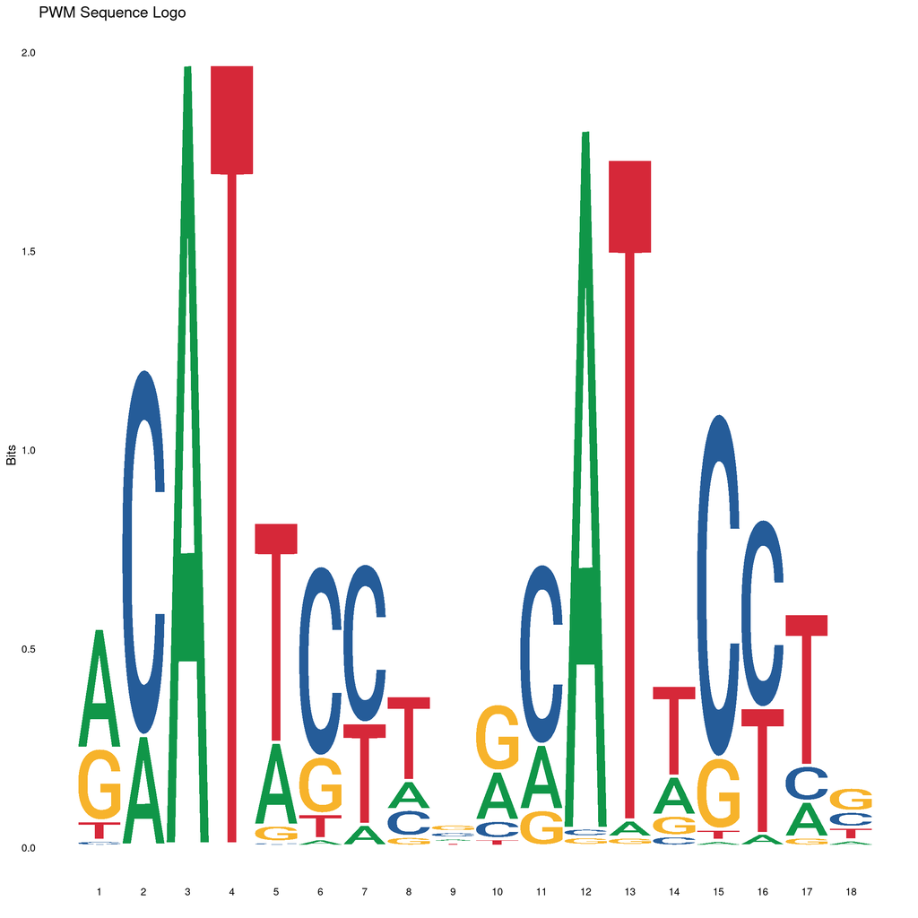

```r
#test <- read_tsv("/n/projects/kd2200/publication/rebuttal/homer_peakanalysis/homerResults/motif1.similar4.motif")
test <- read_tsv("/n//projects/kd2200/publication/rebuttal/homer_peakanalysis/test_with_101bp/homer_analysis_101/homerResults/motif1.similar5.motif")
library(Biostrings)
# pwm_matrix <- matrix(c(
#     0.165, 0.439, 0.297, 0.280, 0.442, 0.812, 0.001, 0.001, 0.046, 0.099, 0.469, 0.266, 0.105, 0.620, 0.935, 0.003, 0.007, 0.036,  # A
#     0.422, 0.099, 0.102, 0.119, 0.356, 0.076, 0.046, 0.171, 0.650, 0.564, 0.043, 0.001, 0.112, 0.218, 0.036, 0.036, 0.053, 0.488,  # C
#     0.264, 0.155, 0.518, 0.552, 0.063, 0.056, 0.059, 0.392, 0.053, 0.129, 0.109, 0.732, 0.782, 0.066, 0.026, 0.007, 0.557, 0.053,  # G
#     0.148, 0.307, 0.083, 0.049, 0.139, 0.056, 0.894, 0.435, 0.251, 0.208, 0.380, 0.001, 0.001, 0.096, 0.003, 0.954, 0.383, 0.422   # T
# ), nrow = 4, byrow = TRUE)

pwm_matrix <- matrix(c(
    0.550, 0.230, 0.997, 0.001, 0.256, 0.026, 0.076, 0.192, 0.205, 0.346, 0.231, 0.975, 0.025, 0.244, 0.013, 0.038, 0.154, 0.102,  # A
    0.026, 0.768, 0.001, 0.001, 0.013, 0.680, 0.564, 0.180, 0.282, 0.128, 0.640, 0.012, 0.001, 0.064, 0.795, 0.577, 0.154, 0.269,  # C
    0.334, 0.001, 0.001, 0.001, 0.052, 0.205, 0.001, 0.064, 0.346, 0.474, 0.128, 0.012, 0.012, 0.128, 0.166, 0.001, 0.039, 0.411,  # G
    0.090, 0.001, 0.001, 0.997, 0.679, 0.089, 0.359, 0.564, 0.167, 0.052, 0.001, 0.001, 0.962, 0.564, 0.026, 0.384, 0.653, 0.218   # T
), nrow = 4, byrow = TRUE)

# Assign nucleotide row names
rownames(pwm_matrix) <- c("A", "C", "G", "T")

# Reverse complement the PWM
# reverse_complement_pwm <- function(pwm) {
#     # Reverse the columns
#     reversed_pwm <- pwm[, ncol(pwm):1]
#
#     # Swap rows for A<->T and C<->G
#     reversed_pwm[c("A", "T"), ] <- reversed_pwm[c("T", "A"), ]
#     reversed_pwm[c("C", "G"), ] <- reversed_pwm[c("G", "C"), ]
#
#     return(reversed_pwm)
# }
#
# # Apply the reverse complement function
# pwm_rc <- reverse_complement_pwm(pwm_matrix)
#

# Plot
ggplot() +
    geom_logo(pwm_matrix) +
    theme_logo() +
    ggtitle("PWM Sequence Logo")
```

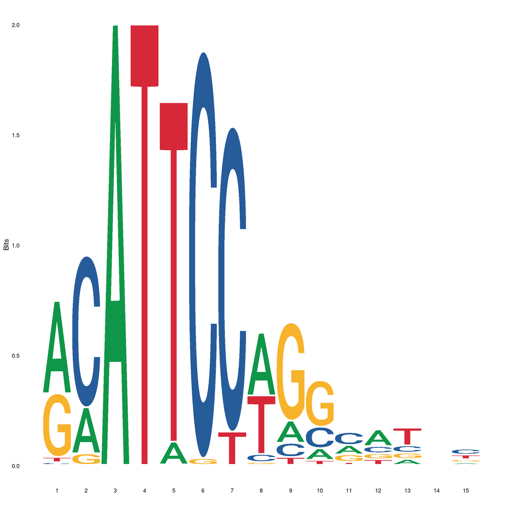

```r
zoops_meme <- read_table("/n/projects/kd2200/publication/rebuttal/analysis/zoops_meme_seqs.txt")
zoops_meme_1 <- DNAStringSet(zoops_meme$seq)
zoops_meme_rev <- Biostrings::reverseComplement(zoops_meme_1)
ggplot() + geom_logo(as.data.frame(zoops_meme_rev)) + theme_logo()
```

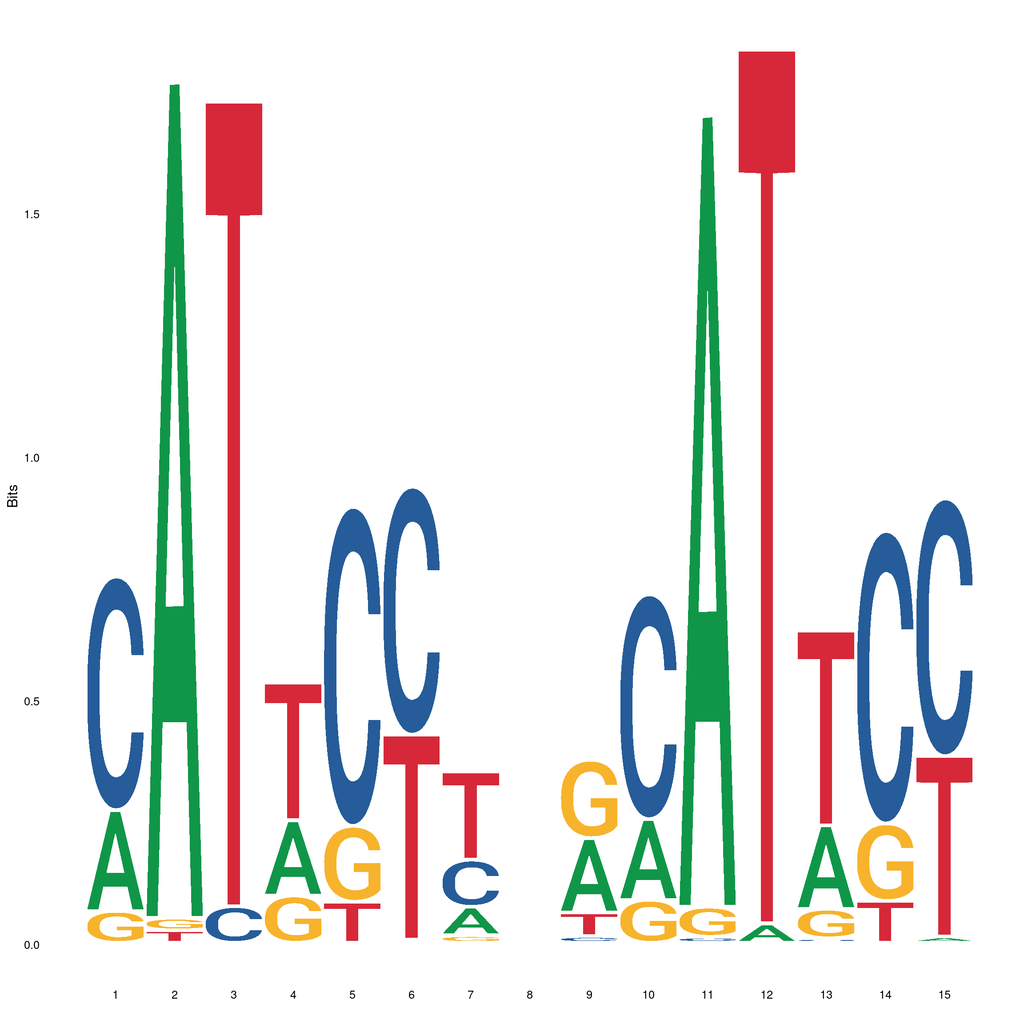

```r
anr_meme <- read_table("/n/projects/kd2200/publication/rebuttal/analysis/anr_meme_seqs.txt")
anr_meme_1 <- DNAStringSet(anr_meme$seq)
anr_meme_rev <- Biostrings::reverseComplement(anr_meme_1)
ggplot() + geom_logo(as.data.frame(anr_meme_rev)) + theme_logo()
```

```r
all_tf_final_no_promoter.gr<-readr::read_tsv("/n/projects/kd2200/publication/bpnet/analysis/tsv/all_tfregions_with_binding_activity.tsv") %>% makeGRangesFromDataFrame(keep.extra.columns = T, starts.in.df.are.0based =F)

#from island analysis in rmd 5.Tead4 anf Yap1 analysis
tead4_tfap2c_1 <-subset(all_tf_final_no_promoter.gr,island_content=="Tead4-1_Tfap2c-1")
td.gr <-tead4_tfap2c_1 %>% subset(tf == "Tead4")
tf.gr <- tead4_tfap2c_1 %>% subset(tf== "Tfap2c")

t <- distanceToNearest(td.gr, tf.gr)
g <- t@elementMetadata
s <- g$distance<=160
s <- t[s]
td_tf <-tead4_tfap2c_1[s@from]
td_tf$td_tf_motif_dis <- s@elementMetadata
td_tf <- td_tf[order(td_tf$td_tf_motif_dis, decreasing = F)]

#check motif
tf.gr$seq <- getSeq(bsgenome, tf.gr, as.character = T)
ggplot() + geom_logo(tf.gr$seq) + theme_logo()

#overlap with tfpa2c motifs
q <- find_overlaps(tf.gr, td_tf , maxgap = 150)
q$seq <- getSeq(bsgenome, q, as.character = T)
ggplot() + geom_logo(q$seq) + theme_logo()
q$contrib_yap1_attf_motif <- regionSums(q, tsc.contrib.profile.bws$yap1)
q$contrib_tfap2c_attf_motif <- regionSums(q, tsc.contrib.profile.bws$tfap2c)
q$contrib_tead4_attf_motif <- regionSums(q, tsc.contrib.profile.bws$tead4)
q.df <- as.data.frame(q)


#linear model
lm_model <- lm(contrib_yap1_attf_motif ~ distance, data=q.df)
summary(lm_model)

#lm_model <- lm(contrib_tfap2c_attf_motif ~ distance, data=q.df)
#summary(lm_model)

#lm_model <- lm(contrib_tead4_attf_motif ~ distance, data=q.df)
#summary(lm_model)

# Call:
# lm(formula = contrib_yap1_attf_motif ~ distance, data = q.df)
#
# Residuals:
#      Min       1Q   Median       3Q      Max
# -0.22877 -0.07557 -0.01139  0.05788  0.42051
#
# Coefficients:
#               Estimate Std. Error t value Pr(>|t|)
# (Intercept)  2.074e-01  4.250e-03   48.80   <2e-16 ***
# distance    -8.633e-04  5.852e-05  -14.75   <2e-16 ***
# ---
# Signif. codes:  0 ‘***’ 0.001 ‘**’ 0.01 ‘*’ 0.05 ‘.’ 0.1 ‘ ’ 1
#
# Residual standard error: 0.1007 on 1551 degrees of freedom
# Multiple R-squared:  0.1231,  Adjusted R-squared:  0.1225
# F-statistic: 217.6 on 1 and 1551 DF,  p-value: < 2.2e-16



# q.df$binned_distance <- cut(q.df$distance, breaks=seq(min(q.df$distance), max(q.df$distance), by=10), include.lowest=TRUE, labels=FALSE)
#
#     binned_data <- q.df %>%
#     group_by(binned_distance) %>%
#     summarize(mean_contrib = mean(contrib_yap1_attf_motif, na.rm = TRUE))
#   lm_model <- lm(mean_contrib ~ binned_distance, data=binned_data)
#   summary(lm_model)

  # ggplot(binned_data, aes(x = binned_distance, y = mean_contrib)) +
  #   geom_bar(stat = "identity", fill = "blue", alpha = 0.7) +  # Bar plot for the mean contribution
  #   geom_smooth(method = "loess", color = "red", se = FALSE, linetype = "dashed") +  # Smoothed trend line
  #   coord_flip() +
  #   theme_minimal() +
  #   ylab("Mean Motif Contribution") +
  #   xlab("Row Bins (10 rows each)") +
  #   ggtitle("Binned Plot for TFAP2C Contribution")

 #for cdx2

tead4_cdx2_1 <-subset(all_tf_final_no_promoter.gr,island_content=="Cdx2-1_Tead4-1")
td.gr <-tead4_cdx2_1 %>% subset(tf == "Tead4")
cd.gr <- tead4_cdx2_1 %>% subset(tf== "Cdx2")

t <- distanceToNearest(td.gr, cd.gr)
g <- t@elementMetadata
s <- g$distance<=160
s <- t[s]
td_cd <-td.gr[s@from]
td_cd$td_tf_motif_dis <- s@elementMetadata
td_cd <- td_cd[order(td_cd$td_tf_motif_dis, decreasing = F)]
#cd.gr$seq <- getSeq(bsgenome, cd.gr, as.character = T)
#ggplot() + geom_logo(cd.gr$seq) + theme_logo()


q <- find_overlaps(cd.gr, td_cd, maxgap = 150)
q$seq <- getSeq(bsgenome, q, as.character = T)
ggplot() + geom_logo(q$seq) + theme_logo()
q$contrib_yap1_atcd_motif <- regionSums(q, tsc.contrib.profile.bws$yap1)
q$contrib_tead4_atcd_motif <- regionSums(q, tsc.contrib.profile.bws$tead4)
q$contrib_cdx2_atcd_motif <- regionSums(q, tsc.contrib.profile.bws$cdx2)
q.df <- as.data.frame(q)
lm_model <- lm(contrib_yap1_atcd_motif ~ distance, data=q.df)
summary(lm_model)



## for tead4_double

tead4double_tfap2c_1 <-subset(all_tf_final_no_promoter.gr,island_content=="Tead4_double-1_Tfap2c-1")
tdbl.gr <-tead4double_tfap2c_1 %>% subset(tf == "Tead4_double")
tf.gr <- tead4double_tfap2c_1 %>% subset(tf== "Tfap2c")

t <- distanceToNearest(tdbl.gr, tf.gr)
g <- t@elementMetadata
s <- g$distance<=160
s <- t[s]
tdbl_tf <- tdbl.gr[s@from]
tdbl_tf$td_tf_motif_dis <- s@elementMetadata
tdbl_tf <- tdbl_tf[order(tdbl_tf$td_tf_motif_dis, decreasing = F)]

tf.gr$seq <- getSeq(bsgenome,  tf.gr, as.character = T)
ggplot() + geom_logo(tf.gr$seq) + theme_logo()


q <- find_overlaps( tf.gr, tdbl_tf, maxgap = 150)
q$seq <- getSeq(bsgenome, q, as.character = T)
ggplot() + geom_logo(q$seq) + theme_logo()
q$contrib_yap1_attf_motif <- regionSums(q, tsc.contrib.profile.bws$yap1)
q.df <- as.data.frame(q)


q.df$binned_distance <- cut(q.df$distance, breaks=seq(min(q.df$distance), max(q.df$distance), by=10), include.lowest=TRUE, labels=FALSE)

binned_data <- q.df %>%
    group_by(binned_distance) %>%
    summarize(mean_contrib = mean(contrib_yap1_attf_motif, na.rm = TRUE))
lm_model <- lm(mean_contrib ~ binned_distance, data=binned_data)
summary(lm_model)



## for gata3

tead4_gata3_1 <-subset(all_tf_final_no_promoter.gr,island_content=="Gata3-1_Tead4-1")
td.gr <- tead4_gata3_1 %>% subset(tf == "Tead4")
gat.gr <- tead4_gata3_1 %>% subset(tf== "Gata3")

t <- distanceToNearest(td.gr, gat.gr)
g <- t@elementMetadata
s <- g$distance<=160
s <- t[s]
td_gt <-tead4_gata3_1[s@from]
td_gt$td_gt_motif_dis <- s@elementMetadata
td_gt <- td_gt[order(td_gt$td_gt_motif_dis, decreasing = F)]

gat.gr$seq <- getSeq(bsgenome, gat.gr, as.character = T)
ggplot() + geom_logo(gat.gr$seq) + theme_logo()


q <- find_overlaps( gat.gr, td_gt, maxgap = 150)
q$seq <- getSeq(bsgenome, q, as.character = T)
ggplot() + geom_logo(q$seq) + theme_logo()
q$contrib_yap1_atgat_motif <- regionSums(q, tsc.contrib.profile.bws$yap1)
q.df <- as.data.frame(q)


q.df$binned_distance <- cut(q.df$distance, breaks=seq(min(q.df$distance), max(q.df$distance), by=10), include.lowest=TRUE, labels=FALSE)

binned_data <- q.df %>%
    group_by(binned_distance) %>%
    summarize(mean_contrib = mean(contrib_yap1_atgat_motif, na.rm = TRUE))
lm_model <- lm(mean_contrib ~ binned_distance, data=binned_data)
summary(lm_model)
```

#making graph

```r
tead4_tfap2c_1 <-subset(all_tf_final_no_promoter.gr,island_content=="Tead4-1_Tfap2c-1")
td.gr <-tead4_tfap2c_1 %>% subset(tf == "Tead4")
tf.gr <- tead4_tfap2c_1 %>% subset(tf== "Tfap2c")

t <- distanceToNearest(td.gr, tf.gr)
g <- t@elementMetadata
s <- g$distance<=500
s <- t[s]
td_tf <-tead4_tfap2c_1[s@from]
td_tf$td_tf_motif_dis <- s@elementMetadata
td_tf <- td_tf[order(td_tf$td_tf_motif_dis, decreasing = F)]
td_tf$yap1_contrib_at_tfap2c <- regionSums(td_tf, tsc.contrib.profile.bws$yap1)

#tf.gr$seq <- getSeq(bsgenome, tf.gr, as.character = T)
#ggplot() + geom_logo(tf.gr$seq) + theme_logo()

q <- find_overlaps(tf.gr, td_tf , maxgap = 500)
q$seq <- getSeq(bsgenome, q, as.character = T)
ggplot() + geom_logo(q$seq) + theme_logo()
q$contrib_yap1_attf_motif <- regionSums(q, tsc.contrib.profile.bws$yap1)
q$contrib_tead4_attf_motif <- regionSums(q, tsc.contrib.profile.bws$tead4)
q.df <- as.data.frame(q)

  # Ensure >150bp group is included and then summarize
  binned_data <- q.df %>%
    mutate(binned_distance = cut(distance, breaks = c(-Inf, 35, 75, 150, Inf),
                                 labels = c("<35bp", "35-75bp", "75-150bp", ">150bp"))) %>%
    group_by(binned_distance) %>%
    summarize(median_contrib = median(contrib_yap1_attf_motif, na.rm = TRUE))

  # Find the median contribution for the >150bp group
  baseline_median <- binned_data %>%
    filter(binned_distance == ">150bp") %>%
    pull(median_contrib)

  # Calculate the log ratio relative to the baseline
  binned_data <- binned_data %>%
    mutate(log_ratio = log2(median_contrib / baseline_median))


  # # Plot the data
  # ggplot(binned_data, aes(x = binned_distance, y = log_ratio, fill = log_ratio)) +
  #   geom_bar(stat = "identity", color = "black", width = 0.6) +
  #   scale_fill_gradient2(low = "white", mid = "blue", high = "red",
  #                        midpoint = 0, limits = c(min(binned_data$log_ratio), max(binned_data$log_ratio))) +
  #   labs(title = "Log Ratio of Median YAP1 Contribution at TFAP2C Motif by Binned Distance",
  #        x = "Binned Distance",
  #        y = "Log Ratio of Median Contribution") +
  #   theme_minimal()


  # Create the plot
  ggplot(binned_data, aes(x = binned_distance, y = log_ratio, fill = log_ratio)) +
    geom_bar(stat = "identity", color = "black", width = 0.6) +
    scale_fill_gradient2(low = "blue", mid = "white", high = "red",
                         midpoint = 0, limits = c(0, 1.5),  # Adjust limits to match your data range
                         breaks = seq(0, 1.5, by = 0.25))+  # Adjust breaks for the color legend
    theme_minimal() +
    labs(title = "Log Ratio of Median YAP1 Contribution at TFAP2C Motif by Binned Distance",
         x = "Binned Distance (bp)",
         y = "Log Ratio of median Yap1 contribution",
         fill = "Log ratio") +
    theme(legend.position = "top",
          legend.title = element_text(size = 10, face = "bold"),
          legend.text = element_text(size = 9),
          axis.title.x = element_text(size = 10, face = "bold"),
          axis.title.y = element_text(size = 10, face = "bold"),
          axis.text.x = element_text(size = 9),
          axis.text.y = element_text(size = 9)) +
    scale_y_continuous(breaks = seq(0, 1.5, by = 0.25), limits = c(0, 1.5))


## cdx2

tead4_cdx2_1 <-subset(all_tf_final_no_promoter.gr,island_content=="Cdx2-1_Tead4-1")
td.gr <-tead4_cdx2_1 %>% subset(tf == "Tead4")
cd.gr <- tead4_cdx2_1 %>% subset(tf== "Cdx2")

t <- distanceToNearest(td.gr, cd.gr)
g <- t@elementMetadata
s <- g$distance<=200 #keeping 200 for cdx2 only as 500 boosts shorter range
s <- t[s]
td_cd <-td.gr[s@from]
td_cd$td_tf_motif_dis <- s@elementMetadata
td_cd <- td_cd[order(td_cd$td_tf_motif_dis, decreasing = F)]



q <- find_overlaps(cd.gr, td_cd, maxgap = 200)

q$contrib_yap1_atcd_motif <- regionSums(q, tsc.contrib.profile.bws$yap1)
q$contrib_tead4_atcd_motif <- regionSums(q, tsc.contrib.profile.bws$tead4)
q$contrib_cdx2_atcd_motif <- regionSums(q, tsc.contrib.profile.bws$cdx2)
q.df <- as.data.frame(q)
  # Ensure >150bp group is included and then summarize
  binned_data <- q.df %>%
    mutate(binned_distance = cut(distance, breaks = c(-Inf, 35, 75, 150, Inf),
                                 labels = c("<35bp", "35-75bp", "75-150bp", ">150bp"))) %>%
    group_by(binned_distance) %>%
    summarize(median_contrib = median(contrib_yap1_atcd_motif, na.rm = TRUE))

  # Find the median contribution for the >150bp group
  baseline_median <- binned_data %>%
    filter(binned_distance == ">150bp") %>%
    pull(median_contrib)

  # Calculate the log ratio relative to the baseline
  binned_data <- binned_data %>%
    mutate(log_ratio = log2(median_contrib / baseline_median))


  # # Plot the data
  # ggplot(binned_data, aes(x = binned_distance, y = log_ratio, fill = log_ratio)) +
  #   geom_bar(stat = "identity", color = "black", width = 0.6) +
  #   scale_fill_gradient2(low = "white", mid = "blue", high = "red",
  #                        midpoint = 0, limits = c(min(binned_data$log_ratio), max(binned_data$log_ratio))) +
  #   labs(title = "Log Ratio of Median YAP1 Contribution at TFAP2C Motif by Binned Distance",
  #        x = "Binned Distance",
  #        y = "Log Ratio of Median Contribution") +
  #   theme_minimal()


  # Create the plot
  ggplot(binned_data, aes(x = binned_distance, y = log_ratio, fill = log_ratio)) +
    geom_bar(stat = "identity", color = "black", width = 0.6) +
    scale_fill_gradient2(low = "blue", mid = "white", high = "red",
                         midpoint = 0, limits = c(0, 1.1),  # Adjust limits to match your data range
                         breaks = seq(0, 1.5, by = 0.25))+  # Adjust breaks for the color legend
    theme_minimal() +
    labs(title = "Log Ratio of Median YAP1 Contribution at TFAP2C Motif by Binned Distance",
         x = "Binned Distance (bp)",
         y = "Log Ratio of median Yap1 contribution",
         fill = "Log ratio") +
    theme(legend.position = "top",
          legend.title = element_text(size = 10, face = "bold"),
          legend.text = element_text(size = 9),
          axis.title.x = element_text(size = 10, face = "bold"),
          axis.title.y = element_text(size = 10, face = "bold"),
          axis.text.x = element_text(size = 9),
          axis.text.y = element_text(size = 9)) +
    scale_y_continuous(breaks = seq(0, 1.5, by = 0.25), limits = c(0, 1.5))
```

# DESeq on rin3 enhancer with WT and CRISPR mut

```r
motifs.gr <- read_bed("bpnet/analysis/bed/curated_motif_regoion_tsc_model_motifs_fold5_0based_noerv_nopromoter.bed")

rin3only_tead4.list<-list(
  rin3mut_tead4_rep1 = list(
    pos = "../publication/data_preparation/crispr/bw/mm10_mtsc_h32_rin3_ttdis_mut_2bpdel/nexus/individual/mtsc_rin3mut_tead4_nexus_1_normalized_positive.bw",
    neg = "../publication/data_preparation/crispr/bw/mm10_mtsc_h32_rin3_ttdis_mut_2bpdel/nexus/individual/mtsc_rin3mut_tead4_nexus_1_normalized_negative.bw"),
  rin3mut_tead4_rep2 = list(
    pos = "../publication/data_preparation/crispr/bw/mm10_mtsc_h32_rin3_ttdis_mut_2bpdel/nexus/individual/mtsc_rin3mut_tead4_nexus_2_normalized_positive.bw",
    neg = "../publication/data_preparation/crispr/bw/mm10_mtsc_h32_rin3_ttdis_mut_2bpdel/nexus/individual/mtsc_rin3mut_tead4_nexus_2_normalized_negative.bw"),
  wt_tead4_rep1 = list(
    pos = "../publication/data_preparation/crispr/bw/mm10/nexus/individual/mtsc_tead4_nexus_4_normalized_positive.bw",
    neg = "../publication/data_preparation/crispr/bw/mm10/nexus/individual/mtsc_tead4_nexus_4_normalized_negative.bw"),
  wt_tead4_rep2 = list(
    pos = "../publication/data_preparation/crispr/bw/mm10/nexus/individual/mtsc_tead4_nexus_5_normalized_positive.bw",
    neg = "../publication/data_preparation/crispr/bw/mm10/nexus/individual/mtsc_tead4_nexus_5_normalized_negative.bw"))

wt_td_peaks.gr <- read_narrowpeaks('../publication/data_preparation/crispr/peaks/mm10/nexus/combined/mtsc_tead4_nexus_combined_peaks.narrowPeak') %>% keepStandardChromosomes(., pruning.mode = "coarse")
rin3_td_peaks.gr <- read_narrowpeaks('../publication/data_preparation/crispr/peaks/mm10_mtsc_h32_rin3_ttdis_mut_2bpdel/nexus/combined/mtsc_rin3mut_tead4_nexus_combined_peaks.narrowPeak')%>% keepStandardChromosomes(., pruning.mode = "coarse")

# find overlaps
peaks_common_rin3.gr <- findOverlapPairs(rin3_td_peaks.gr, wt_td_peaks.gr, ignore.strand=T)

# rin3 overlap with motifs
peaks_sel <- peaks_common_rin3.gr@second

  ov <- findOverlaps(peaks_sel, motifs.gr, ignore.strand=T)
  motif_peak_ov.gr <- motifs.gr[ov@to]
  motif_peak_ov.gr <- unique(motif_peak_ov.gr)
  gr_control <- GRanges(seqnames = c("chr17","chr12","chr15","chr9","chr7","chr1","chr2","chr19","chr10"), strand = c("+","+","+","+","+","+","+","+","+"),
                        ranges = IRanges(start = c(6827588,102261800,102016018,102726228,65430364,33980924,172759732,55713879,17579465), end=c(6828029,102262303,102016539,102726721,65430848,33981418,172760998,55714382,17579914)))
  test <- findOverlaps(motif_peak_ov.gr, gr_control, ignore.strand=T)
  motif_peak_ov.gr[test@from]
  control_region_motifs <- motif_peak_ov.gr[test@from]
  gr_rin3 <- GRanges(seqnames = c("chr12"), strand = c("+"),
                     ranges = IRanges(start = c(102261800), end=c(102262303)))
test <- findOverlaps(motif_peak_ov.gr, gr_rin3, ignore.strand=T)
  rin3_motif <- motif_peak_ov.gr[test@from]
  motif_peak_ov.gr$motif_id <- 1:length(motif_peak_ov.gr)
  motif_peak_ov.df <- as.data.frame(motif_peak_ov.gr)
  motif_peak_ov.df$is_red_dot <- motif_peak_ov.df$name %in% rin3_motif$name
  motif_peak_ov.df$is_green_dot <- motif_peak_ov.df$name %in% control_region_motifs$name
  motif_peak_ov.gr <- makeGRangesFromDataFrame(motif_peak_ov.df, keep.extra.columns = T, starts.in.df.are.0based = F)

  counts.df<-mclapply(rin3only_tead4.list, function(x){
    nexus_regionSums(resize(motif_peak_ov.gr,1000,"center"), x)
  }, mc.cores = 8) %>% as.data.frame()
colnames(counts.df)<-names(rin3only_tead4.list)

  peak_condition.df<-data.frame(condition = c(rep('mut', 2), rep('wt', 2)))
peak_condition.df$condition<- factor(peak_condition.df$condition, levels = c( "mut","wt"))
rownames(peak_condition.df)<-names(rin3only_tead4.list)

library(DESeq2)
counts.df <- round(counts.df)

dds <- DESeqDataSetFromMatrix(countData = counts.df,
                              colData = peak_condition.df,
                              design = ~ condition)
model <- DESeq(dds)
res <- results(model)
  res_df <- as.data.frame(res[, c("log2FoldChange", "pvalue", "padj")])
  motif_peak_ov.df[motif_peak_ov.df$is_red_dot == TRUE, ]
  filtered_res <- res_df[c(27130,27131,27132,27133) , ]
  filtered_res
  #0.03921115

  z <- motif_peak_ov.df[motif_peak_ov.df$is_green_dot == TRUE, ]

  x <- rownames(z)
  xx <- as.numeric(x)
  res_df[xx , ]
```

## best fit line

```r
rin3only_crispr_chip_set_rpm.bw.list<-list(
    rin3mut_polii_c = list(
        pos = "../publication/data_preparation/crispr/bw/mm10_mtsc_h32_rin3_ttdis_mut_2bpdel/nexus/combined/mtsc_rin3mut_polii_nexus_combined_normalized_positive.bw",
        neg = "../publication/data_preparation/crispr/bw/mm10_mtsc_h32_rin3_ttdis_mut_2bpdel/nexus/combined/mtsc_rin3mut_polii_nexus_combined_normalized_negative.bw"),
    rin3mut_h3k27ac_c = list(
        pos = "../publication/data_preparation/crispr/bw/mm10_mtsc_h32_rin3_ttdis_mut_2bpdel/seq/combined/mtsc_rin3mut_h3k27ac_seq_combined_rpkm_normalized.bw",
        neg = "../publication/data_preparation/crispr/bw/mm10_mtsc_h32_rin3_ttdis_mut_2bpdel/seq/combined/mtsc_rin3mut_h3k27ac_seq_combined_rpkm_normalized.bw"),
    rin3mut_tead4_c = list(
        pos = "../publication/data_preparation/crispr/bw/mm10_mtsc_h32_rin3_ttdis_mut_2bpdel/nexus/combined/mtsc_rin3mut_tead4_nexus_combined_normalized_positive.bw",
        neg = "../publication/data_preparation/crispr/bw/mm10_mtsc_h32_rin3_ttdis_mut_2bpdel/nexus/combined/mtsc_rin3mut_tead4_nexus_combined_normalized_negative.bw"),
    wt_polii_c = list(
        pos = "../publication/data_preparation/crispr/bw/mm10/nexus/combined/mtsc_polii_nexus_combined_normalized_positive.bw",
        neg = "../publication/data_preparation/crispr/bw/mm10/nexus/combined/mtsc_polii_nexus_combined_normalized_negative.bw"),
    wt_h3k27ac_c = list(
        pos = "../publication/data_preparation/crispr/bw/mm10/seq/combined/mtsc_h3k27ac_seq_combined_ratio_rpkm.bw",
        neg = "../publication/data_preparation/crispr/bw/mm10/seq/combined/mtsc_h3k27ac_seq_combined_ratio_rpkm.bw"),
    wt_tead4_c = list(
        pos = "../publication/data_preparation/crispr/bw/mm10/nexus/combined/mtsc_tead4_nexus_combined_normalized_positive.bw",
        neg = "../publication/data_preparation/crispr/bw/mm10/nexus/combined/mtsc_tead4_nexus_combined_normalized_negative.bw"),
    rin3mut_polii_rep1 = list(
        pos = "../publication/data_preparation/crispr/bw/mm10_mtsc_h32_rin3_ttdis_mut_2bpdel/nexus/individual/mtsc_rin3mut_polii_nexus_1_normalized_positive.bw",
        neg = "../publication/data_preparation/crispr/bw/mm10_mtsc_h32_rin3_ttdis_mut_2bpdel/nexus/individual/mtsc_rin3mut_polii_nexus_1_normalized_negative.bw"),
    rin3mut_h3k27ac_rep1 = list(
        pos = "../publication/data_preparation/crispr/bw/mm10_mtsc_h32_rin3_ttdis_mut_2bpdel/seq/individual/mtsc_rin3mut_h3k27ac_seq_1_rpkm_normalized.bw",
        neg = "../publication/data_preparation/crispr/bw/mm10_mtsc_h32_rin3_ttdis_mut_2bpdel/seq/individual/mtsc_rin3mut_h3k27ac_seq_1_rpkm_normalized.bw"),
    rin3mut_tead4_rep1 = list(
        pos = "../publication/data_preparation/crispr/bw/mm10_mtsc_h32_rin3_ttdis_mut_2bpdel/nexus/individual/mtsc_rin3mut_tead4_nexus_1_normalized_positive.bw",
        neg = "../publication/data_preparation/crispr/bw/mm10_mtsc_h32_rin3_ttdis_mut_2bpdel/nexus/individual/mtsc_rin3mut_tead4_nexus_1_normalized_negative.bw"),
    wt_polii_rep1 = list(
        pos = "../publication/data_preparation/crispr/bw/mm10/nexus/individual/mtsc_polii_nexus_5_normalized_positive.bw",
        neg = "../publication/data_preparation/crispr/bw/mm10/nexus/individual/mtsc_polii_nexus_5_normalized_negative.bw"),
    wt_h3k27ac_rep1 = list(
        pos = "../publication/data_preparation/crispr/bw/mm10/seq/individual/mtsc_h3k27ac_seq_4_rpkm_normalized.bw",
        neg = "../publication/data_preparation/crispr/bw/mm10/seq/individual/mtsc_h3k27ac_seq_4_rpkm_normalized.bw"),
    wt_tead4_rep1 = list(
        pos = "../publication/data_preparation/crispr/bw/mm10/nexus/individual/mtsc_tead4_nexus_4_normalized_positive.bw",
        neg = "../publication/data_preparation/crispr/bw/mm10/nexus/individual/mtsc_tead4_nexus_4_normalized_negative.bw"),
    rin3mut_polii_rep2 = list(
        pos = "../publication/data_preparation/crispr/bw/mm10_mtsc_h32_rin3_ttdis_mut_2bpdel/nexus/individual/mtsc_rin3mut_polii_nexus_2_normalized_positive.bw",
        neg = "../publication/data_preparation/crispr/bw/mm10_mtsc_h32_rin3_ttdis_mut_2bpdel/nexus/individual/mtsc_rin3mut_polii_nexus_2_normalized_negative.bw"),
    rin3mut_h3k27ac_rep2 = list(
        pos = "../publication/data_preparation/crispr/bw/mm10_mtsc_h32_rin3_ttdis_mut_2bpdel/seq/individual/mtsc_rin3mut_h3k27ac_seq_2_rpkm_normalized.bw",
        neg = "../publication/data_preparation/crispr/bw/mm10_mtsc_h32_rin3_ttdis_mut_2bpdel/seq/individual/mtsc_rin3mut_h3k27ac_seq_2_rpkm_normalized.bw"),
    rin3mut_tead4_rep2 = list(
        pos = "../publication/data_preparation/crispr/bw/mm10_mtsc_h32_rin3_ttdis_mut_2bpdel/nexus/individual/mtsc_rin3mut_tead4_nexus_2_normalized_positive.bw",
        neg = "../publication/data_preparation/crispr/bw/mm10_mtsc_h32_rin3_ttdis_mut_2bpdel/nexus/individual/mtsc_rin3mut_tead4_nexus_2_normalized_negative.bw"),
    wt_polii_rep2 = list(
        pos = "../publication/data_preparation/crispr/bw/mm10/nexus/individual/mtsc_polii_nexus_6_normalized_positive.bw",
        neg = "../publication/data_preparation/crispr/bw/mm10/nexus/individual/mtsc_polii_nexus_6_normalized_negative.bw"),
    wt_h3k27ac_rep2 = list(
        pos = "../publication/data_preparation/crispr/bw/mm10/seq/individual/mtsc_h3k27ac_seq_5_rpkm_normalized.bw",
        neg = "../publication/data_preparation/crispr/bw/mm10/seq/individual/mtsc_h3k27ac_seq_5_rpkm_normalized.bw"),
    wt_tead4_rep2 = list(
        pos = "../publication/data_preparation/crispr/bw/mm10/nexus/individual/mtsc_tead4_nexus_5_normalized_positive.bw",
        neg = "../publication/ata_preparation/crispr/bw/mm10/nexus/individual/mtsc_tead4_nexus_5_normalized_negative.bw"))

motif_peak_ov.gr$signal_wt <- nexus_regionSums(resize(motif_peak_ov.gr, 1000,"center"), rin3only_crispr_chip_set_rpm.bw.list$wt_tead4_c)
motif_peak_ov.gr$signal_mut <- nexus_regionSums(resize(motif_peak_ov.gr, 1000,"center"), rin3only_crispr_chip_set_rpm.bw.list$rin3mut_tead4_c)

motif_peak_ov.df <- as.data.frame(motif_peak_ov.gr)
library(ggpubr)

r <- motif_peak_ov.df %>%
  ggplot(aes(x = log2(signal_wt), y = log2(signal_mut))) +
  ggrastr::geom_point_rast(alpha = 0.3, color = "grey") +

  # Correcting the filter application
  ggrastr::geom_point_rast(
    data = dplyr::filter(motif_peak_ov.df, name %in% control_region_motifs$name),
    aes(x = log2(signal_wt), y = log2(signal_mut)),
    color = '#038948', size = 1.5
  ) +

  ggrastr::geom_point_rast(
    data = dplyr::filter(motif_peak_ov.df, name %in% rin3_motif$name),
    aes(x = log2(signal_wt), y = log2(signal_mut)),
    color = 'red', size = 1.5
  ) +

  geom_smooth(method = "lm", se = FALSE, color = "black",linetype = "dashed")+
  xlab("log2(WT)") +
  ylab("log2(Rin3 CRISPR)") +
  ggtitle("Tead4 ChIP-nexus") +

  # Ensure stat_cor applies correctly
  stat_cor(data = motif_peak_ov.df, aes(x = log2(signal_wt), y = log2(signal_mut)), method = "pearson") +

  theme_classic()


m_theme = theme(
  axis.title.x = element_text(size = 16),
  axis.text.x = element_text(size = 14),
  axis.title.y = element_text(size = 16),
  axis.text.y = element_text(size = 14))
rx <- r + m_theme

ggsave("figures/final/tead4_rin3_correlation_wtmut_bestfit.pdf",rx,height= 6, width=4)
```

# deseq for polii and best fit line

```r
#polii

rin3only_polii.bw.list<-list(
  rin3mut_polii_rep1 = list(
    pos = "../publication/data_preparation/crispr/bw/mm10_mtsc_h32_rin3_ttdis_mut_2bpdel/nexus/individual/mtsc_rin3mut_polii_nexus_1_normalized_positive.bw",
    neg = "../../data_preparation/crispr/bw/mm10_mtsc_h32_rin3_ttdis_mut_2bpdel/nexus/individual/mtsc_rin3mut_polii_nexus_1_normalized_negative.bw"),
  rin3mut_polii_rep2 = list(
    pos = "../../data_preparation/crispr/bw/mm10_mtsc_h32_rin3_ttdis_mut_2bpdel/nexus/individual/mtsc_rin3mut_polii_nexus_2_normalized_positive.bw",
    neg = "../../data_preparation/crispr/bw/mm10_mtsc_h32_rin3_ttdis_mut_2bpdel/nexus/individual/mtsc_rin3mut_polii_nexus_2_normalized_negative.bw"),
  wt_polii_rep1 = list(
    pos = "../../data_preparation/crispr/bw/mm10/nexus/individual/mtsc_polii_nexus_5_normalized_positive.bw",
    neg = "../../data_preparation/crispr/bw/mm10/nexus/individual/mtsc_polii_nexus_5_normalized_negative.bw"),
  wt_polii_rep2 = list(
    pos = "../../data_preparation/crispr/bw/mm10/nexus/individual/mtsc_polii_nexus_6_normalized_positive.bw",
    neg = "../../data_preparation/crispr/bw/mm10/nexus/individual/mtsc_polii_nexus_6_normalized_negative.bw"))



wt_polii_peaks.gr <- read_narrowpeaks('../../data_preparation/crispr/peaks/mm10/nexus/combined/mtsc_polii_nexus_combined_peaks.narrowPeak') %>% keepStandardChromosomes(., pruning.mode = "coarse")
rin3_polii_peaks.gr <- read_narrowpeaks('../../data_preparation/crispr/peaks/mm10_mtsc_h32_rin3_ttdis_mut_2bpdel/nexus/combined/mtsc_rin3mut_polii_nexus_combined_peaks.narrowPeak')%>% keepStandardChromosomes(., pruning.mode = "coarse")

peaks_common_rin3.gr <- findOverlapPairs(rin3_polii_peaks.gr, wt_polii_peaks.gr, ignore.strand=T)

peaks_sel <- peaks_common_rin3.gr@second

ov <- findOverlaps(peaks_sel, motifs.gr, ignore.strand=T)
motif_peak_ov.gr <- motifs.gr[ov@to]
motif_peak_ov.gr <- unique(motif_peak_ov.gr)

gr_control <- GRanges(seqnames = c("chr17","chr12","chr15","chr9","chr7","chr1","chr2","chr19","chr10"), strand = c("+","+","+","+","+","+","+","+","+"),
                      ranges = IRanges(start = c(6827588,102261800,102016018,102726228,65430364,33980924,172759732,55713879,17579465), end=c(6828029,102262303,102016539,102726721,65430848,33981418,172760998,55714382,17579914)))
test <- findOverlaps(motif_peak_ov.gr, gr_control, ignore.strand=T)
motif_peak_ov.gr[test@from]
control_region_motifs <- motif_peak_ov.gr[test@from]
gr_rin3 <- GRanges(seqnames = c("chr12"), strand = c("+"),
                   ranges = IRanges(start = c(102261800), end=c(102262303)))
test <- findOverlaps(motif_peak_ov.gr, gr_rin3, ignore.strand=T)
rin3_motif <- motif_peak_ov.gr[test@from]
motif_peak_ov.gr$motif_id <- 1:length(motif_peak_ov.gr)
motif_peak_ov.df <- as.data.frame(motif_peak_ov.gr)
motif_peak_ov.df$is_red_dot <- motif_peak_ov.df$name %in% rin3_motif$name
motif_peak_ov.df$is_green_dot <- motif_peak_ov.df$name %in% control_region_motifs$name
motif_peak_ov.gr <- makeGRangesFromDataFrame(motif_peak_ov.df, keep.extra.columns = T, starts.in.df.are.0based = F)

counts.df<-mclapply(rin3only_polii.bw.list, function(x){
  nexus_regionSums(resize(motif_peak_ov.gr,1000,"center"), x)
}, mc.cores = 8) %>% as.data.frame()
colnames(counts.df)<-names(rin3only_polii.bw.list)

peak_condition.df<-data.frame(condition = c(rep('mut', 2), rep('wt', 2)))
peak_condition.df$condition<- factor(peak_condition.df$condition, levels = c( "mut","wt"))
rownames(peak_condition.df)<-names(rin3only_polii.bw.list)


counts.df <- round(counts.df)

dds <- DESeqDataSetFromMatrix(countData = counts.df,
                              colData = peak_condition.df,
                              design = ~ condition)
model <- DESeq(dds)
res <- results(model)
res_df <- as.data.frame(res[, c("log2FoldChange", "pvalue", "padj")])
motif_peak_ov.df[motif_peak_ov.df$is_red_dot == TRUE, ]
filtered_res <- res_df[c(9191,9192,9193,9194) , ]
filtered_res
z <- motif_peak_ov.df[motif_peak_ov.df$is_green_dot == TRUE, ]

x <- rownames(z)
xx <- as.numeric(x)
res_df[xx , ]


motif_peak_ov.gr$signal_wt <- nexus_regionSums(resize(motif_peak_ov.gr, 1000,"center"), rin3only_crispr_chip_set_rpm.bw.list$wt_polii_c)
motif_peak_ov.gr$signal_mut <- nexus_regionSums(resize(motif_peak_ov.gr, 1000,"center"), rin3only_crispr_chip_set_rpm.bw.list$rin3mut_polii_c)

motif_peak_ov.df <- as.data.frame(motif_peak_ov.gr)
library(ggpubr)

r <- motif_peak_ov.df %>%
  ggplot(aes(x = log2(signal_wt), y = log2(signal_mut))) +
  ggrastr::geom_point_rast(alpha = 0.3, color = "grey") +

  # Correcting the filter application
  ggrastr::geom_point_rast(
    data = dplyr::filter(motif_peak_ov.df, name %in% control_region_motifs$name),
    aes(x = log2(signal_wt), y = log2(signal_mut)),
    color = '#038948', size = 1.5
  ) +

  ggrastr::geom_point_rast(
    data = dplyr::filter(motif_peak_ov.df, name %in% rin3_motif$name),
    aes(x = log2(signal_wt), y = log2(signal_mut)),
    color = 'red', size = 1.5
  ) +

  geom_smooth(method = "lm", se = FALSE, color = "black",linetype = "dashed")+
  xlab("log2(WT)") +
  ylab("log2(Rin3 CRISPR)") +
  ggtitle("PolII ChIP-nexus") +

  # Ensure stat_cor applies correctly
  stat_cor(data = motif_peak_ov.df, aes(x = log2(signal_wt), y = log2(signal_mut)), method = "pearson") +

  theme_classic()


m_theme = theme(
  axis.title.x = element_text(size = 16),
  axis.text.x = element_text(size = 14),
  axis.title.y = element_text(size = 16),
  axis.text.y = element_text(size = 14))
rx <- r + m_theme
ggsave("rebuttal/figures/final/polii_rin3_correlation_wtmut_bestfit.pdf",rx,height= 6, width=4)

ggplot(filtered_res, aes(x = baseMean, y = log2FoldChange)) +
    geom_point() +
    labs(title = "Differential Expression Analysis",
         x = "Base Mean",
         y = "Log2 Fold Change",
         caption = "Note: Displayed p-values are raw and not adjusted for multiple comparisons.") +
    theme_classic()

---
  #MA plot

# Generate the MA plot
plotMA(res, ylim=c(-9, 9), main="MA Plot with Annotated Regions")

# Extract the log2FoldChange and mean values for the regions of interest
selected_points <- filtered_res
selected_means <- res$baseMean[c(9191, 9192, 9193, 9194)]

# Add larger and differently colored points for the regions of interest
points(selected_means, selected_points$log2FoldChange, col="red", pch=19, cex=0.5)

# Annotate each point with a label, positioned slightly away from the points
text(selected_means, selected_points$log2FoldChange, labels=paste("Region", c(9191, 9192, 9193, 9194)),
     pos=4, offset=0.7, cex=0.2, col="red", font=2)

----
## best fit
motif_peak_ov.gr$signal_wt <- nexus_regionSums(resize(motif_peak_ov.gr, 1000,"center"), rin3only_crispr_chip_set_rpm.bw.list$wt_polii_c)
motif_peak_ov.gr$signal_mut <- nexus_regionSums(resize(motif_peak_ov.gr, 1000,"center"), rin3only_crispr_chip_set_rpm.bw.list$rin3mut_polii_c)

motif_peak_ov.df <- as.data.frame(motif_peak_ov.gr)
library(ggpubr)

r <- motif_peak_ov.df %>%
  ggplot(aes(x = log2(signal_wt), y = log2(signal_mut))) +
  ggrastr::geom_point_rast(alpha = 0.3, color = "grey") +

  # Correcting the filter application
  ggrastr::geom_point_rast(
    data = dplyr::filter(motif_peak_ov.df, name %in% control_region_motifs$name),
    aes(x = log2(signal_wt), y = log2(signal_mut)),
    color = '#038948', size = 1.5
  ) +

  ggrastr::geom_point_rast(
    data = dplyr::filter(motif_peak_ov.df, name %in% rin3_motif$name),
    aes(x = log2(signal_wt), y = log2(signal_mut)),
    color = 'red', size = 1.5
  ) +

  geom_smooth(method = "lm", se = FALSE, color = "black",linetype = "dashed")+
  xlab("log2(WT)") +
  ylab("log2(Rin3 CRISPR)") +
  ggtitle("PolII ChIP-nexus") +

  # Ensure stat_cor applies correctly
  stat_cor(data = motif_peak_ov.df, aes(x = log2(signal_wt), y = log2(signal_mut)), method = "pearson") +

  theme_classic()


m_theme = theme(
  axis.title.x = element_text(size = 16),
  axis.text.x = element_text(size = 14),
  axis.title.y = element_text(size = 16),
  axis.text.y = element_text(size = 14))
rx <- r + m_theme
ggsave("rebuttal/figures/final/polii_rin3_correlation_wtmut_bestfit.pdf",rx,height= 6, width=4)
```

#h3k27ac

```r
h3k27ac

rin3only_h3k27ac.bw.list<-list(
  rin3mut_h3k27ac_rep1 = "../../data_preparation/crispr/bw/mm10_mtsc_h32_rin3_ttdis_mut_2bpdel/seq/individual/mtsc_rin3mut_h3k27ac_seq_1_rpkm_normalized.bw",
  rin3mut_h3k27ac_rep2= "../../data_preparation/crispr/bw/mm10_mtsc_h32_rin3_ttdis_mut_2bpdel/seq/individual/mtsc_rin3mut_h3k27ac_seq_2_rpkm_normalized.bw",
  wt_h3k27ac_rep1 =  "../../data_preparation/crispr/bw/mm10/seq/individual/mtsc_h3k27ac_seq_4_rpkm_normalized.bw",
  wt_h3k27ac_rep2 ="../../data_preparation/crispr/bw/mm10/seq/individual/mtsc_h3k27ac_seq_5_rpkm_normalized.bw")


wt_h3k_peaks.gr <- read_narrowpeaks('../../data_preparation/crispr/peaks/mm10/seq/combined/mtsc_h3k27ac_seq_combined_peaks.narrowPeak') %>% keepStandardChromosomes(., pruning.mode = "coarse")
rin3_h3k_peaks.gr <- read_narrowpeaks('../../data_preparation/crispr/peaks/mm10_mtsc_h32_rin3_ttdis_mut_2bpdel/seq/combined/mtsc_rin3mut_h3k27ac_seq_combined_peaks.narrowPeak')%>% keepStandardChromosomes(., pruning.mode = "coarse")
peaks_common_rin3.gr <- findOverlapPairs(rin3_h3k_peaks.gr, wt_h3k_peaks.gr, ignore.strand=T)

peaks_sel <- peaks_common_rin3.gr@second

ov <- findOverlaps(peaks_sel, motifs.gr, ignore.strand=T)
motif_peak_ov.gr <- motifs.gr[ov@to]
motif_peak_ov.gr <- unique(motif_peak_ov.gr)

gr_control <- GRanges(seqnames = c("chr17","chr12","chr15","chr9","chr7","chr1","chr2","chr19","chr10"), strand = c("+","+","+","+","+","+","+","+","+"),
                      ranges = IRanges(start = c(6827588,102261800,102016018,102726228,65430364,33980924,172759732,55713879,17579465), end=c(6828029,102262303,102016539,102726721,65430848,33981418,172760998,55714382,17579914)))
test <- findOverlaps(motif_peak_ov.gr, gr_control, ignore.strand=T)
motif_peak_ov.gr[test@from]
control_region_motifs <- motif_peak_ov.gr[test@from]
gr_rin3 <- GRanges(seqnames = c("chr12"), strand = c("+"),
                   ranges = IRanges(start = c(102261800), end=c(102262303)))
test <- findOverlaps(motif_peak_ov.gr, gr_rin3, ignore.strand=T)
rin3_motif <- motif_peak_ov.gr[test@from]
motif_peak_ov.gr$motif_id <- 1:length(motif_peak_ov.gr)
motif_peak_ov.df <- as.data.frame(motif_peak_ov.gr)
motif_peak_ov.df$is_red_dot <- motif_peak_ov.df$name %in% rin3_motif$name
motif_peak_ov.df$is_green_dot <- motif_peak_ov.df$name %in% control_region_motifs$name
motif_peak_ov.gr <- makeGRangesFromDataFrame(motif_peak_ov.df, keep.extra.columns = T, starts.in.df.are.0based = F)


counts.df<-mclapply(rin3only_h3k27ac.bw.list, function(x){
  regionSums(resize(motif_peak_ov.gr,1000,"center"), x)
}, mc.cores = 8) %>% as.data.frame()
colnames(counts.df)<-names(rin3only_h3k27ac.bw.list)

peak_condition.df<-data.frame(condition = c(rep('mut', 2), rep('wt', 2)))
peak_condition.df$condition<- factor(peak_condition.df$condition, levels = c( "mut","wt"))
rownames(peak_condition.df)<-names(rin3only_h3k27ac.bw.list)

counts.df <- round(counts.df)

dds <- DESeqDataSetFromMatrix(countData = counts.df,
                              colData = peak_condition.df,
                              design = ~ condition)
model <- DESeq(dds)
res <- results(model)
res_df <- as.data.frame(res[, c("log2FoldChange", "pvalue", "padj")])
motif_peak_ov.df[motif_peak_ov.df$is_red_dot == TRUE, ]
filtered_res <- res_df[c(27130,27131,27132,27133) , ]

filtered_res


#with log2 transformed

rin3_h3k27ac_crispr_chip_set_rpm.bw.list<-list(
  rin3mut_h3k27ac_rep1 = "../../data_preparation/crispr/bw/mm10_mtsc_h32_rin3_ttdis_mut_2bpdel/seq/individual/mtsc_rin3mut_h3k27ac_1_seq_log2_normalized.bw",
  rin3mut_h3k27ac_rep2 ="../../data_preparation/crispr/bw/mm10_mtsc_h32_rin3_ttdis_mut_2bpdel/seq/individual/mtsc_rin3mut_h3k27ac_2_seq_log2_normalized.bw",
  wt_h3k27ac_rep1 = "../../data_preparation/crispr/bw/mm10/seq/individual/mtsc_h3k27ac_4_seq_log2_normalized.bw",
  wt_h3k27ac_rep2 = "../../data_preparation/crispr/bw/mm10/seq/individual/mtsc_h3k27ac_5_seq_log2_normalized.bw")



peak_condition.df<-data.frame(condition = c(rep('mut', 2), rep('wt', 2)))
peak_condition.df$condition<- factor(peak_condition.df$condition, levels = c( "mut","wt"))
rownames(peak_condition.df)<-names(rin3_h3k27ac_crispr_chip_set_rpm.bw.list)

counts.df<-mclapply(rin3_h3k27ac_crispr_chip_set_rpm.bw.list, function(x){
  regionSums(resize(motif_peak_ov.gr,1000,"center"), x)
}, mc.cores = 8) %>% as.data.frame()
colnames(counts.df)<-names(rin3_h3k27ac_crispr_chip_set_rpm.bw.list)


counts.df <- round(counts.df)
counts.df[counts.df < 0] <- 0

dds <- DESeqDataSetFromMatrix(countData = counts.df,
                              colData = peak_condition.df,
                              design = ~ condition)
model <- DESeq(dds)
res <- results(model)
res_df <- as.data.frame(res[, c("log2FoldChange", "pvalue", "padj")])
motif_peak_ov.df[motif_peak_ov.df$is_red_dot == TRUE, ]

filtered_res <- res_df[c(16115,16116,16117,16118) , ]
filtered_res

z <- motif_peak_ov.df[motif_peak_ov.df$is_green_dot == TRUE, ]

x <- rownames(z)
xx <- as.numeric(x)
res_df[xx , ]


#bestfit
rin3_h3k27ac_combined.bw.list<-list(
    rin3mut_h3k27ac_c = "data_preparation/crispr/bw/mm10_mtsc_h32_rin3_ttdis_mut_2bpdel/seq/combined/mtsc_rin3mut_h3k27ac_seq_combined_rpkm_normalized.bw",
    wt_h3k27ac_c = "data_preparation/crispr/bw/mm10/seq/combined/mtsc_h3k27ac_seq_combined_rpkm_normalized.bw")
motif_peak_ov.gr$signal_wt <- regionSums(resize(motif_peak_ov.gr, 1000,"center"), rin3_h3k27ac_combined.bw.list$wt_h3k27ac_c)
motif_peak_ov.gr$signal_mut <- regionSums(resize(motif_peak_ov.gr, 1000,"center"), rin3_h3k27ac_combined.bw.list$rin3mut_h3k27ac_c)


motif_peak_ov.df <- as.data.frame(motif_peak_ov.gr)
library(ggpubr)

r <- motif_peak_ov.df %>%
    ggplot(aes(x = log2(signal_wt), y = log2(signal_mut))) +
    ggrastr::geom_point_rast(alpha = 0.3, color = "grey") +

    # Correcting the filter application
    ggrastr::geom_point_rast(
        data = dplyr::filter(motif_peak_ov.df, name %in% control_region_motifs$name),
        aes(x = log2(signal_wt), y = log2(signal_mut)),
        color = '#038948', size = 1.5
    ) +

    ggrastr::geom_point_rast(
        data = dplyr::filter(motif_peak_ov.df, name %in% rin3_motif$name),
        aes(x = log2(signal_wt), y = log2(signal_mut)),
        color = 'red', size = 1.5
    ) +

    geom_smooth(method = "lm", se = FALSE, color = "black",linetype = "dashed")+
    xlab("log2(WT)") +
    ylab("log2(Rin3 CRISPR)") +
    ggtitle("H3K27ac ChIP-seq") +

    # Ensure stat_cor applies correctly
    stat_cor(data = motif_peak_ov.df, aes(x = log2(signal_wt), y = log2(signal_mut)), method = "pearson") +

    theme_classic()


m_theme = theme(
    axis.title.x = element_text(size = 16),
    axis.text.x = element_text(size = 14),
    axis.title.y = element_text(size = 16),
    axis.text.y = element_text(size = 14))
rx <- r + m_theme
ggsave("rebuttal/figures/final/h3k27ac_rin3_correlation_wtmut_bestfit.pdf",rx,height= 6, width=4)
```

# Ratio of TSC/ESC

```r
#ratio tead4 in tsc/esc

tead4_tsc.gr <- readr::read_tsv("/n/projects/kd2200/publication/bpnet/cwm_task_regions/tead4/motif-instances-task-regions.tsv.gz")  %>% makeGRangesFromDataFrame(seqnames.field = "example_chrom",start.field = "pattern_start_abs", end.field = "pattern_end_abs",starts.in.df.are.0based = F, keep.extra.columns = T)

tead4_esc.gr <- readr::read_tsv("/n/projects/kd2200/publication/bpnet/bpnet_single_tead4_esc/tead4_esc/modisco/profile/dataspec.yaml_default_fold_2/tead4_esc/motif-instances-task-regions.tsv.gz")  %>% makeGRangesFromDataFrame(seqnames.field = "example_chrom",start.field = "pattern_start_abs", end.field = "pattern_end_abs",starts.in.df.are.0based = F, keep.extra.columns = T)

tead4_tsc_m0_p0.gr <- subset(tead4_tsc.gr, pattern_short=="m0_p0")
tead4_esc_m0_p0.gr <- subset(tead4_esc.gr, pattern_short=="m0_p0")
tead4_esc_m0_p0.gr$name <- "Tead_single"
tead4_tsc_m0_p0.gr$name <- "Tead_single"


tead4_tsc_m0_p1.gr <- subset(tead4_tsc.gr, pattern_short=="m0_p1")
tead4_esc_m0_p1.gr <- subset(tead4_esc.gr, pattern_short=="m0_p1")
tead4_esc_m0_p1.gr$name <- "Tead_double"
tead4_tsc_m0_p1.gr$name <- "Tead_double"

erv <- rm[grep("ERV", rm$repeat_class)]

tead4_esc_m0_p0.gr <-  tead4_esc_m0_p0.gr[which(!overlapsAny(tead4_esc_m0_p0.gr, erv, ignore.strand=T, minoverlap = 5))]

tead4_tsc_m0_p0.gr <-  tead4_tsc_m0_p0.gr[which(!overlapsAny(tead4_tsc_m0_p0.gr, erv, ignore.strand=T, minoverlap = 5))]

tead4_esc_m0_p1.gr <-  tead4_esc_m0_p1.gr[which(!overlapsAny(tead4_esc_m0_p1.gr, erv, ignore.strand=T, minoverlap = 5))]

tead4_tsc_m0_p1.gr <-  tead4_tsc_m0_p1.gr[which(!overlapsAny(tead4_tsc_m0_p1.gr, erv, ignore.strand=T, minoverlap = 5))]

tses_tead4_merge_m0_p0 <- c(tead4_tsc_m0_p0.gr ,tead4_esc_m0_p0.gr)
tses_tead4_merge_m0_p1 <- c(tead4_tsc_m0_p1.gr ,tead4_esc_m0_p1.gr)


tses_tead4_merge_m0_p0$single_tsc <- nexus_regionSums(resize(tses_tead4_merge_m0_p0,101,"center"), bw.files$tead4_ts)

tses_tead4_merge_m0_p0$single_esc <- nexus_regionSums(resize(tses_tead4_merge_m0_p0,101,"center"), bw.files$tead4_es)

tses_tead4_merge_m0_p1$double_tsc <- nexus_regionSums(resize(tses_tead4_merge_m0_p1,101,"center"), bw.files$tead4_ts)

tses_tead4_merge_m0_p1$double_esc <- nexus_regionSums(resize(tses_tead4_merge_m0_p1,101,"center"), bw.files$tead4_es)


tses_tead4_merge_m0_p0$ratio <- tses_tead4_merge_m0_p0$single_tsc/tses_tead4_merge_m0_p0$single_esc
tses_tead4_merge_m0_p1$ratio <- tses_tead4_merge_m0_p1$double_tsc/tses_tead4_merge_m0_p1$double_esc


combine_p01 <- c(tses_tead4_merge_m0_p0,tses_tead4_merge_m0_p1)
combine_p01.df <- as.data.frame(combine_p01)


box_plot <- ggplot(combine_p01.df, aes(x = name, y = log2(ratio), fill = name)) +
    geom_boxplot(outlier.shape = NA) +
    labs(title = "Ratio of TEAD4 Binding Signal",
         x = "Motif",
         y = "Ratio (TSC/ESC)") +
    theme_classic() +
    theme(axis.text.x = element_text(angle = 45, hjust = 1)) +
    scale_fill_manual(values = c("Tead_single" ="#a57fc0" , "Tead_double" = "#5d198e"))

stat_test <-combine_p01.df %>%
    wilcox.test(log2(ratio) ~ name, data = .)

# Add statistical annotation to the plot
box_plot + stat_compare_means(method = "wilcox.test", label = "p.signif", comparisons = list(c("Tead_single","Tead_double")))
```

# Rin3 distance predictions

```r
## contribution & prediction


profile_preds.df <- readr::read_csv('../../rebuttal/can_1_1000bp_new_predict_fold5.csv')
motifs.df <- readr::read_csv('/n/projects/kd2200/analysis/BPNet/cegkttyz_tsc_bpnet/crispr_strategy/round_1_crispr/can_1_coordinates.csv')
wt_preds.df <- dplyr::filter(profile_preds.df,region_idx==0)
mut_preds1.df <- dplyr::filter(profile_preds.df,region_idx==1)
mut_preds2.df <- dplyr::filter(profile_preds.df,region_idx==2)
mut_preds3.df <- dplyr::filter(profile_preds.df,region_idx==3)
mut_preds4.df <- dplyr::filter(profile_preds.df,region_idx==4)

g <- ggplot()

for(row in 1:nrow(motifs.df)){
    g<-g + annotate("rect", xmin = motifs.df$start[row], xmax = motifs.df$end[row],
                    ymin = -Inf, ymax = Inf, alpha = .2)
    g<-g + annotate("text", x = motifs.df$start[row], label = motifs.df$name[row], y = Inf, vjust = 1.5)
}

g<- g+ geom_area(data = wt_preds.df, mapping = aes(position, prediction, group = strand, fill = task), alpha = .7)+
    geom_line(data = mut_preds1.df, mapping = aes(position, prediction, group = strand, color = task))+
    facet_grid(task ~ ., scales = "fixed")+
    scale_x_continuous(limits = c(350,550),
                       name = "Position (bp)")+
    scale_y_continuous(name = "BPNet predictions")+
    scale_fill_manual(values = c('#6e828e', '#7f778c', '#b47382','#788e6e', '#968b71', '#96718f'), name = "WT")+
    scale_color_manual(values = c('#314d5e', '#493d5c','#94384d','#3e8f1a', '#a87c14','#8c1f78'), name = "Mut")+
    theme_classic()+ggtitle("rin3_WT & 40bpmut")
g

 #ggsave("../../rebuttal/can_rin3_wt_40bpmut_pred.pdf",g,height = 6, width = 10)
 ggsave("../../rebuttal/can_rin3_wt_60bpmut_pred.pdf",g,height = 6, width = 10)
 ggsave("../../rebuttal/can_rin3_wt_80bpmut_pred.pdf",g,height = 6, width = 10)





#contrib
profile_contrib.df <- readr::read_csv('../../rebuttal/can_1_1000bp_new_contrib_fold5.csv')
motifs.df <- readr::read_csv('/n/projects/kd2200/analysis/BPNet/cegkttyz_tsc_bpnet/crispr_strategy/round_1_crispr/can_1_coordinates.csv')
wt_contrib.df <- dplyr::filter(profile_contrib.df,region_idx==0)
mut_contrib1.df <- dplyr::filter(profile_contrib.df,region_idx==1)
mut_contrib2.df <- dplyr::filter(profile_contrib.df,region_idx==2)
mut_contrib3.df <- dplyr::filter(profile_contrib.df,region_idx==3)
mut_contrib4.df <- dplyr::filter(profile_contrib.df,region_idx==4)

xlim_genomic<-c(myfloor(motifs.df$start, 50)-50, myceiling(motifs.df$end, 50)+50)
xlim_window<-xlim_genomic- motifs.df$start

plot_contribution_scores<-function(contrib.df, motifs_across_window.df, xlim, subset_by = "task"){

    #Format to ggseqlogo
    mat.list<-lapply(unique(contrib.df[[subset_by]]), function(x){
        c.df<-contrib.df[contrib.df[[subset_by]]==x,]
        c.df %>% dplyr::filter(task == x) %>% .[,1:4] %>% t %>% as.matrix
    })
    names(mat.list)<-unique(contrib.df$task)

    #Plot using ggseqlogo
    g<-ggplot()

    #Add in motif boxes
    for(row in 1:nrow(motifs_across_window.df)){
        g<-g + annotate("rect", xmin = motifs_across_window.df$start[row], xmax = motifs_across_window.df$end[row],
                        ymin = -Inf, ymax = Inf, alpha = .2)
        g<-g + annotate("text", x = motifs_across_window.df$start[row], label = motifs_across_window.df$name[row], y = Inf, vjust = 1.5)
    }

    g<-g + geom_logo(data = mat.list, method='custom', seq_type='dna') +
        scale_x_continuous(limits = c(350,550))+
        scale_y_continuous(name = 'contribution')+
        facet_wrap(~seq_group, ncol=1, scales='fixed')+
        theme_classic()+ggtitle("can_rin3")+
        theme(axis.text.x = element_blank(), axis.ticks.x = element_blank())
    return(g)

}

q <- plot_contribution_scores(contrib.df = wt_contrib.df  %>% dplyr::filter(region_idx==0),
                              motifs_across_window.df = motifs.df)

ggsave("../../rebuttal/can_rin3_wt.pdf",q,height = 6, width = 10)

w <- plot_contribution_scores(contrib.df = mut_contrib1.df %>% dplyr::filter(region_idx==1),
                              motifs_across_window.df = motifs.df)

ggsave("../../rebuttal/can_rin3_40bp.pdf",w,height = 6, width = 10)

e <- plot_contribution_scores(contrib.df = mut_contrib2.df  %>% dplyr::filter(region_idx==2),
                              motifs_across_window.df = motifs.df)

ggsave("../../rebuttal/can_rin3_60bp.pdf",e,height = 6, width = 10)

v <- plot_contribution_scores(contrib.df = mut_contrib4.df  %>% dplyr::filter(region_idx==4),
                              motifs_across_window.df = motifs.df)

ggsave("../../rebuttal/can_rin3_80bp.pdf",v,height = 12, width = 24)


profile_preds_summary_sub1.df <- dplyr::filter(profile_preds_summary.df, position>=50 & position<=950)
profile_preds_summary_sub1.df <- dplyr::filter(profile_preds_summary_sub1.df,task=="yap1")

data_summary <- profile_preds_summary_sub1.df %>%
    group_by(task, region_idx) %>%
    dplyr::summarise(add= abs(sum(prediction)), .groups = 'drop')


# Create the bar plot with facet_wrap
ggplot(data_summary, aes(x = region_idx, y = add, fill =task)) +
    geom_bar(stat = "identity", position = "dodge") +
    labs(title = "sum Value by task",
         x = "task",
         y = "sum Value") +
    theme_minimal()
```

#rin3 enahncer activity markers

```r
##normalized h3k27ac
rin3_h3k27ac_crispr_chip_set_rpm.bw.list<-list(
    rin3mut_h3k27ac_c = list(
        pos = "../../data_preparation/crispr/bw/mm10_mtsc_h32_rin3_ttdis_mut_2bpdel/seq/combined/mtsc_rin3mut_h3k27ac_mm10_seq_combined_log2_normalized.bw",
        neg = "../../data_preparation/crispr/bw/mm10_mtsc_h32_rin3_ttdis_mut_2bpdel/seq/combined/mtsc_rin3mut_h3k27ac_mm10_seq_combined_log2_normalized.bw"),
    rin3mut_h3k27ac_rep1 = list(
        pos = "../../data_preparation/crispr/bw/mm10_mtsc_h32_rin3_ttdis_mut_2bpdel/seq/individual/mtsc_rin3mut_h3k27ac_1_seq_log2_normalized.bw",
        neg = "../../data_preparation/crispr/bw/mm10_mtsc_h32_rin3_ttdis_mut_2bpdel/seq/individual/mtsc_rin3mut_h3k27ac_1_seq_log2_normalized.bw"),
    rin3mut_h3k27ac_rep2 = list(
        pos = "../../data_preparation/crispr/bw/mm10_mtsc_h32_rin3_ttdis_mut_2bpdel/seq/individual/mtsc_rin3mut_h3k27ac_2_seq_log2_normalized.bw",
        neg = "../../data_preparation/crispr/bw/mm10_mtsc_h32_rin3_ttdis_mut_2bpdel/seq/individual/mtsc_rin3mut_h3k27ac_2_seq_log2_normalized.bw"),
    wt_h3k27ac_c = list(
        pos = "../../data_preparation/crispr/bw/mm10/seq/combined/mtsc_h3k27ac_mm10_seq_combined_log2_normalized.bw",
        neg = "../../data_preparation/crispr/bw/mm10/seq/combined/mtsc_h3k27ac_mm10_seq_combined_log2_normalized.bw"),
    wt_h3k27ac_rep1 = list(
        pos = "../../data_preparation/crispr/bw/mm10/seq/individual/mtsc_h3k27ac_4_seq_log2_normalized.bw",
        neg = "../../data_preparation/crispr/bw/mm10/seq/individual/mtsc_h3k27ac_4_seq_log2_normalized.bw"),
    wt_h3k27ac_rep2 = list(
        pos ="../../data_preparation/crispr/bw/mm10/seq/individual/mtsc_h3k27ac_5_seq_log2_normalized.bw",
        neg = "../../data_preparation/crispr/bw/mm10/seq/individual/mtsc_h3k27ac_5_seq_log2_normalized.bw"))


gr_rin3 <- gr[2]
test <- findOverlaps(gr_rin3, motifs.gr, ignore.strand=TRUE)
gr_rin3_motif <- motifs.gr[test@to]
gr_rin3_motif1 <- gr_rin3_motif[4]
gr_rin3_region <- resize(gr_rin3_motif1, 1000, "center")

#combined reps
gr_rin3_region$signal_wt_h3 <- regionMeans(gr_rin3_region, rin3_h3k27ac_crispr_chip_set_rpm.bw.list$wt_h3k27ac_c$pos)
gr_rin3_region$signal_mut_h3 <- regionMeans(gr_rin3_region, rin3_h3k27ac_crispr_chip_set_rpm.bw.list$rin3mut_h3k27ac_c$pos)
#rep1
gr_rin3_region$signal_wt_h3_1 <- regionMeans(gr_rin3_region, rin3_h3k27ac_crispr_chip_set_rpm.bw.list$wt_h3k27ac_rep1$pos)
gr_rin3_region$signal_mut_h3_1 <- regionMeans(gr_rin3_region, rin3_h3k27ac_crispr_chip_set_rpm.bw.list$rin3mut_h3k27ac_rep1$pos)
#rep2
gr_rin3_region$signal_wt_h3_2 <- regionMeans(gr_rin3_region, rin3_h3k27ac_crispr_chip_set_rpm.bw.list$wt_h3k27ac_rep2$pos)
gr_rin3_region$signal_mut_h3_2 <- regionMeans(gr_rin3_region, rin3_h3k27ac_crispr_chip_set_rpm.bw.list$rin3mut_h3k27ac_rep2$pos)


# GRanges object with 1 range and 8 metadata columns:
#       seqnames              ranges strand |         name     score signal_wt_h3 signal_mut_h3 signal_wt_h3_1 signal_mut_h3_1
#          <Rle>           <IRanges>  <Rle> |  <character> <numeric>    <numeric>     <numeric>      <numeric>       <numeric>
#   [1]    chr12 102261529-102262528      + | yap1_0_80735         0      3.87346        2.6429         3.7843         2.59816
#       signal_wt_h3_2 signal_mut_h3_2
#            <numeric>       <numeric>
#   [1]        4.03855         2.70232
#   -------
#   seqinfo: 21 sequences from an unspecified genome; no seqlengths


rin3only_crispr_chip_set_rpm.bw.list<-list(
    rin3mut_polii_c = list(
        pos = "../../data_preparation/crispr/bw/mm10_mtsc_h32_rin3_ttdis_mut_2bpdel/nexus/combined/mtsc_rin3mut_polii_nexus_combined_normalized_positive.bw",
        neg = "../../data_preparation/crispr/bw/mm10_mtsc_h32_rin3_ttdis_mut_2bpdel/nexus/combined/mtsc_rin3mut_polii_nexus_combined_normalized_negative.bw"),
    rin3mut_h3k27ac_c = list(
        pos = "../../data_preparation/crispr/bw/mm10_mtsc_h32_rin3_ttdis_mut_2bpdel/seq/combined/mtsc_rin3mut_h3k27ac_seq_combined_rpkm_normalized.bw",
        neg = "../../data_preparation/crispr/bw/mm10_mtsc_h32_rin3_ttdis_mut_2bpdel/seq/combined/mtsc_rin3mut_h3k27ac_seq_combined_rpkm_normalized.bw"),
    rin3mut_tead4_c = list(
        pos = "../../data_preparation/crispr/bw/mm10_mtsc_h32_rin3_ttdis_mut_2bpdel/nexus/combined/mtsc_rin3mut_tead4_nexus_combined_normalized_positive.bw",
        neg = "../../data_preparation/crispr/bw/mm10_mtsc_h32_rin3_ttdis_mut_2bpdel/nexus/combined/mtsc_rin3mut_tead4_nexus_combined_normalized_negative.bw"),
    wt_polii_c = list(
        pos = "../../data_preparation/crispr/bw/mm10/nexus/combined/mtsc_polii_nexus_combined_normalized_positive.bw",
        neg = "../../data_preparation/crispr/bw/mm10/nexus/combined/mtsc_polii_nexus_combined_normalized_negative.bw"),
    wt_h3k27ac_c = list(
        pos = "../../data_preparation/crispr/bw/mm10/seq/combined/mtsc_h3k27ac_seq_combined_ratio_rpkm.bw",
        neg = "../../data_preparation/crispr/bw/mm10/seq/combined/mtsc_h3k27ac_seq_combined_ratio_rpkm.bw"),
    wt_tead4_c = list(
        pos = "../../data_preparation/crispr/bw/mm10/nexus/combined/mtsc_tead4_nexus_combined_normalized_positive.bw",
        neg = "../../data_preparation/crispr/bw/mm10/nexus/combined/mtsc_tead4_nexus_combined_normalized_negative.bw"),
    rin3mut_polii_rep1 = list(
        pos = "../../data_preparation/crispr/bw/mm10_mtsc_h32_rin3_ttdis_mut_2bpdel/nexus/individual/mtsc_rin3mut_polii_nexus_1_normalized_positive.bw",
        neg = "../../data_preparation/crispr/bw/mm10_mtsc_h32_rin3_ttdis_mut_2bpdel/nexus/individual/mtsc_rin3mut_polii_nexus_1_normalized_negative.bw"),
    rin3mut_h3k27ac_rep1 = list(
        pos = "../../data_preparation/crispr/bw/mm10_mtsc_h32_rin3_ttdis_mut_2bpdel/seq/individual/mtsc_rin3mut_h3k27ac_seq_1_rpkm_normalized.bw",
        neg = "../../data_preparation/crispr/bw/mm10_mtsc_h32_rin3_ttdis_mut_2bpdel/seq/individual/mtsc_rin3mut_h3k27ac_seq_1_rpkm_normalized.bw"),
    rin3mut_tead4_rep1 = list(
        pos = "../../data_preparation/crispr/bw/mm10_mtsc_h32_rin3_ttdis_mut_2bpdel/nexus/individual/mtsc_rin3mut_tead4_nexus_1_normalized_positive.bw",
        neg = "../../data_preparation/crispr/bw/mm10_mtsc_h32_rin3_ttdis_mut_2bpdel/nexus/individual/mtsc_rin3mut_tead4_nexus_1_normalized_negative.bw"),
    wt_polii_rep1 = list(
        pos = "../../data_preparation/crispr/bw/mm10/nexus/individual/mtsc_polii_nexus_5_normalized_positive.bw",
        neg = "../../data_preparation/crispr/bw/mm10/nexus/individual/mtsc_polii_nexus_5_normalized_negative.bw"),
    wt_h3k27ac_rep1 = list(
        pos = "../../data_preparation/crispr/bw/mm10/seq/individual/mtsc_h3k27ac_seq_4_rpkm_normalized.bw",
        neg = "../../data_preparation/crispr/bw/mm10/seq/individual/mtsc_h3k27ac_seq_4_rpkm_normalized.bw"),
    wt_tead4_rep1 = list(
        pos = "../../data_preparation/crispr/bw/mm10/nexus/individual/mtsc_tead4_nexus_4_normalized_positive.bw",
        neg = "../../data_preparation/crispr/bw/mm10/nexus/individual/mtsc_tead4_nexus_4_normalized_negative.bw"),
    rin3mut_polii_rep2 = list(
        pos = "../../data_preparation/crispr/bw/mm10_mtsc_h32_rin3_ttdis_mut_2bpdel/nexus/individual/mtsc_rin3mut_polii_nexus_2_normalized_positive.bw",
        neg = "../../data_preparation/crispr/bw/mm10_mtsc_h32_rin3_ttdis_mut_2bpdel/nexus/individual/mtsc_rin3mut_polii_nexus_2_normalized_negative.bw"),
    rin3mut_h3k27ac_rep2 = list(
        pos = "../../data_preparation/crispr/bw/mm10_mtsc_h32_rin3_ttdis_mut_2bpdel/seq/individual/mtsc_rin3mut_h3k27ac_seq_2_rpkm_normalized.bw",
        neg = "../../data_preparation/crispr/bw/mm10_mtsc_h32_rin3_ttdis_mut_2bpdel/seq/individual/mtsc_rin3mut_h3k27ac_seq_2_rpkm_normalized.bw"),
    rin3mut_tead4_rep2 = list(
        pos = "../../data_preparation/crispr/bw/mm10_mtsc_h32_rin3_ttdis_mut_2bpdel/nexus/individual/mtsc_rin3mut_tead4_nexus_2_normalized_positive.bw",
        neg = "../../data_preparation/crispr/bw/mm10_mtsc_h32_rin3_ttdis_mut_2bpdel/nexus/individual/mtsc_rin3mut_tead4_nexus_2_normalized_negative.bw"),
    wt_polii_rep2 = list(
        pos = "../../data_preparation/crispr/bw/mm10/nexus/individual/mtsc_polii_nexus_6_normalized_positive.bw",
        neg = "../../data_preparation/crispr/bw/mm10/nexus/individual/mtsc_polii_nexus_6_normalized_negative.bw"),
    wt_h3k27ac_rep2 = list(
        pos = "../../data_preparation/crispr/bw/mm10/seq/individual/mtsc_h3k27ac_seq_5_rpkm_normalized.bw",
        neg = "../../data_preparation/crispr/bw/mm10/seq/individual/mtsc_h3k27ac_seq_5_rpkm_normalized.bw"),
    wt_tead4_rep2 = list(
        pos = "../../data_preparation/crispr/bw/mm10/nexus/individual/mtsc_tead4_nexus_5_normalized_positive.bw",
        neg = "../../data_preparation/crispr/bw/mm10/nexus/individual/mtsc_tead4_nexus_5_normalized_negative.bw"))
```

```r
gr_rin3 <- gr[2]
test <- findOverlaps(gr_rin3, motifs.gr, ignore.strand=TRUE)
gr_rin3_motif <- motifs.gr[test@to]
gr_rin3_motif1 <- gr_rin3_motif[4]
gr_rin3_region <- resize(gr_rin3_motif1, 1000, "center")

#combined reps
gr_rin3_region$signal_wt_h3 <- regionSums(gr_rin3_region, rin3only_crispr_chip_set_rpm.bw.list$wt_h3k27ac_c$pos)
gr_rin3_region$signal_mut_h3 <- regionSums(gr_rin3_region, rin3only_crispr_chip_set_rpm.bw.list$rin3mut_h3k27ac_c$pos)
gr_rin3_region$signal_wt_polii <- nexus_regionSums(gr_rin3_region, rin3only_crispr_chip_set_rpm.bw.list$wt_polii_c)
gr_rin3_region$signal_mut_polii <- nexus_regionSums(gr_rin3_region, rin3only_crispr_chip_set_rpm.bw.list$rin3mut_polii_c)
gr_rin3_region$signal_wt_tead4 <- nexus_regionSums(gr_rin3_region, rin3only_crispr_chip_set_rpm.bw.list$wt_tead4_c)
gr_rin3_region$signal_mut_tead4 <- nexus_regionSums(gr_rin3_region, rin3only_crispr_chip_set_rpm.bw.list$rin3mut_tead4_c)

#rep1
gr_rin3_region$signal_wt_h3_1 <- regionSums(gr_rin3_region, rin3only_crispr_chip_set_rpm.bw.list$wt_h3k27ac_rep1$pos)
gr_rin3_region$signal_mut_h3_1 <- regionSums(gr_rin3_region, rin3only_crispr_chip_set_rpm.bw.list$rin3mut_h3k27ac_rep1$pos)
gr_rin3_region$signal_wt_polii_1 <- nexus_regionSums(gr_rin3_region, rin3only_crispr_chip_set_rpm.bw.list$wt_polii_rep1)
gr_rin3_region$signal_mut_polii_1 <- nexus_regionSums(gr_rin3_region, rin3only_crispr_chip_set_rpm.bw.list$rin3mut_polii_rep1)
gr_rin3_region$signal_wt_tead4_1 <- nexus_regionSums(gr_rin3_region, rin3only_crispr_chip_set_rpm.bw.list$wt_tead4_rep1)
gr_rin3_region$signal_mut_tead4_1 <- nexus_regionSums(gr_rin3_region, rin3only_crispr_chip_set_rpm.bw.list$rin3mut_tead4_rep1)

#rep2
gr_rin3_region$signal_wt_h3_2 <- regionSums(gr_rin3_region, rin3only_crispr_chip_set_rpm.bw.list$wt_h3k27ac_rep2$pos)
gr_rin3_region$signal_mut_h3_2 <- regionSums(gr_rin3_region, rin3only_crispr_chip_set_rpm.bw.list$rin3mut_h3k27ac_rep2$pos)
gr_rin3_region$signal_wt_polii_2 <- nexus_regionSums(gr_rin3_region, rin3only_crispr_chip_set_rpm.bw.list$wt_polii_rep2)
gr_rin3_region$signal_mut_polii_2 <- nexus_regionSums(gr_rin3_region, rin3only_crispr_chip_set_rpm.bw.list$rin3mut_polii_rep2)
gr_rin3_region$signal_wt_tead4_2 <- nexus_regionSums(gr_rin3_region, rin3only_crispr_chip_set_rpm.bw.list$wt_tead4_rep2)
gr_rin3_region$signal_mut_tead4_2 <- nexus_regionSums(gr_rin3_region, rin3only_crispr_chip_set_rpm.bw.list$rin3mut_tead4_rep2)
gr_rin3_region

# GRanges object with 1 range and 20 metadata columns:
#       seqnames              ranges strand |         name     score signal_wt_h3 signal_mut_h3 signal_wt_polii signal_mut_polii
#          <Rle>           <IRanges>  <Rle> |  <character> <numeric>    <numeric>     <numeric>       <numeric>        <numeric>
#   [1]    chr12 102261529-102262528      + | yap1_0_80735         0      12251.7       5064.53         6.43493         0.758524
#       signal_wt_tead4 signal_mut_tead4 signal_wt_h3_1 signal_mut_h3_1 signal_wt_polii_1 signal_mut_polii_1 signal_wt_tead4_1
#             <numeric>        <numeric>      <numeric>       <numeric>         <numeric>          <numeric>         <numeric>
#   [1]         24.4453          7.49246          12779         4933.39           6.96397           0.964998           20.4438
#       signal_mut_tead4_1 signal_wt_h3_2 signal_mut_h3_2 signal_wt_polii_2 signal_mut_polii_2 signal_wt_tead4_2 signal_mut_tead4_2
#                <numeric>      <numeric>       <numeric>         <numeric>          <numeric>         <numeric>          <numeric>
#   [1]            6.41063        13903.7         5284.43           5.02141           0.467033           38.0956            8.15699
#   -------
#   seqinfo: 21 sequences from an unspecified genome; no seqlengths


# Data input
activity <- rep(c("Tead4","H3K27ac","PolII"), each = 2)
motif_name <- rep(c("a_WT_tead4", "b_WT_h3k27c","c_WT_polii","d_mut_tead4", "e_mut_h3k27c","f_mut_polii"), each = 2)
average <- c(a=c(24.4453), b=c(3.87346), c=c(6.43493), d=c(7.49246), e=c(2.6429), f=c(0.758524))
rep <- c(a=c(20.4438, 38.0956), b=c(3.7843, 4.03855), c=c(6.96397, 5.02141), d=c(6.41063 , 8.15699), e=c(2.59816, 2.70232), f=c(0.964998, 0.467033))

df <- data.frame(motif_name, average, rep, activity)

# Calculate SEM for each group
df_summary <- df %>%
    group_by(motif_name, activity) %>%
    summarise(
        average = mean(rep),
        SEM = sd(rep) / sqrt(n())
    )

# Print the summary data frame
print(df_summary)


# Create the bar plot with SEM error bars
p <- ggplot(data = df_summary, aes(x = motif_name, y = average)) +
    facet_wrap(~activity, scales = "free", ncol = 3) +
    geom_bar(stat = "identity", fill = "#1ba14a", width = 0.7) +
    geom_errorbar(aes(ymin = average - SEM, ymax = average + SEM), width = 0.2) +
    geom_point(data = df, aes(x = motif_name, y = rep), color = "black") +
    theme_classic() +
    ylab("Normalized Reads") +
    xlab("")

# Display the final plot
print(p)
```

#Jensen-shannon distance

```r
# Jensen-shannon distance
# Kudos: https://jamesmccaffrey.wordpress.com/2021/07/13/jensen-shannon-distance-example/

calculate_kl_divergence<-function(p1, p2){
  #Inputs:
  #p1: measured counts of coverage, converted to a probability
  #p2: measured counts of coverage , converted to a probability

  #Calcule KL divergence
  p1_n = length(p1)
  kl_sum = 0
  kl_div<-lapply(1:p1_n, function(x){
    p1[x] * log(p1[x] / p2[x])
  }) %>% unlist() %>% sum(., na.rm = T)
  return(kl_div)
}

calculate_jensen_shannon_distance<-function(cov1, cov2){
  #Inputs:
  #cov1: measured counts of coverage
  #cov2: measured counts of coverage

  testit::assert(length(cov1)==length(cov2))

  #Convert coverage to probability distribution
  prob1<-cov1/sum(cov1)
  prob2<-cov2/sum(cov2)

  #Calculate shared distribution average
  m = (prob1 + prob2)/2
  left = calculate_kl_divergence(prob1, m)
  right = calculate_kl_divergence(prob2, m)
  return(sqrt((left + right) / 2))
}

regions.gr<-rtracklayer::import('/n/projects/kd2200/publication/bpnet/bed/mtsc_tead4_nexus_idr_peaks.bed')
obs.list<-exo_metapeak_matrix(GenomicRanges::resize(regions.gr, 1, 'center'),
                              sample = list(pos = '/n/projects/kd2200/publication/data_preparation/bw/mm10/nexus/combined/mtsc_tead4_nexus_combined_positive.bw',
                                            neg = '/n/projects/kd2200/publication/data_preparation/bw/mm10/nexus/combined/mtsc_tead4_nexus_combined_negative.bw'),
                              upstream = 500, downstream = 500)
pred.list<-exo_metapeak_matrix(GenomicRanges::resize(regions.gr, 1, 'center'),
                              sample = list(pos = '/n/projects/kd2200/publication/bpnet/pred_contrib_bws/tead4.preds.pos.bw',
                                            neg = '/n/projects/kd2200/publication/bpnet/pred_contrib_bws/tead4.preds.neg.bw'),
                              upstream = 500, downstream = 500)
obs.mat<-obs.list$pos + abs(obs.list$neg)
pred.mat<-pred.list$pos + abs(pred.list$neg)

regions.gr$js_dist<-mclapply(1:dim(obs.mat)[1], function(x){
  calculate_jensen_shannon_distance(obs.mat[x,], pred.mat[x,])
}, mc.cores = 8) %>% unlist()

regions.gr %>% plyranges::filter(!is.na(js_dist))
regions.gr$js_dist %>% summary()

regions.gr$peak_id <- 1:length(regions.gr)
gr_fgf <- GRanges(seqnames = c("chr8"), strand = c("+"),
                  ranges = IRanges(start = c(25503600), end=c(25504000)))
test <- findOverlaps(regions.gr, gr_fgf , ignore.strand=T)
gr_motif <- regions.gr[test@from]
regions_resize.df <- as.data.frame(regions.gr)
regions_resize.df$is_red_dot <- regions_resize.df$peak_id %in% gr_motif$peak_id

regions_resize.df[regions_resize.df$is_red_dot == TRUE, ]


#for supl figures
regions.gr$peak_id <- 1:length(regions.gr)
gr1 <- GRanges(seqnames = c("chr8","chr9","chr1","chr15"), strand = c("+","+","+","+"),
                  ranges = IRanges(start = c(25503600,102726500,62398500,102016018), end=c(25504000,102727000,62398900,102016539)))
test <- findOverlaps(regions.gr, gr1 , ignore.strand=T)
gr_motif <- regions.gr[test@from]
regions_resize.df <- as.data.frame(regions.gr)
regions_resize.df$is_red_dot <- regions_resize.df$peak_id %in% gr_motif$peak_id

regions_resize.df[regions_resize.df$is_red_dot == TRUE, ]
```

# bar plots of rin3 enhancer activity

```r
 gr_others <- GRanges(seqnames = c("chr15","chr9","chr7","chr1","chr2","chr19","chr10"), strand = c("+","+","+","+","+","+","+"),
                       ranges = IRanges(start = c(102016018,102726228,65430364,33980924,172759732,55713879,17579465), end=c(102016539,102726721,65430848,33981418,172760998,55714382,17579914)))
  motifs.gr <- read_bed("bed/curated_motif_regoion_tsc_model_motifs_fold5_0based_noerv_nopromoter.bed")

  rin3_h3k27ac_crispr_chip_set_rpm.bw.list<-list(
    rin3mut_h3k27ac_c = list(
      pos = "../../data_preperation/crispr/bw/mm10_mtsc_h32_rin3_ttdis_mut_2bpdel/seq/combined/mtsc_rin3mut_h3k27ac_mm10_seq_combined_log2_normalized.bw",
      neg = "../../data_preperation/crispr/bw/mm10_mtsc_h32_rin3_ttdis_mut_2bpdel/seq/combined/mtsc_rin3mut_h3k27ac_mm10_seq_combined_log2_normalized.bw"),
    rin3mut_h3k27ac_rep1 = list(
      pos = "../../data_preperation/crispr/bw/mm10_mtsc_h32_rin3_ttdis_mut_2bpdel/seq/individual/mtsc_rin3mut_h3k27ac_1_seq_log2_normalized.bw",
      neg = "../../data_preperation/crispr/bw/mm10_mtsc_h32_rin3_ttdis_mut_2bpdel/seq/individual/mtsc_rin3mut_h3k27ac_1_seq_log2_normalized.bw"),
    rin3mut_h3k27ac_rep2 = list(
      pos = "../../data_preperation/crispr/bw/mm10_mtsc_h32_rin3_ttdis_mut_2bpdel/seq/individual/mtsc_rin3mut_h3k27ac_2_seq_log2_normalized.bw",
      neg = "../../data_preperation/crispr/bw/mm10_mtsc_h32_rin3_ttdis_mut_2bpdel/seq/individual/mtsc_rin3mut_h3k27ac_2_seq_log2_normalized.bw"),
    wt_h3k27ac_c = list(
      pos = "../../data_preperation/crispr/bw/mm10/seq/combined/mtsc_h3k27ac_mm10_seq_combined_log2_normalized.bw",
      neg = "../../data_preperation/crispr/bw/mm10/seq/combined/mtsc_h3k27ac_mm10_seq_combined_log2_normalized.bw"),
    wt_h3k27ac_rep1 = list(
      pos = "../../data_preperation/crispr/bw/mm10/seq/individual/mtsc_h3k27ac_4_seq_log2_normalized.bw",
      neg = "../../data_preperation/crispr/bw/mm10/seq/individual/mtsc_h3k27ac_4_seq_log2_normalized.bw"),
    wt_h3k27ac_rep2 = list(
      pos ="../../data_preperation/crispr/bw/mm10/seq/individual/mtsc_h3k27ac_5_seq_log2_normalized.bw",
      neg = "../../data_preperation/crispr/bw/mm10/seq/individual/mtsc_h3k27ac_5_seq_log2_normalized.bw"))


  gr_others_region <- resize(gr_others, 2000, "center")

  #combined reps
  gr_others_region$signal_wt_h3 <- regionMeans(gr_others_region, rin3_h3k27ac_crispr_chip_set_rpm.bw.list$wt_h3k27ac_c$pos)
  gr_others_region$signal_mut_h3 <- regionMeans(gr_others_region, rin3_h3k27ac_crispr_chip_set_rpm.bw.list$rin3mut_h3k27ac_c$pos)
  #rep1
  gr_others_region$signal_wt_h3_1 <- regionMeans(gr_others_region, rin3_h3k27ac_crispr_chip_set_rpm.bw.list$wt_h3k27ac_rep1$pos)
  gr_others_region$signal_mut_h3_1 <- regionMeans(gr_others_region, rin3_h3k27ac_crispr_chip_set_rpm.bw.list$rin3mut_h3k27ac_rep1$pos)
  #rep2
  gr_others_region$signal_wt_h3_2 <- regionMeans(gr_others_region, rin3_h3k27ac_crispr_chip_set_rpm.bw.list$wt_h3k27ac_rep2$pos)
  gr_others_region$signal_mut_h3_2 <- regionMeans(gr_others_region, rin3_h3k27ac_crispr_chip_set_rpm.bw.list$rin3mut_h3k27ac_rep2$pos)

  gr_others_region


  gr_others_region$mean_signal_wt_h3 <- mean(gr_others_region$signal_wt_h3)
  gr_others_region$mean_signal_wt_h3_1 <- mean(gr_others_region$signal_wt_h3_1)
  gr_others_region$mean_signal_wt_h3_2 <- mean(gr_others_region$signal_wt_h3_2)

  gr_others_region$mean_signal_mut_h3 <- mean(gr_others_region$signal_mut_h3)
  gr_others_region$mean_signal_mut_h3_1 <- mean(gr_others_region$signal_mut_h3_1)
  gr_others_region$mean_signal_mut_h3_2 <- mean(gr_others_region$signal_mut_h3_2)


  gr_others_region$signal_wt_polii <- nexus_regionSums(gr_others_region, rin3only_crispr_chip_set_rpm.bw.list$wt_polii_c)
  gr_others_region$signal_mut_polii <- nexus_regionSums(gr_others_region, rin3only_crispr_chip_set_rpm.bw.list$rin3mut_polii_c)
  gr_others_region$signal_wt_tead4 <- nexus_regionSums(gr_others_region, rin3only_crispr_chip_set_rpm.bw.list$wt_tead4_c)
  gr_others_region$signal_mut_tead4 <- nexus_regionSums(gr_others_region, rin3only_crispr_chip_set_rpm.bw.list$rin3mut_tead4_c)

  #rep1

  gr_others_region$signal_wt_polii_1 <- nexus_regionSums(gr_others_region, rin3only_crispr_chip_set_rpm.bw.list$wt_polii_rep1)
  gr_others_region$signal_mut_polii_1 <- nexus_regionSums(gr_others_region, rin3only_crispr_chip_set_rpm.bw.list$rin3mut_polii_rep1)
  gr_others_region$signal_wt_tead4_1 <- nexus_regionSums(gr_others_region, rin3only_crispr_chip_set_rpm.bw.list$wt_tead4_rep1)
  gr_others_region$signal_mut_tead4_1 <- nexus_regionSums(gr_others_region, rin3only_crispr_chip_set_rpm.bw.list$rin3mut_tead4_rep1)

  #rep2
  gr_others_region$signal_wt_polii_2 <- nexus_regionSums(gr_others_region, rin3only_crispr_chip_set_rpm.bw.list$wt_polii_rep2)
  gr_others_region$signal_mut_polii_2 <- nexus_regionSums(gr_others_region, rin3only_crispr_chip_set_rpm.bw.list$rin3mut_polii_rep2)
  gr_others_region$signal_wt_tead4_2 <- nexus_regionSums(gr_others_region, rin3only_crispr_chip_set_rpm.bw.list$wt_tead4_rep2)
  gr_others_region$signal_mut_tead4_2 <- nexus_regionSums(gr_others_region, rin3only_crispr_chip_set_rpm.bw.list$rin3mut_tead4_rep2)

  gr_others_region$mean_signal_wt_polii <- mean(gr_others_region$signal_wt_polii)
  gr_others_region$mean_signal_mut_polii <- mean(gr_others_region$signal_mut_polii)

  gr_others_region$mean_signal_wt_polii_1 <- mean(gr_others_region$signal_wt_polii_1)
  gr_others_region$mean_signal_mut_polii_1 <- mean(gr_others_region$signal_mut_polii_1)

  gr_others_region$mean_signal_wt_polii_2 <- mean(gr_others_region$signal_wt_polii_2)
  gr_others_region$mean_signal_mut_polii_2 <- mean(gr_others_region$signal_mut_polii_2)

  #tead4
  gr_others_region$mean_signal_wt_tead4 <- mean(gr_others_region$signal_wt_tead4)
  gr_others_region$mean_signal_mut_tead4 <- mean(gr_others_region$signal_mut_tead4)

  gr_others_region$mean_signal_wt_tead4_1 <- mean(gr_others_region$signal_wt_tead4_1)
  gr_others_region$mean_signal_mut_tead4_1 <- mean(gr_others_region$signal_mut_tead4_1)

  gr_others_region$mean_signal_wt_tead4_2 <- mean(gr_others_region$signal_wt_tead4_2)
  gr_others_region$mean_signal_mut_tead4_2 <- mean(gr_others_region$signal_mut_tead4_2)


#tead4

  # Define the data
  activity <- rep(c("Tead4"), each = 2)
  motif_name <- c("a_WT_tead4", "b_mut_tead4", "c_control_WT_tead4","d_control_mut_tead4")
  average <- c(26.8195, 9.02066,31.3148,41.5193)
  rep1 <- c(22.5693, 7.62644, 30,40.4296)
  rep2 <- c(41.3071, 9.87788, 43.783,42.2256)

  # Create a dataframe
  df <- data.frame(motif_name, average, rep1, rep2, activity)

  # Calculate standard deviation for error bars
  df$error <- apply(df[, c("rep1", "rep2")], 1, sd)

  # Plot with error bars
  p <- ggplot(data = df, aes(x = motif_name, y = average)) +
    facet_wrap(~activity, scales = "free", ncol = 3) +
    geom_bar(stat = "identity", fill = "#1ba14a", width = 0.7) +
    geom_point(aes(y = rep1), color = "black") +
    geom_point(aes(y = rep2), color = "black") +
    geom_errorbar(aes(ymin = average - error, ymax = average + error), width = 0.1, color="darkgrey") +
    theme_classic2() +
    ylab("Normalized Reads") +
    xlab("")

  p


# h3k27ac
  # Define the data
  activity <- rep(c("H3K27ac"), each = 2)
  motif_name <- c("b_WT_h3k27c", "e_mut_h3k27c","h_control_WT_h3k27ac","k_control_mut_h3k27ac")
  average <- c(3.5, 2.3,3.06944,3.40109)
  rep1 <- c(3.6, 2.2,2.87406,3.5134)
  rep2 <- c(3.3, 2.4,3.13889,3.16553)

  # Create a dataframe
  df <- data.frame(motif_name, average, rep1, rep2, activity)

  # Calculate standard deviation for error bars
  df$error <- apply(df[, c("rep1", "rep2")], 1, sd)

  # Plot with error bars
  p <- ggplot(data = df, aes(x = motif_name, y = average)) +
    facet_wrap(~activity, scales = "free", ncol = 3) +
    geom_bar(stat = "identity", fill = "#1ba14a", width = 0.7) +
    geom_point(aes(y = rep1), color = "black") +
    geom_point(aes(y = rep2), color = "black") +
    geom_errorbar(aes(ymin = average - error, ymax = average + error), width = 0.1, color="darkgrey") +
    theme_classic2() +
    ylab("Normalized Reads") +
    xlab("")

  p




  ## polii
  # Define the data
  activity <- rep(c( "PolII"), each = 2)
  motif_name <- c("c_WT_polii", "f_mut_polii", "i_control_WT_polii","l_control_mut_polii")
  average <- c(8.56459, 0.935513,13.8783,12.7468)
  rep1 <- c(9.7032, 1.18104,13.7939,13.7939)
  rep2 <- c(5.52636, 0.588868, 11.8382,11.2813)

  # Create a dataframe
  df <- data.frame(motif_name, average, rep1, rep2, activity)

  # Calculate standard deviation for error bars
  df$error <- apply(df[, c("rep1", "rep2")], 1, sd)

  # Plot with error bars
  p <- ggplot(data = df, aes(x = motif_name, y = average)) +
    facet_wrap(~activity, scales = "free", ncol = 3) +
    geom_bar(stat = "identity", fill = "#1ba14a", width = 0.7) +
    geom_point(aes(y = rep1), color = "black") +
    geom_point(aes(y = rep2), color = "black") +
    geom_errorbar(aes(ymin = average - error, ymax = average + error), width = 0.1, color="darkgrey") +
    theme_classic2() +
    ylab("Normalized Reads") +
    xlab("")

  p
```

```r
all_tf_final_no_promoter.gr<-readr::read_tsv("/n/projects/kd2200/publication/bpnet/analysis/tsv/all_tfregions_with_binding_activity.tsv") %>% makeGRangesFromDataFrame(keep.extra.columns = T, starts.in.df.are.0based =F)

# tead4 at tfap2c (tead4single_tfap2c)
# binned_distance median_contrib log_ratio     contrib_of  contrib_at  motif-pair
# <fct>                    <dbl>     <dbl>
#   1 <35bp                    0.493     1.86     tead4    tfap2c    tead4single_tfap2c
# 2 35-75bp                  0.313     1.21
# 3 75-150bp                 0.210     0.636
# 4 >150bp                   0.135     0
#
#
# tead4 at cdx2 (tead4_cdx2)
# binned_distance median_contrib log_ratio.      contrib_of  contrib_at  motif-pair
# <fct>                    <dbl>     <dbl>
#   1 <35bp                  0.0640       4.00.  tead4    cdx2    tead4single_cdx2
# 2 35-75bp                0.0365       3.19
# 3 75-150bp               0.0159       1.99
# 4 >150bp                 0.00400      0
#
#
# yap1 at tfap2c (tead4dobule_tfap2c)
# binned_distance median_contrib log_ratio
# <fct>                    <dbl>     <dbl>.     contrib_of  contrib_at  motif-pair
#   1 <35bp                   0.222      1.32   yap1    tfap2c    tead4double_tfap2c
# 2 35-75bp                 0.137      0.624.
# 3 75-150bp                0.0606    -0.550
# 4 >150bp                  0.0887     0
#
# tead4 at tfap2c (tead4dobule_tfap2c)
# binned_distance median_contrib log_ratio.  contrib_of  contrib_at  motif-pair
# <fct>                    <dbl>     <dbl>
#   1 <35bp                    0.575    1.88  tead4    tfap2c    tead4double_tfap2c
# 2 35-75bp                  0.309    0.983
# 3 75-150bp                 0.164    0.0705
# 4 >150bp                   0.156    0

# tead4 at gata3 (tead4_gata3)
# binned_distance median_contrib log_ratio.     contrib_of  contrib_at  motif-pair
# <fct>                    <dbl>     <dbl>
#   1 <35bp                  0.0165      0.878.  tead4    gata3    tead4single_gata3
# 2 35-75bp                0.00503    -0.832
# 3 75-150bp               0.0224      1.32
# 4 >150bp                 0.00895     0
#
# yap1 at gata3 (tead4_gata3)
# # A tibble: 4 × 3
# binned_distance median_contrib log_ratio
# <fct>                    <dbl>     <dbl>
#   1 <35bp                  -0.0195    -0.372
# 2 35-75bp                -0.0276     0.131
# 3 75-150bp               -0.0219    -0.205
# 4 >150bp                 -0.0252     0
#
# yap1 at tfap2c (tead4single_tfap2c)
# binned_distance median_contrib log_ratio
# <fct>                    <dbl>     <dbl>
#   1 <35bp                   0.185      1.46
# 2 35-75bp                 0.139      1.04
# 3 75-150bp                0.0987     0.549
# 4 >150bp                  0.0674     0
#
# yap1 at cdx2 (tead4single_cdx2)
# # A tibble: 4 × 3
# binned_distance median_contrib log_ratio
# <fct>                    <dbl>     <dbl>
#   1 <35bp                  -0.0418    0.109
# 2 35-75bp                -0.0425    0.131
# 3 75-150bp               -0.0402    0.0533
# 4 >150bp                 -0.0388    0

# Yap1 at TFAP2C (single)
yap1_tfap2c <- data.frame(
  binned_distance = factor(c("a_<35bp", "b_35-75bp", "c_75-150bp", "d_>150bp")),
  median_contrib = c(0.185, 0.139, 0.0987, 0.0674),
  log_ratio = c(1.46, 1.04, 0.549, 0),
  contrib_of = "yap1",
  contrib_at = "tfap2c",
  motif_pair = "tead4single_tfap2c"
)


# TEAD4 at TFAP2C (single)
tead4single_tfap2c <- data.frame(
  binned_distance = factor(c("a_<35bp", "b_35-75bp", "c_75-150bp", "d_>150bp")),
  median_contrib = c(0.493, 0.313, 0.210, 0.135),
  log_ratio = c(1.86, 1.21, 0.636, 0),
  contrib_of = "tead4",
  contrib_at = "tfap2c",
  motif_pair = "tead4single_tfap2c"
)

# TEAD4 at CDX2
tead4_cdx2 <- data.frame(
  binned_distance = factor(c("a_<35bp", "b_35-75bp", "c_75-150bp", "d_>150bp")),
  median_contrib = c(0.0640, 0.0365, 0.0159, 0.00694),
  log_ratio = c(3.0, 2.39, 1.20, 0),
  contrib_of = "tead4",
  contrib_at = "cdx2",
  motif_pair = "tead4single_cdx2"
)

# Yap1 at CDX2
yap1_cdx2 <- data.frame(
  binned_distance = factor(c("a_<35bp", "b_35-75bp", "c_75-150bp", "d_>150bp")),
  median_contrib = c(-0.0418, -0.0425, -0.0402, -0.0388),
  log_ratio = c(0.109, 0.131,0.0533, 0),
  contrib_of = "yap1",
  contrib_at = "cdx2",
  motif_pair = "tead4single_cdx2"
)


# TEAD4 at GATA3
tead4_gata3 <- data.frame(
  binned_distance = factor(c("a_<35bp", "b_35-75bp", "c_75-150bp", "d_>150bp")),
  median_contrib = c(0.0165, 0.00503, 0.0224, 0.00895),
  log_ratio = c(0.878, -0.832, 1.32, 0),
  contrib_of = "tead4",
  contrib_at = "gata3",
  motif_pair = "tead4single_gata3"
)
# Yap1 at GATA3
yap1_gata3 <- data.frame(
  binned_distance = factor(c("a_<35bp", "b_35-75bp", "c_75-150bp", "d_>150bp")),
  median_contrib = c(-0.0195, -0.0276, -0.0219,  -0.0252),
  log_ratio = c(-0.372, 0.131,-0.205, 0),
  contrib_of = "yap1",
  contrib_at = "gata3",
  motif_pair = "tead4single_gata3"
)


# TEAD4 at TFAP2C (double)
tead4double_tfap2c <- data.frame(
  binned_distance = factor(c("a_<35bp", "b_35-75bp", "c_75-150bp", "d_>150bp")),
  median_contrib = c(0.575, 0.309, 0.164, 0.156),
  log_ratio = c(1.88, 0.983, 0.0705, 0),
  contrib_of = "tead4",
  contrib_at = "tfap2c",
  motif_pair = "tead4double_tfap2c"
)

# YAP1 at TFAP2C (double)
yap1double_tfap2c <- data.frame(
  binned_distance = factor(c("a_<35bp", "b_35-75bp", "c_75-150bp", "d_>150bp")),
  median_contrib = c(0.222, 0.137, 0.0606, 0.0887),
  log_ratio = c(1.32, 0.624, -0.550, 0),
  contrib_of = "yap1",
  contrib_at = "tfap2c",
  motif_pair = "tead4double_tfap2c"
)



combined_df <- rbind(tead4single_tfap2c, yap1_tfap2c,  tead4_cdx2, yap1_cdx2,tead4_gata3, yap1_gata3,tead4double_tfap2c,yap1double_tfap2c)
colnames(combined_df) <- c("Binned Distance", "Median Contribution", "Log Ratio", "Contributing TF", "Target Motif", "Motif Pair")

# Assuming binned_data is your dataframe with the required columns

ggplot(combined_df, aes(x = `Binned Distance`, y = 0.5, fill = `Log Ratio`)) +
  geom_bar(stat = "identity", color = "black", width = 0.6) +
  scale_fill_gradient2(low = "#0F4C87", mid = "white", high = "#C22029",
                       midpoint = 0, limits = c(-1, 3),
                       breaks = seq(-1, 3, by = 0.5)) +
  theme_classic() +
  labs(x = "Binned Distance (bp)",
       y = NULL,  # No y-axis label as all bars have the same height
       fill = "Log ratio") +
  theme(legend.position = "top",
        legend.title = element_text(size = 10, face = "bold"),
        legend.text = element_text(size = 9),
        axis.title.x = element_text(size = 10, face = "bold"),
        axis.text.x = element_text(size = 5),
        axis.text.y = element_blank(),  # Remove y-axis text
        strip.text = element_text(size = 10, face = "bold"),
        plot.title = element_text(size = 12, face = "bold", hjust = 0.5),
        legend.direction = "horizontal",
        legend.key.height = unit(0.4, "cm"),
        legend.key.width = unit(1, "cm"),
        axis.ticks.y = element_blank()) +  # Remove y-axis ticks
  facet_grid(`Contributing TF` ~ `Target Motif` + `Motif Pair`, scales = "free_y")
```

```r
##for main figure

ggplot(yap1_tead4single_tfap2c, aes(x = binned_distance, y = log_ratio, fill = log_ratio)) +
  geom_bar(stat = "identity", color = "black", width = 0.6) +
  scale_fill_gradient2(low = "#0F4C87", mid = "white", high = "#C22029",
                       midpoint = 0, limits = c(0, 1.5),
                       breaks = seq(0, 1.5, by = 0.5)) +
  theme_minimal() +
  labs(x = "Binned Distance (bp)",
       y = "Log Ratio of Median Contribution",
       fill = "Log ratio") +
  theme(legend.position = "top",
        legend.title = element_text(size = 10, face = "bold"),
        legend.text = element_text(size = 9),
        axis.title.x = element_text(size = 10, face = "bold"),
        axis.title.y = element_text(size = 10, face = "bold"),
        axis.text.x = element_text(size = 9),
        axis.text.y = element_text(size = 9),
        strip.text = element_text(size = 10, face = "bold"),
        plot.title = element_text(size = 12, face = "bold", hjust = 0.5),
        legend.direction = "horizontal",
        legend.key.height = unit(0.4, "cm"),
        legend.key.width = unit(1, "cm")) +
  scale_y_continuous(breaks = seq(0, 1.5, by = 0.5), limits = c(0,1.5))


all_tf_final_no_promoter.gr<-readr::read_tsv("/n/projects/kd2200/publication/bpnet/analysis/tsv/all_tfregions_with_binding_activity.tsv") %>% makeGRangesFromDataFrame(keep.extra.columns = T, starts.in.df.are.0based =F)

## test
tead4_cdx2_1 <-subset(all_tf_final_no_promoter.gr,island_content=="Cdx2-1_Tead4-1")
td.gr <-tead4_cdx2_1 %>% subset(tf == "Tead4")
cd.gr <- tead4_cdx2_1 %>% subset(tf== "Cdx2")
t <- distanceToNearest(td.gr, cd.gr)
g <- t@elementMetadata
s <- g$distance<=180
s <- t[s]
td_cd <-td.gr[s@from]
td_cd$td_tf_motif_dis <- s@elementMetadata
td_cd <- td_cd[order(td_cd$td_tf_motif_dis, decreasing = F)]
q <- find_overlaps(cd.gr, td_cd, maxgap = 180)
q$seq <- getSeq(bsgenome, q, as.character = T)
ggplot() + geom_logo(q$seq) + theme_logo()
q$contrib_yap1_atcd_motif <- regionSums(q, tsc.contrib.profile.bws$yap1)
q$contrib_tead4_atcd_motif <- regionSums(q, tsc.contrib.profile.bws$tead4)
q$contrib_cdx2_atcd_motif <- regionSums(q, tsc.contrib.profile.bws$cdx2)
q.df <- as.data.frame(q)
# Define the custom breakpoints for binning
breaks <- c(-Inf, 35, 75, 150, Inf)
# Apply the cut function to create the binned_distance column
q.df$binned_distance <- cut(q.df$distance,
                            breaks = breaks,
                            labels = c("<35", "35-75", "75-150", ">150"),
                            include.lowest = TRUE)
# kruskal.test(contrib_tead4_atcd_motif ~ as.factor(binned_distance), data = q.df)
#
# dunnTest(contrib_tead4_atcd_motif  ~ as.factor(binned_distance), data = q.df, method="bh")
# Dunn (1964) Kruskal-Wallis multiple comparison
# p-values adjusted with the Benjamini-Hochberg method.
# Comparison         Z      P.unadj        P.adj
# 1     <35 - >150  5.165309 2.400419e-07 7.201258e-07
# #2    <35 - 35-75  2.450993 1.424626e-02 1.709551e-02
# 3   >150 - 35-75 -3.335530 8.513706e-04 1.702741e-03
# 4   <35 - 75-150  5.500525 3.786628e-08 2.271977e-07
# #5  >150 - 75-150 -1.239775 2.150585e-01 2.150585e-01
# #6 35-75 - 75-150  2.947466 3.203900e-03 4.805851e-03
#
#
# dunnTest(contrib_yap1_attf_motif  ~ as.factor(binned_distance), data = q.df, method="bh",two.sided=TRUE)
# Comparison          Z       P.unadj         P.adj
# 1     <35 - >150  22.660856 1.090404e-113 6.542426e-113
# 2    <35 - 35-75   5.995975  2.022676e-09  2.427211e-09
# 3   >150 - 35-75 -12.952076  2.286851e-38  6.860553e-38
# 4   <35 - 75-150  12.070428  1.513442e-33  3.026885e-33
# 5  >150 - 75-150  -7.422647  1.148028e-13  1.722041e-13
# 6 35-75 - 75-150   5.184789  2.162594e-07  2.162594e-07
#
# dunnTest(contrib_tead4_attf_motif  ~ as.factor(binned_distance), data = q.df, method="bh",two.sided=TRUE)
# Comparison          Z       P.unadj         P.adj
# 1     <35 - >150  29.711485 5.456870e-194 3.274122e-193
# 2    <35 - 35-75   7.393109  1.434345e-13  1.434345e-13
# 3   >150 - 35-75 -17.515033  1.100228e-68  3.300685e-68
# 4   <35 - 75-150  16.834041  1.373974e-63  2.747947e-63
# 5  >150 - 75-150  -8.562376  1.105648e-17  1.658472e-17
# 6 35-75 - 75-150   8.168117  3.132398e-16  3.758878e-16
#
# dunnTest(contrib_tead4_attf_motif  ~ as.factor(binned_distance), data = q.df, method="bh",two.sided=TRUE) #tdbl
# Comparison         Z      P.unadj        P.adj
# 1     <35 - >150  9.614479 6.946042e-22 4.167625e-21
# 2    <35 - 35-75  3.239582 1.197052e-03 1.795579e-03
# 3   >150 - 35-75 -4.568998 4.900626e-06 9.801253e-06
# 4   <35 - 75-150  7.026469 2.118251e-12 6.354752e-12
# 5  >150 - 75-150 -1.023351 3.061420e-01 3.061420e-01
# 6 35-75 - 75-150  3.145299 1.659169e-03 1.991003e-03
#
#
# dunnTest(contrib_yap1_attf_motif  ~ as.factor(binned_distance), data = q.df, method="bh",two.sided=TRUE)
# Comparison          Z      P.unadj        P.adj
# 1     <35 - >150  8.1239989 4.510697e-16 2.706418e-15
# 2    <35 - 35-75  2.3851878 1.707040e-02 2.048449e-02
# 3   >150 - 35-75 -4.2485176 2.151897e-05 4.303794e-05
# 4   <35 - 75-150  6.8411637 7.855242e-12 2.356573e-11
# 5  >150 - 75-150  0.1475777 8.826760e-01 8.826760e-01
# 6 35-75 - 75-150  3.7955534 1.473145e-04 2.209718e-04
#
# ##yap1_attf
# kruskal.test(contrib_yap1_attf_motif  ~ as.factor(binned_distance), data = q.df)
# data:  contrib_yap1_attf_motif by as.factor(binned_distance)
# Kruskal-Wallis chi-squared = 564.94, df = 3, p-value < 2.2e-16
#
# ##tead4_attf
# kruskal.test(contrib_tead4_attf_motif ~ as.factor(binned_distance), data = q.df)
# data:  contrib_tead4_attf_motif by as.factor(binned_distance)
# Kruskal-Wallis chi-squared = 985.36, df = 3, p-value < 2.2e-16
#
# ##tead4_atcd
# kruskal.test(contrib_tead4_atcd_motif ~ as.factor(binned_distance), data = q.df)
# data:  contrib_tead4_atcd_motif by as.factor(binned_distance)
# Kruskal-Wallis chi-squared = 42.661, df = 3, p-value = 2.905e-09
#
# ##tead4_atgat
# kruskal.test(contrib_tead4_atgat_motif ~ as.factor(binned_distance), data = q.df)
# data:  contrib_tead4_atgat_motif by as.factor(binned_distance)
# Kruskal-Wallis chi-squared = 7.5123, df = 3, p-value = 0.05724
#
# ##tead4_attf (tdbl)
# kruskal.test(contrib_tead4_attf_motif ~ as.factor(binned_distance), data = q.df)
# data:  contrib_tead4_attf_motif by as.factor(binned_distance)
# Kruskal-Wallis chi-squared = 102.55, df = 3, p-value < 2.2e-16
#
# ##yap1_attf (tdbl)
# kruskal.test(contrib_yap1_attf_motif ~ as.factor(binned_distance), data = q.df)
# data:  contrib_tead4_attf_motif by as.factor(binned_distance)
# Kruskal-Wallis chi-squared = 81.206, df = 3, p-value < 2.2e-16
```

```r
## wilxocn test
breaks <- c(-Inf, 35, 75, 150, Inf)
# Apply the cut function to create the binned_distance column
q.df$binned_distance <- cut(q.df$distance,
                            breaks = breaks,
                            labels = c("<35", "35-75", "75-150", ">150"),
                            include.lowest = TRUE)
pairwise_results <- pairwise.wilcox.test(q.df$contrib_yap1_attf_motif, q.df$binned_distance, p.adjust.method = "bonferroni")
# Pairwise comparisons using Wilcoxon rank sum test with continuity correction
#
# data:  q.df$contrib_yap1_attf_motif and q.df$binned_distance
#
# <35     35-75   75-150
# 35-75  1.4e-11 -       -
#   75-150 < 2e-16 4.5e-07 -
#   >150   < 2e-16 < 2e-16 6.7e-14
#
# P value adjustment method: bonferroni

pairwise_results <- pairwise.wilcox.test(q.df$contrib_tead4_attf_motif, q.df$binned_distance, p.adjust.method = "bonferroni")

# data:  q.df$contrib_tead4_attf_motif and q.df$binned_distance
#
# <35    35-75  75-150
# 35-75  <2e-16 -      -
#   75-150 <2e-16 <2e-16 -
#   >150   <2e-16 <2e-16 <2e-16


##cdx2
tead4_cdx2_1 <-subset(all_tf_final_no_promoter.gr,island_content=="Cdx2-1_Tead4-1")
td.gr <-tead4_cdx2_1 %>% subset(tf == "Tead4")
cd.gr <- tead4_cdx2_1 %>% subset(tf== "Cdx2")

t <- distanceToNearest(td.gr, cd.gr)
g <- t@elementMetadata
s <- g$distance<=500 #keeping 200 for cdx2 for TEAD4 and 500 for yap1 as 500 boosts shorter range for tead4
s <- t[s]
td_cd <-td.gr[s@from]
td_cd$td_tf_motif_dis <- s@elementMetadata
td_cd <- td_cd[order(td_cd$td_tf_motif_dis, decreasing = F)]



q <- find_overlaps(cd.gr, td_cd, maxgap = 500)

q$contrib_yap1_atcd_motif <- regionSums(q, tsc.contrib.profile.bws$yap1)
q$contrib_tead4_atcd_motif <- regionSums(q, tsc.contrib.profile.bws$tead4)
q$contrib_cdx2_atcd_motif <- regionSums(q, tsc.contrib.profile.bws$cdx2)
q.df <- as.data.frame(q)                                                                                                                            breaks <- c(-Inf, 35, 75, 150, Inf)
# Apply the cut function to create the binned_distance column
q.df$binned_distance <- cut(q.df$distance,
                            breaks = breaks,
                            labels = c("<35", "35-75", "75-150", ">150"),
                            include.lowest = TRUE)
pairwise.wilcox.test(q.df$contrib_yap1_atcd_motif, q.df$binned_distance, p.adjust.method = "bonferroni")
# Pairwise comparisons using Wilcoxon rank sum test with continuity correction
#
# data:  q.df$contrib_yap1_atcd_motif and q.df$binned_distance
#
# <35  35-75 75-150
# 35-75  1.00 -     -
#   75-150 1.00 1.00  -
#   >150   0.58 0.21  1.00
#
# P value adjustment method: bonferroni
pairwise.wilcox.test(q.df$contrib_tead4_atcd_motif, q.df$binned_distance, p.adjust.method = "bonferroni")

# Pairwise comparisons using Wilcoxon rank sum test with continuity correction
#
# data:  q.df$contrib_tead4_atcd_motif and q.df$binned_distance
#
# <35     35-75   75-150
# 35-75  0.041   -       -
#   75-150 3.0e-07 0.010   -
#   >150   9.9e-15 3.2e-08 0.052
#
# P value adjustment method: bonferroni

# Ensure >150bp group is included and then summarize
binned_data <- q.df %>%
  mutate(binned_distance = cut(distance, breaks = c(-Inf, 35, 75, 150, Inf),
                               labels = c("<35bp", "35-75bp", "75-150bp", ">150bp"))) %>%
  group_by(binned_distance) %>%
  summarize(median_contrib = median(contrib_yap1_atcd_motif, na.rm = TRUE))

# Find the median contribution for the >150bp group
baseline_median <- binned_data %>%
  filter(binned_distance == ">150bp") %>%
  pull(median_contrib)

# Calculate the log ratio relative to the baseline
binned_data <- binned_data %>%
  mutate(log_ratio = log2(median_contrib / baseline_median))
binned_data

##gata3
tead4_gata3_1 <-subset(all_tf_final_no_promoter.gr,island_content=="Gata3-1_Tead4-1")
td.gr <- tead4_gata3_1 %>% subset(tf == "Tead4")
gat.gr <- tead4_gata3_1 %>% subset(tf== "Gata3")

t <- distanceToNearest(td.gr, gat.gr)
g <- t@elementMetadata
s <- g$distance<=500
s <- t[s]
td_gt <-tead4_gata3_1[s@from]
td_gt$td_gt_motif_dis <- s@elementMetadata
td_gt <- td_gt[order(td_gt$td_gt_motif_dis, decreasing = F)]

gat.gr$seq <- getSeq(bsgenome, gat.gr, as.character = T)
ggplot() + geom_logo(gat.gr$seq) + theme_logo()


q <- find_overlaps( gat.gr, td_gt, maxgap = 500)
q$seq <- getSeq(bsgenome, q, as.character = T)
ggplot() + geom_logo(q$seq) + theme_logo()
q$contrib_yap1_atgat_motif <- regionSums(q, tsc.contrib.profile.bws$yap1)
q$contrib_tead4_atgat_motif <- regionSums(q, tsc.contrib.profile.bws$tead4)
q.df <- as.data.frame(q)
breaks <- c(-Inf, 35, 75, 150, Inf)
# Apply the cut function to create the binned_distance column
q.df$binned_distance <- cut(q.df$distance,
                            breaks = breaks,
                            labels = c("<35", "35-75", "75-150", ">150"),
                            include.lowest = TRUE)
pairwise.wilcox.test(q.df$contrib_yap1_atgat_motif, q.df$binned_distance, p.adjust.method = "bonferroni")
# data:  q.df$contrib_yap1_atgat_motif and q.df$binned_distance
#
# <35  35-75 75-150
# 35-75  0.24 -     -
#   75-150 1.00 0.92  -
#   >150   0.35 1.00  1.00
#
# P value adjustment method: bonferroni
pairwise.wilcox.test(q.df$contrib_tead4_atgat_motif, q.df$binned_distance, p.adjust.method = "bonferroni")
# data:  q.df$contrib_tead4_atgat_motif and q.df$binned_distance
#
# <35   35-75 75-150
# 35-75  1.000 -     -
#   75-150 1.000 0.176 -
#   >150   1.000 1.000 0.029
#
# P value adjustment method: bonferroni

# data:  q.df$contrib_cdx2_atcd_motif and q.df$binned_distance
#
# <35     35-75 75-150
# 35-75  0.906   -     -
#   75-150 0.027   1.000 -
#   >150   8.7e-06 0.011 0.424
#
# P value adjustment method: bonferroni
# Ensure >150bp group is included and then summarize
binned_data <- q.df %>%
  mutate(binned_distance = cut(distance, breaks = c(-Inf, 35, 75, 150, Inf),
                               labels = c("<35bp", "35-75bp", "75-150bp", ">150bp"))) %>%
  group_by(binned_distance) %>%
  summarize(median_contrib = median(contrib_yap1_atgat_motif, na.rm = TRUE))
```

```r
# Find the median contribution for the >150bp group
baseline_median <- binned_data %>%
  filter(binned_distance == ">150bp") %>%
  pull(median_contrib)

# Calculate the log ratio relative to the baseline
binned_data <- binned_data %>%
  mutate(log_ratio = log2(median_contrib / baseline_median))
binned_data


##tead4double

tead4double_tfap2c_1 <-subset(all_tf_final_no_promoter.gr,island_content=="Tead4_double-1_Tfap2c-1")
tdbl.gr <-tead4double_tfap2c_1 %>% subset(tf == "Tead4_double")
tf.gr <- tead4double_tfap2c_1 %>% subset(tf== "Tfap2c")

t <- distanceToNearest(tdbl.gr, tf.gr)
g <- t@elementMetadata
s <- g$distance<=500
s <- t[s]
tdbl_tf <- tdbl.gr[s@from]
tdbl_tf$td_tf_motif_dis <- s@elementMetadata
tdbl_tf <- tdbl_tf[order(tdbl_tf$td_tf_motif_dis, decreasing = F)]

tf.gr$seq <- getSeq(bsgenome,  tf.gr, as.character = T)
ggplot() + geom_logo(tf.gr$seq) + theme_logo()


q <- find_overlaps( tf.gr, tdbl_tf, maxgap = 500)
q$seq <- getSeq(bsgenome, q, as.character = T)
ggplot() + geom_logo(q$seq) + theme_logo()
q$contrib_yap1_attf_motif <- regionSums(q, tsc.contrib.profile.bws$yap1)
q$contrib_tead4_attf_motif <- regionSums(q, tsc.contrib.profile.bws$tead4)
q.df <- as.data.frame(q)

breaks <- c(-Inf, 35, 75, 150, Inf)
# Apply the cut function to create the binned_distance column
q.df$binned_distance <- cut(q.df$distance,
                            breaks = breaks,
                            labels = c("<35", "35-75", "75-150", ">150"),
                            include.lowest = TRUE)
pairwise.wilcox.test(q.df$contrib_yap1_attf_motif, q.df$binned_distance, p.adjust.method = "bonferroni")
# data:  q.df$contrib_yap1_attf_motif and q.df$binned_distance
#
# <35     35-75   75-150
# 35-75  0.02315 -       -
#   75-150 2.4e-09 0.00033 -
#   >150   1.7e-15 4.6e-05 1.00000
#
# P value adjustment method: bonferroni

pairwise.wilcox.test(q.df$contrib_tead4_attf_motif, q.df$binned_distance, p.adjust.method = "bonferroni")
#
# data:  q.df$contrib_tead4_attf_motif and q.df$binned_distance
#
# <35     35-75   75-150
# 35-75  2.5e-05 -       -
#   75-150 2.3e-11 0.0015  -
#   >150   < 2e-16 1.5e-06 1.0000
#
# P value adjustment method: bonferroni
# Ensure >150bp group is included and then summarize
binned_data <- q.df %>%
  mutate(binned_distance = cut(distance, breaks = c(-Inf, 35, 75, 150, Inf),
                               labels = c("<35bp", "35-75bp", "75-150bp", ">150bp"))) %>%
  group_by(binned_distance) %>%
  summarize(median_contrib = median(contrib_yap1_attf_motif, na.rm = TRUE))

# Find the median contribution for the >150bp group
baseline_median <- binned_data %>%
  filter(binned_distance == ">150bp") %>%
  pull(median_contrib)

# Calculate the log ratio relative to the baseline
binned_data <- binned_data %>%
  mutate(log_ratio = log2(median_contrib / baseline_median))
binned_data
```

# normalized slope values

```r
all_tf_final_no_promoter.gr<-readr::read_tsv("/n/projects/kd2200/publication/bpnet/analysis/tsv/all_tfregions_with_binding_activity.tsv") %>%
  makeGRangesFromDataFrame(keep.extra.columns = T, starts.in.df.are.0based =F)

all_tf_final_no_promoter.gr$contrib_tfap2c <- regionSums(resize(all_tf_final_no_promoter.gr , 300, "center"), tsc.contrib.profile.bws$tfap2c)
all_tf_final_no_promoter.gr$contrib_tead4 <- regionSums(resize(all_tf_final_no_promoter.gr , 300, "center"), tsc.contrib.profile.bws$tead4)
all_tf_final_no_promoter.gr$contrib_yap1 <- regionSums(resize(all_tf_final_no_promoter.gr , 300, "center"), tsc.contrib.profile.bws$yap1)
all_tf_final_no_promoter.gr$contrib_cdx2 <- regionSums(resize(all_tf_final_no_promoter.gr , 300, "center"), tsc.contrib.profile.bws$cdx2)
all_tf_final_no_promoter.gr$contrib_gata3 <- regionSums(resize(all_tf_final_no_promoter.gr , 300, "center"), tsc.contrib.profile.bws$gata3)

tead4_tfap2c_1 <-subset(all_tf_final_no_promoter.gr,island_content=="Tead4-1_Tfap2c-1")
td.gr <-tead4_tfap2c_1 %>% subset(tf == "Tead4")
tf.gr <- tead4_tfap2c_1 %>% subset(tf== "Tfap2c")

t <- distanceToNearest(td.gr, tf.gr)
g <- t@elementMetadata
s <- g$distance<=160
s <- t[s]
td_tf <-tead4_tfap2c_1[s@from]
td_tf$td_tf_motif_dis <- s@elementMetadata
td_tf <- td_tf[order(td_tf$td_tf_motif_dis, decreasing = F)]
td_tf3 <- td_tf[1:1550,]

tead4_gata3_1 <-subset(all_tf_final_no_promoter.gr,island_content=="Gata3-1_Tead4-1")
td.gr <- tead4_gata3_1 %>% subset(tf == "Tead4")
gat.gr <- tead4_gata3_1 %>% subset(tf== "Gata3")

t <- distanceToNearest(td.gr, gat.gr)
g <- t@elementMetadata
s <- g$distance<=160
s <- t[s]
td_gt <-tead4_gata3_1[s@from]
td_gt$td_gt_motif_dis <- s@elementMetadata
td_gt <- td_gt[order(td_gt$td_gt_motif_dis, decreasing = F)]

tead4_cdx2_1 <-subset(all_tf_final_no_promoter.gr,island_content=="Cdx2-1_Tead4-1")
td.gr <-tead4_cdx2_1 %>% subset(tf == "Tead4")
cd.gr <- tead4_cdx2_1 %>% subset(tf== "Cdx2")

t <- distanceToNearest(td.gr, cd.gr)
g <- t@elementMetadata
s <- g$distance<=160
s <- t[s]
td_cd <-td.gr[s@from]
td_cd$td_tf_motif_dis <- s@elementMetadata
td_cd <- td_cd[order(td_cd$td_tf_motif_dis, decreasing = F)]


tead4double_tfap2c_1 <-subset(all_tf_final_no_promoter.gr,island_content=="Tead4_double-1_Tfap2c-1")
tdbl.gr <-tead4double_tfap2c_1 %>% subset(tf == "Tead4_double")
tf.gr <- tead4double_tfap2c_1 %>% subset(tf== "Tfap2c")

t <- distanceToNearest(tdbl.gr, tf.gr)
g <- t@elementMetadata
s <- g$distance<=160
s <- t[s]
tdbl_tf <- tdbl.gr[s@from]
tdbl_tf$td_tf_motif_dis <- s@elementMetadata
tdbl_tf <- tdbl_tf[order(tdbl_tf$td_tf_motif_dis, decreasing = F)]

td_tf3.df <- as.data.frame(td_tf3)
  td_gt.df <- as.data.frame(td_gt)
  td_cd.df <- as.data.frame(td_cd)
  tdbl_tf.df <- as.data.frame(tdbl_tf)

  data_list <- list(td_tf3.df, td_gt.df, td_cd.df, tdbl_tf.df)

calculate_metrics <- function(data, distance_col, signal_col) {
  # Build the formula dynamically
  formula <- as.formula(paste(signal_col, "~", distance_col))

  # Fit the linear model
  model <- lm(formula, data = data)

  # Extract coefficients
  coeffs <- summary(model)$coefficients

  # Extract p-value and slope (m_coefficient)
  p_value <- coeffs[2, 4]
  m_coefficient <- coeffs[2, 1]

  # Extract intercept (the first coefficient)
  intercept <- coeffs[1, 1]

  # Calculate normalized slope: slope/intercept * 100 * 10
  normalized_slope <- (m_coefficient / intercept) * 100 * 10 #which represents the percent change per 10 base pairs.

  # Calculate R-squared and RMSE
  r_squared <- summary(model)$r.squared
  predicted_signal <- predict(model, data)
  rmse <- sqrt(mean((data[[signal_col]] - predicted_signal)^2))

  # Return all metrics including normalized slope
  return(data.frame(
    p_value = p_value,
    m_coefficient = m_coefficient,
    r_squared = r_squared,
    rmse = rmse,
    normalized_slope = normalized_slope
  ))
}

distance_col <- "distance"
signal_col <- "contrib_yap1"

# Apply the function to each data frame in the list
results <- lapply(data_list, calculate_metrics, distance_col = distance_col, signal_col = signal_col)

# Combine the results into a single data frame
final_results <- do.call(rbind, results)
final_results



# tead4
distance_col <- "distance"
signal_col <- "contrib_tead4"

# Apply the function to each data frame in the list
results <- lapply(data_list, calculate_metrics, distance_col = distance_col, signal_col = signal_col)

# Combine the results into a single data frame
final_results <- do.call(rbind, results)
final_results

#tfap2c
distance_col <- "distance"
signal_col <- "contrib_tfap2c"

# Apply the function to each data frame in the list
results <- lapply(data_list, calculate_metrics, distance_col = distance_col, signal_col = signal_col)

# Combine the results into a single data frame
final_results <- do.call(rbind, results)
final_results

#cdx2
distance_col <- "distance"
signal_col <- "contrib_cdx2"

# Apply the function to each data frame in the list
results <- lapply(data_list, calculate_metrics, distance_col = distance_col, signal_col = signal_col)

# Combine the results into a single data frame
final_results <- do.call(rbind, results)
final_results

#gata3
distance_col <- "distance"
signal_col <- "contrib_gata3"

# Apply the function to each data frame in the list
results <- lapply(data_list, calculate_metrics, distance_col = distance_col, signal_col = signal_col)

# Combine the results into a single data frame
final_results <- do.call(rbind, results)
final_results
```